# Notebook

## Title: "BellaBeat Fitness-Track for Recommendation" Author: "Adeoye Blessing Oluwadamilola"

## Company Data: Bellabeat

- Bellabeat, founded by Urška Sršen and Sando Mur, is a high-tech company that manufactures health-focused smart products. Specially and beautifully designed technology targeting to inform and inspire women around the world to empower them with the knowledge about their own health and habits.
- The Company is focusing on Her available consumer data to analyze smart device usage data in order to gain insights into how people are already using their smart devices. Then, using this information to derive high-level recommendations for how these trends can inform the Company marketing strategy.

## Company Products

- **Bellabeat app** provides users with health data related to their activity, sleep, stress, menstrual cycle, and mindfulness habits, which can help them better understand their current habits and make healthy decisions. The app, thus, connects to their line of smart wellness products.
- **Leaf** classic wellness tracker can be worn as a bracelet, necklace, or clip. It connects to the Bellabeat app to track activity, sleep, and stress.
- **Time** wellness watch combines the timeless look of a classic timepiece with smart technology to track user activity, sleep, and stress. The Time watch connects to the Bellabeat app to provide insights into the daily wellness.
- **Spring** water bottle tracks daily water intake using smart technology to ensure appropriate hydration throughout the day. It further connects to the Bellabeat app to track the hydration levels.

# Business Task**(Ask)**:

Taking the **Time** product as a case-study;

- Observe the trends in smart device usage
- How they could apply to Bellabeat customers and,
- How these trends could help influence Bellabeat marketing strategy.

# Prepare

- To be explored in the analysis process is the "DailyActivityMerged.csv" and the summarized, yet formatted by ActivityDate of the same data file;  
  Looking into establishing the effect and the essense of the **Time Product** by Considering the rate of Calories-burn within an activity(walk by distance) session, the correlations in the session Activities and as well the Participants.

## Dataset

**[FitBit Fitness Tracker Data](https://www.kaggle.com/datasets/arashnic/fitbit) (CC0: Public Domain; made available through Mobius)** is a Kaggle dataset which contains personal fitness track from specific fitbit users. These eligible Fitbit users consented to the submission of personal tracked data, including minute-level output for physical activity, heart rate, and sleep monitoring.  
It includes information about daily activity, steps, and heart rate that can be used to explore users’ habits.

## Set up the Environment

Note: Set up R environment by loading the "tidyverse", "dplyr", "janitor", "berryfunctions", "ggplot2" and "lubridate" packages.

```r
install.packages("tidyverse")
library(tidyverse)
library(dplyr)
library(lubridate)
```

```r
install.packages("janitor")
library(janitor)
```

```r
install.packages("berryFunctions")
library(berryFunctions)
```

## Load the "DailyActivityMerged" and the "FormattedActivityDate" Datasets

```r
DailyActivity <- read.csv("/kaggle/input/bellabeat-product-track-project/DailyActivityMerged.csv")
str(DailyActivity)
DailyActivity
```

```
'data.frame':	940 obs. of  13 variables:
 $ Id                      : num  1.5e+09 1.5e+09 1.5e+09 1.5e+09 1.5e+09 ...
 $ ActivityDate            : chr  "4/12/2016" "4/13/2016" "4/14/2016" "4/15/2016" ...
 $ TotalSteps              : int  13162 10735 10460 9762 12669 9705 13019 15506 10544 9819 ...
 $ TotalDistance.by.Tracker: num  8.5 6.97 6.74 6.28 8.16 ...
 $ VeryActiveDistance      : num  1.88 1.57 2.44 2.14 2.71 ...
 $ ModeratelyActiveDistance: num  0.55 0.69 0.4 1.26 0.41 ...
 $ LightActiveDistance     : num  6.06 4.71 3.91 2.83 5.04 ...
 $ SedentaryActiveDistance : num  0 0 0 0 0 0 0 0 0 0 ...
 $ VeryActiveMinutes       : int  25 21 30 29 36 38 42 50 28 19 ...
 $ FairlyActiveMinutes     : int  13 19 11 34 10 20 16 31 12 8 ...
 $ LightlyActiveMinutes    : int  328 217 181 209 221 164 233 264 205 211 ...
 $ SedentaryMinutes        : int  728 776 1218 726 773 539 1149 775 818 838 ...
 $ Calories                : int  1985 1797 1776 1745 1863 1728 1921 2035 1786 1775 ...
```

A data.frame: 940 × 13

| Id <dbl> | ActivityDate <chr> | TotalSteps <int> | TotalDistance.by.Tracker <dbl> | VeryActiveDistance <dbl> | ModeratelyActiveDistance <dbl> | LightActiveDistance <dbl> | SedentaryActiveDistance <dbl> | VeryActiveMinutes <int> | FairlyActiveMinutes <int> | LightlyActiveMinutes <int> | SedentaryMinutes <int> | Calories <int> |
| --- | --- | --- | --- | --- | --- | --- | --- | --- | --- | --- | --- | --- |
| 1503960366 | 4/12/2016 | 13162 | 8.50 | 1.88 | 0.55 | 6.06 | 0 | 25 | 13 | 328 | 728 | 1985 |
| 1503960366 | 4/13/2016 | 10735 | 6.97 | 1.57 | 0.69 | 4.71 | 0 | 21 | 19 | 217 | 776 | 1797 |
| 1503960366 | 4/14/2016 | 10460 | 6.74 | 2.44 | 0.40 | 3.91 | 0 | 30 | 11 | 181 | 1218 | 1776 |
| 1503960366 | 4/15/2016 | 9762 | 6.28 | 2.14 | 1.26 | 2.83 | 0 | 29 | 34 | 209 | 726 | 1745 |
| 1503960366 | 4/16/2016 | 12669 | 8.16 | 2.71 | 0.41 | 5.04 | 0 | 36 | 10 | 221 | 773 | 1863 |
| 1503960366 | 4/17/2016 | 9705 | 6.48 | 3.19 | 0.78 | 2.51 | 0 | 38 | 20 | 164 | 539 | 1728 |
| 1503960366 | 4/18/2016 | 13019 | 8.59 | 3.25 | 0.64 | 4.71 | 0 | 42 | 16 | 233 | 1149 | 1921 |
| 1503960366 | 4/19/2016 | 15506 | 9.88 | 3.53 | 1.32 | 5.03 | 0 | 50 | 31 | 264 | 775 | 2035 |
| 1503960366 | 4/20/2016 | 10544 | 6.68 | 1.96 | 0.48 | 4.24 | 0 | 28 | 12 | 205 | 818 | 1786 |
| 1503960366 | 4/21/2016 | 9819 | 6.34 | 1.34 | 0.35 | 4.65 | 0 | 19 | 8 | 211 | 838 | 1775 |
| 1503960366 | 4/22/2016 | 12764 | 8.13 | 4.76 | 1.12 | 2.24 | 0 | 66 | 27 | 130 | 1217 | 1827 |
| 1503960366 | 4/23/2016 | 14371 | 9.04 | 2.81 | 0.87 | 5.36 | 0 | 41 | 21 | 262 | 732 | 1949 |
| 1503960366 | 4/24/2016 | 10039 | 6.41 | 2.92 | 0.21 | 3.28 | 0 | 39 | 5 | 238 | 709 | 1788 |
| 1503960366 | 4/25/2016 | 15355 | 9.80 | 5.29 | 0.57 | 3.94 | 0 | 73 | 14 | 216 | 814 | 2013 |
| 1503960366 | 4/26/2016 | 13755 | 8.79 | 2.33 | 0.92 | 5.54 | 0 | 31 | 23 | 279 | 833 | 1970 |
| 1503960366 | 4/27/2016 | 18134 | 12.21 | 6.40 | 0.41 | 5.41 | 0 | 78 | 11 | 243 | 1108 | 2159 |
| 1503960366 | 4/28/2016 | 13154 | 8.53 | 3.54 | 1.16 | 3.79 | 0 | 48 | 28 | 189 | 782 | 1898 |
| 1503960366 | 4/29/2016 | 11181 | 7.15 | 1.06 | 0.50 | 5.58 | 0 | 16 | 12 | 243 | 815 | 1837 |
| 1503960366 | 4/30/2016 | 14673 | 9.25 | 3.56 | 1.42 | 4.27 | 0 | 52 | 34 | 217 | 712 | 1947 |
| 1503960366 | 5/1/2016 | 10602 | 6.81 | 2.29 | 1.60 | 2.92 | 0 | 33 | 35 | 246 | 730 | 1820 |
| 1503960366 | 5/2/2016 | 14727 | 9.71 | 3.21 | 0.57 | 5.92 | 0 | 41 | 15 | 277 | 798 | 2004 |
| 1503960366 | 5/3/2016 | 15103 | 9.66 | 3.73 | 1.05 | 4.88 | 0 | 50 | 24 | 254 | 816 | 1990 |
| 1503960366 | 5/4/2016 | 11100 | 7.15 | 2.46 | 0.87 | 3.82 | 0 | 36 | 22 | 203 | 1179 | 1819 |
| 1503960366 | 5/5/2016 | 14070 | 8.90 | 2.92 | 1.08 | 4.88 | 0 | 45 | 24 | 250 | 857 | 1959 |
| 1503960366 | 5/6/2016 | 12159 | 8.03 | 1.97 | 0.25 | 5.81 | 0 | 24 | 6 | 289 | 754 | 1896 |
| 1503960366 | 5/7/2016 | 11992 | 7.71 | 2.46 | 2.12 | 3.13 | 0 | 37 | 46 | 175 | 833 | 1821 |
| 1503960366 | 5/8/2016 | 10060 | 6.58 | 3.53 | 0.32 | 2.73 | 0 | 44 | 8 | 203 | 574 | 1740 |
| 1503960366 | 5/9/2016 | 12022 | 7.72 | 3.45 | 0.53 | 3.74 | 0 | 46 | 11 | 206 | 835 | 1819 |
| 1503960366 | 5/10/2016 | 12207 | 7.77 | 3.35 | 1.16 | 3.26 | 0 | 46 | 31 | 214 | 746 | 1859 |
| 1503960366 | 5/11/2016 | 12770 | 8.13 | 2.56 | 1.01 | 4.55 | 0 | 36 | 23 | 251 | 669 | 1783 |
| ⋮ | ⋮ | ⋮ | ⋮ | ⋮ | ⋮ | ⋮ | ⋮ | ⋮ | ⋮ | ⋮ | ⋮ | ⋮ |
| 8877689391 | 4/13/2016 | 15337 | 9.58 | 3.55 | 0.38 | 5.64 | 0.00 | 108 | 18 | 216 | 1098 | 3566 |
| 8877689391 | 4/14/2016 | 21129 | 18.98 | 10.55 | 0.59 | 7.75 | 0.02 | 68 | 13 | 298 | 1061 | 3793 |
| 8877689391 | 4/15/2016 | 13422 | 7.17 | 0.05 | 0.05 | 7.01 | 0.01 | 106 | 1 | 281 | 1052 | 3934 |
| 8877689391 | 4/16/2016 | 29326 | 25.29 | 13.24 | 1.21 | 10.71 | 0.00 | 94 | 29 | 429 | 888 | 4547 |
| 8877689391 | 4/17/2016 | 15118 | 8.87 | 0.00 | 0.07 | 8.79 | 0.00 | 58 | 15 | 307 | 1060 | 3545 |
| 8877689391 | 4/18/2016 | 11423 | 8.67 | 2.44 | 0.27 | 5.94 | 0.00 | 29 | 5 | 191 | 1215 | 2761 |
| 8877689391 | 4/19/2016 | 18785 | 17.40 | 12.15 | 0.18 | 5.03 | 0.00 | 82 | 13 | 214 | 1131 | 3676 |
| 8877689391 | 4/20/2016 | 19948 | 18.11 | 11.02 | 0.69 | 6.34 | 0.00 | 73 | 19 | 225 | 1123 | 3679 |
| 8877689391 | 4/21/2016 | 19377 | 17.62 | 12.29 | 0.42 | 4.89 | 0.00 | 82 | 13 | 226 | 1119 | 3659 |
| 8877689391 | 4/22/2016 | 18258 | 16.31 | 10.23 | 0.03 | 5.97 | 0.05 | 61 | 2 | 236 | 1141 | 3427 |
| 8877689391 | 4/23/2016 | 11200 | 7.43 | 0.00 | 0.00 | 7.40 | 0.01 | 102 | 6 | 300 | 1032 | 3891 |
| 8877689391 | 4/24/2016 | 16674 | 15.74 | 11.01 | 0.01 | 4.69 | 0.00 | 64 | 1 | 227 | 1148 | 3455 |
| 8877689391 | 4/25/2016 | 12986 | 8.74 | 2.37 | 0.07 | 6.27 | 0.01 | 113 | 8 | 218 | 1101 | 3802 |
| 8877689391 | 4/26/2016 | 11101 | 8.43 | 1.76 | 0.13 | 6.50 | 0.00 | 22 | 3 | 258 | 1157 | 2860 |
| 8877689391 | 4/27/2016 | 23629 | 20.65 | 13.07 | 0.44 | 7.10 | 0.00 | 93 | 8 | 235 | 1104 | 3808 |
| 8877689391 | 4/28/2016 | 14890 | 11.30 | 4.93 | 0.38 | 5.97 | 0.00 | 58 | 8 | 231 | 1143 | 3060 |
| 8877689391 | 4/29/2016 | 9733 | 7.39 | 1.38 | 0.17 | 5.79 | 0.00 | 18 | 5 | 210 | 1207 | 2698 |
| 8877689391 | 4/30/2016 | 27745 | 26.72 | 21.66 | 0.08 | 4.93 | 0.00 | 124 | 4 | 223 | 1089 | 4398 |
| 8877689391 | 5/1/2016 | 10930 | 8.32 | 3.13 | 0.57 | 4.57 | 0.00 | 36 | 12 | 166 | 1226 | 2786 |
| 8877689391 | 5/2/2016 | 4790 | 3.64 | 0.00 | 0.00 | 3.56 | 0.00 | 0 | 0 | 105 | 1335 | 2189 |
| 8877689391 | 5/3/2016 | 10818 | 8.21 | 1.39 | 0.10 | 6.67 | 0.01 | 19 | 3 | 229 | 1189 | 2817 |
| 8877689391 | 5/4/2016 | 18193 | 16.30 | 10.42 | 0.31 | 5.53 | 0.00 | 66 | 8 | 212 | 1154 | 3477 |
| 8877689391 | 5/5/2016 | 14055 | 10.67 | 5.46 | 0.82 | 4.37 | 0.00 | 67 | 15 | 188 | 1170 | 3052 |
| 8877689391 | 5/6/2016 | 21727 | 19.34 | 12.79 | 0.29 | 6.16 | 0.00 | 96 | 17 | 232 | 1095 | 4015 |
| 8877689391 | 5/7/2016 | 12332 | 8.13 | 0.08 | 0.96 | 6.99 | 0.00 | 105 | 28 | 271 | 1036 | 4142 |
| 8877689391 | 5/8/2016 | 10686 | 8.11 | 1.08 | 0.20 | 6.80 | 0.00 | 17 | 4 | 245 | 1174 | 2847 |
| 8877689391 | 5/9/2016 | 20226 | 18.25 | 11.10 | 0.80 | 6.24 | 0.05 | 73 | 19 | 217 | 1131 | 3710 |
| 8877689391 | 5/10/2016 | 10733 | 8.15 | 1.35 | 0.46 | 6.28 | 0.00 | 18 | 11 | 224 | 1187 | 2832 |
| 8877689391 | 5/11/2016 | 21420 | 19.56 | 13.22 | 0.41 | 5.89 | 0.00 | 88 | 12 | 213 | 1127 | 3832 |
| 8877689391 | 5/12/2016 | 8064 | 6.12 | 1.82 | 0.04 | 4.25 | 0.00 | 23 | 1 | 137 | 770 | 1849 |

```r
D.A.S_FormattedActivityDate <- read.csv("/kaggle/input/bellabeat-product-track-project/FormattedActivityDate.csv")
str(D.A.S_FormattedActivityDate)
D.A.S_FormattedActivityDate
```

```
'data.frame':	862 obs. of  5 variables:
 $ Id                      : num  1.5e+09 1.5e+09 1.5e+09 1.5e+09 1.5e+09 ...
 $ ActivityDate            : chr  "4/12/2016Tue" "4/13/2016Wed" "4/14/2016Thu" "4/15/2016Fri" ...
 $ TotalSteps              : int  13162 10735 10460 9762 12669 9705 13019 15506 10544 9819 ...
 $ TotalDistance.by.Tracker: num  8.5 6.97 6.74 6.28 8.16 ...
 $ Calories                : int  1985 1797 1776 1745 1863 1728 1921 2035 1786 1775 ...
```

A data.frame: 862 × 5

| Id <dbl> | ActivityDate <chr> | TotalSteps <int> | TotalDistance.by.Tracker <dbl> | Calories <int> |
| --- | --- | --- | --- | --- |
| 1503960366 | 4/12/2016Tue | 13162 | 8.50 | 1985 |
| 1503960366 | 4/13/2016Wed | 10735 | 6.97 | 1797 |
| 1503960366 | 4/14/2016Thu | 10460 | 6.74 | 1776 |
| 1503960366 | 4/15/2016Fri | 9762 | 6.28 | 1745 |
| 1503960366 | 4/16/2016Sat | 12669 | 8.16 | 1863 |
| 1503960366 | 4/17/2016Sun | 9705 | 6.48 | 1728 |
| 1503960366 | 4/18/2016Mon | 13019 | 8.59 | 1921 |
| 1503960366 | 4/19/2016Tue | 15506 | 9.88 | 2035 |
| 1503960366 | 4/20/2016Wed | 10544 | 6.68 | 1786 |
| 1503960366 | 4/21/2016Thu | 9819 | 6.34 | 1775 |
| 1503960366 | 4/22/2016Fri | 12764 | 8.13 | 1827 |
| 1503960366 | 4/23/2016Sat | 14371 | 9.04 | 1949 |
| 1503960366 | 4/24/2016Sun | 10039 | 6.41 | 1788 |
| 1503960366 | 4/25/2016Mon | 15355 | 9.80 | 2013 |
| 1503960366 | 4/26/2016Tue | 13755 | 8.79 | 1970 |
| 1503960366 | 4/27/2016Wed | 18134 | 12.21 | 2159 |
| 1503960366 | 4/28/2016Thu | 13154 | 8.53 | 1898 |
| 1503960366 | 4/29/2016Fri | 11181 | 7.15 | 1837 |
| 1503960366 | 4/30/2016Sat | 14673 | 9.25 | 1947 |
| 1503960366 | 5/1/2016Sun | 10602 | 6.81 | 1820 |
| 1503960366 | 5/2/2016Mon | 14727 | 9.71 | 2004 |
| 1503960366 | 5/3/2016Tue | 15103 | 9.66 | 1990 |
| 1503960366 | 5/4/2016Wed | 11100 | 7.15 | 1819 |
| 1503960366 | 5/5/2016Thu | 14070 | 8.90 | 1959 |
| 1503960366 | 5/6/2016Fri | 12159 | 8.03 | 1896 |
| 1503960366 | 5/7/2016Sat | 11992 | 7.71 | 1821 |
| 1503960366 | 5/8/2016Sun | 10060 | 6.58 | 1740 |
| 1503960366 | 5/9/2016Mon | 12022 | 7.72 | 1819 |
| 1503960366 | 5/10/2016Tue | 12207 | 7.77 | 1859 |
| 1503960366 | 5/11/2016Wed | 12770 | 8.13 | 1783 |
| ⋮ | ⋮ | ⋮ | ⋮ | ⋮ |
| 8877689391 | 4/13/2016Wed | 15337 | 9.58 | 3566 |
| 8877689391 | 4/14/2016Thu | 21129 | 18.98 | 3793 |
| 8877689391 | 4/15/2016Fri | 13422 | 7.17 | 3934 |
| 8877689391 | 4/16/2016Sat | 29326 | 25.29 | 4547 |
| 8877689391 | 4/17/2016Sun | 15118 | 8.87 | 3545 |
| 8877689391 | 4/18/2016Mon | 11423 | 8.67 | 2761 |
| 8877689391 | 4/19/2016Tue | 18785 | 17.40 | 3676 |
| 8877689391 | 4/20/2016Wed | 19948 | 18.11 | 3679 |
| 8877689391 | 4/21/2016Thu | 19377 | 17.62 | 3659 |
| 8877689391 | 4/22/2016Fri | 18258 | 16.31 | 3427 |
| 8877689391 | 4/23/2016Sat | 11200 | 7.43 | 3891 |
| 8877689391 | 4/24/2016Sun | 16674 | 15.74 | 3455 |
| 8877689391 | 4/25/2016Mon | 12986 | 8.74 | 3802 |
| 8877689391 | 4/26/2016Tue | 11101 | 8.43 | 2860 |
| 8877689391 | 4/27/2016Wed | 23629 | 20.65 | 3808 |
| 8877689391 | 4/28/2016Thu | 14890 | 11.30 | 3060 |
| 8877689391 | 4/29/2016Fri | 9733 | 7.39 | 2698 |
| 8877689391 | 4/30/2016Sat | 27745 | 26.72 | 4398 |
| 8877689391 | 5/1/2016Sun | 10930 | 8.32 | 2786 |
| 8877689391 | 5/2/2016Mon | 4790 | 3.64 | 2189 |
| 8877689391 | 5/3/2016Tue | 10818 | 8.21 | 2817 |
| 8877689391 | 5/4/2016Wed | 18193 | 16.30 | 3477 |
| 8877689391 | 5/5/2016Thu | 14055 | 10.67 | 3052 |
| 8877689391 | 5/6/2016Fri | 21727 | 19.34 | 4015 |
| 8877689391 | 5/7/2016Sat | 12332 | 8.13 | 4142 |
| 8877689391 | 5/8/2016Sun | 10686 | 8.11 | 2847 |
| 8877689391 | 5/9/2016Mon | 20226 | 18.25 | 3710 |
| 8877689391 | 5/10/2016Tue | 10733 | 8.15 | 2832 |
| 8877689391 | 5/11/2016Wed | 21420 | 19.56 | 3832 |
| 8877689391 | 5/12/2016Thu | 8064 | 6.12 | 1849 |

# Process

### Sought for the Duplicate and Unique values:

- DailyActivity

```r
duplicated(DailyActivity)
```

3. FALSE

4. FALSE

5. FALSE

6. FALSE

7. FALSE

8. FALSE

9. FALSE

10. FALSE

11. FALSE

12. FALSE

13. FALSE

14. FALSE

15. FALSE

16. FALSE

17. FALSE

18. FALSE

19. FALSE

20. FALSE

21. FALSE

22. FALSE

23. FALSE

24. FALSE

25. FALSE

26. FALSE

27. FALSE

28. FALSE

29. FALSE

30. FALSE

31. FALSE

32. FALSE

33. FALSE

34. FALSE

35. FALSE

36. FALSE

37. FALSE

38. FALSE

39. FALSE

40. FALSE

41. FALSE

42. FALSE

43. FALSE

44. FALSE

45. FALSE

46. FALSE

47. FALSE

48. FALSE

49. FALSE

50. FALSE

51. FALSE

52. FALSE

53. FALSE

54. FALSE

55. FALSE

56. FALSE

57. FALSE

58. FALSE

59. FALSE

60. FALSE

61. FALSE

62. FALSE

63. FALSE

64. FALSE

65. FALSE

66. FALSE

67. FALSE

68. FALSE

69. FALSE

71. FALSE

72. FALSE

73. FALSE

74. FALSE

75. FALSE

76. FALSE

77. FALSE

78. FALSE

79. FALSE

80. FALSE

81. FALSE

82. FALSE

83. FALSE

84. FALSE

85. FALSE

86. FALSE

87. FALSE

88. FALSE

89. FALSE

90. FALSE

91. FALSE

92. FALSE

93. FALSE

94. FALSE

95. FALSE

96. FALSE

97. FALSE

98. FALSE

99. FALSE

100. FALSE

101. FALSE

102. FALSE

103. FALSE

104. FALSE

105. FALSE

106. FALSE

107. FALSE

108. FALSE

109. FALSE

110. FALSE

111. FALSE

112. FALSE

113. FALSE

114. FALSE

115. FALSE

116. FALSE

117. FALSE

118. FALSE

119. FALSE

120. FALSE

121. FALSE

122. FALSE

123. FALSE

124. FALSE

125. FALSE

126. FALSE

127. FALSE

128. FALSE

129. FALSE

130. FALSE

131. FALSE

132. FALSE

133. FALSE

134. FALSE

135. FALSE

136. FALSE

137. FALSE

138. FALSE

139. FALSE

140. FALSE

141. FALSE

142. FALSE

143. FALSE

144. FALSE

145. FALSE

146. FALSE

147. FALSE

148. FALSE

149. FALSE

150. FALSE

151. FALSE

152. FALSE

153. FALSE

154. FALSE

155. FALSE

156. FALSE

157. FALSE

158. FALSE

159. FALSE

160. FALSE

161. FALSE

162. FALSE

163. FALSE

164. FALSE

165. FALSE

166. FALSE

167. FALSE

168. FALSE

169. FALSE

170. FALSE

171. FALSE

172. FALSE

173. FALSE

174. FALSE

175. FALSE

176. FALSE

177. FALSE

178. FALSE

179. FALSE

180. FALSE

181. FALSE

182. FALSE

183. FALSE

184. FALSE

185. FALSE

186. FALSE

187. FALSE

188. FALSE

189. FALSE

190. FALSE

191. FALSE

192. FALSE

193. FALSE

194. FALSE

195. FALSE

196. FALSE

197. FALSE

198. FALSE

199. FALSE

200. FALSE

202. FALSE

203. FALSE

204. FALSE

205. FALSE

206. FALSE

207. FALSE

208. FALSE

209. FALSE

210. FALSE

211. FALSE

212. FALSE

213. FALSE

214. FALSE

215. FALSE

216. FALSE

217. FALSE

218. FALSE

219. FALSE

220. FALSE

221. FALSE

222. FALSE

223. FALSE

224. FALSE

225. FALSE

226. FALSE

227. FALSE

228. FALSE

229. FALSE

230. FALSE

231. FALSE

232. FALSE

233. FALSE

234. FALSE

235. FALSE

236. FALSE

237. FALSE

238. FALSE

239. FALSE

240. FALSE

241. FALSE

242. FALSE

243. FALSE

244. FALSE

245. FALSE

246. FALSE

247. FALSE

248. FALSE

249. FALSE

250. FALSE

251. FALSE

252. FALSE

253. FALSE

254. FALSE

255. FALSE

256. FALSE

257. FALSE

258. FALSE

259. FALSE

260. FALSE

261. FALSE

262. FALSE

263. FALSE

264. FALSE

265. FALSE

266. FALSE

267. FALSE

268. FALSE

269. FALSE

271. FALSE

272. FALSE

273. FALSE

274. FALSE

275. FALSE

276. FALSE

277. FALSE

278. FALSE

279. FALSE

280. FALSE

281. FALSE

282. FALSE

283. FALSE

284. FALSE

285. FALSE

286. FALSE

287. FALSE

288. FALSE

289. FALSE

290. FALSE

291. FALSE

292. FALSE

293. FALSE

294. FALSE

295. FALSE

296. FALSE

297. FALSE

298. FALSE

299. FALSE

300. FALSE

301. FALSE

302. FALSE

303. FALSE

304. FALSE

305. FALSE

306. FALSE

307. FALSE

308. FALSE

309. FALSE

310. FALSE

311. FALSE

312. FALSE

313. FALSE

314. FALSE

315. FALSE

316. FALSE

317. FALSE

318. FALSE

319. FALSE

320. FALSE

321. FALSE

322. FALSE

323. FALSE

324. FALSE

325. FALSE

326. FALSE

327. FALSE

328. FALSE

329. FALSE

330. FALSE

331. FALSE

332. FALSE

333. FALSE

334. FALSE

335. FALSE

336. FALSE

337. FALSE

338. FALSE

339. FALSE

340. FALSE

341. FALSE

342. FALSE

343. FALSE

344. FALSE

345. FALSE

346. FALSE

347. FALSE

348. FALSE

349. FALSE

350. FALSE

351. FALSE

352. FALSE

353. FALSE

354. FALSE

355. FALSE

356. FALSE

357. FALSE

358. FALSE

359. FALSE

360. FALSE

361. FALSE

362. FALSE

363. FALSE

364. FALSE

365. FALSE

366. FALSE

367. FALSE

368. FALSE

369. FALSE

370. FALSE

371. FALSE

372. FALSE

373. FALSE

374. FALSE

375. FALSE

376. FALSE

377. FALSE

378. FALSE

379. FALSE

380. FALSE

381. FALSE

382. FALSE

383. FALSE

384. FALSE

385. FALSE

386. FALSE

387. FALSE

388. FALSE

389. FALSE

390. FALSE

391. FALSE

392. FALSE

393. FALSE

394. FALSE

395. FALSE

396. FALSE

397. FALSE

398. FALSE

399. FALSE

400. FALSE

```r
unique(DailyActivity)
```

A data.frame: 940 × 13

|  | Id <dbl> | ActivityDate <chr> | TotalSteps <int> | TotalDistance.by.Tracker <dbl> | VeryActiveDistance <dbl> | ModeratelyActiveDistance <dbl> | LightActiveDistance <dbl> | SedentaryActiveDistance <dbl> | VeryActiveMinutes <int> | FairlyActiveMinutes <int> | LightlyActiveMinutes <int> | SedentaryMinutes <int> | Calories <int> |
| --- | --- | --- | --- | --- | --- | --- | --- | --- | --- | --- | --- | --- | --- |
| 1 | 1503960366 | 4/12/2016 | 13162 | 8.50 | 1.88 | 0.55 | 6.06 | 0 | 25 | 13 | 328 | 728 | 1985 |
| 2 | 1503960366 | 4/13/2016 | 10735 | 6.97 | 1.57 | 0.69 | 4.71 | 0 | 21 | 19 | 217 | 776 | 1797 |
| 3 | 1503960366 | 4/14/2016 | 10460 | 6.74 | 2.44 | 0.40 | 3.91 | 0 | 30 | 11 | 181 | 1218 | 1776 |
| 4 | 1503960366 | 4/15/2016 | 9762 | 6.28 | 2.14 | 1.26 | 2.83 | 0 | 29 | 34 | 209 | 726 | 1745 |
| 5 | 1503960366 | 4/16/2016 | 12669 | 8.16 | 2.71 | 0.41 | 5.04 | 0 | 36 | 10 | 221 | 773 | 1863 |
| 6 | 1503960366 | 4/17/2016 | 9705 | 6.48 | 3.19 | 0.78 | 2.51 | 0 | 38 | 20 | 164 | 539 | 1728 |
| 7 | 1503960366 | 4/18/2016 | 13019 | 8.59 | 3.25 | 0.64 | 4.71 | 0 | 42 | 16 | 233 | 1149 | 1921 |
| 8 | 1503960366 | 4/19/2016 | 15506 | 9.88 | 3.53 | 1.32 | 5.03 | 0 | 50 | 31 | 264 | 775 | 2035 |
| 9 | 1503960366 | 4/20/2016 | 10544 | 6.68 | 1.96 | 0.48 | 4.24 | 0 | 28 | 12 | 205 | 818 | 1786 |
| 10 | 1503960366 | 4/21/2016 | 9819 | 6.34 | 1.34 | 0.35 | 4.65 | 0 | 19 | 8 | 211 | 838 | 1775 |
| 11 | 1503960366 | 4/22/2016 | 12764 | 8.13 | 4.76 | 1.12 | 2.24 | 0 | 66 | 27 | 130 | 1217 | 1827 |
| 12 | 1503960366 | 4/23/2016 | 14371 | 9.04 | 2.81 | 0.87 | 5.36 | 0 | 41 | 21 | 262 | 732 | 1949 |
| 13 | 1503960366 | 4/24/2016 | 10039 | 6.41 | 2.92 | 0.21 | 3.28 | 0 | 39 | 5 | 238 | 709 | 1788 |
| 14 | 1503960366 | 4/25/2016 | 15355 | 9.80 | 5.29 | 0.57 | 3.94 | 0 | 73 | 14 | 216 | 814 | 2013 |
| 15 | 1503960366 | 4/26/2016 | 13755 | 8.79 | 2.33 | 0.92 | 5.54 | 0 | 31 | 23 | 279 | 833 | 1970 |
| 16 | 1503960366 | 4/27/2016 | 18134 | 12.21 | 6.40 | 0.41 | 5.41 | 0 | 78 | 11 | 243 | 1108 | 2159 |
| 17 | 1503960366 | 4/28/2016 | 13154 | 8.53 | 3.54 | 1.16 | 3.79 | 0 | 48 | 28 | 189 | 782 | 1898 |
| 18 | 1503960366 | 4/29/2016 | 11181 | 7.15 | 1.06 | 0.50 | 5.58 | 0 | 16 | 12 | 243 | 815 | 1837 |
| 19 | 1503960366 | 4/30/2016 | 14673 | 9.25 | 3.56 | 1.42 | 4.27 | 0 | 52 | 34 | 217 | 712 | 1947 |
| 20 | 1503960366 | 5/1/2016 | 10602 | 6.81 | 2.29 | 1.60 | 2.92 | 0 | 33 | 35 | 246 | 730 | 1820 |
| 21 | 1503960366 | 5/2/2016 | 14727 | 9.71 | 3.21 | 0.57 | 5.92 | 0 | 41 | 15 | 277 | 798 | 2004 |
| 22 | 1503960366 | 5/3/2016 | 15103 | 9.66 | 3.73 | 1.05 | 4.88 | 0 | 50 | 24 | 254 | 816 | 1990 |
| 23 | 1503960366 | 5/4/2016 | 11100 | 7.15 | 2.46 | 0.87 | 3.82 | 0 | 36 | 22 | 203 | 1179 | 1819 |
| 24 | 1503960366 | 5/5/2016 | 14070 | 8.90 | 2.92 | 1.08 | 4.88 | 0 | 45 | 24 | 250 | 857 | 1959 |
| 25 | 1503960366 | 5/6/2016 | 12159 | 8.03 | 1.97 | 0.25 | 5.81 | 0 | 24 | 6 | 289 | 754 | 1896 |
| 26 | 1503960366 | 5/7/2016 | 11992 | 7.71 | 2.46 | 2.12 | 3.13 | 0 | 37 | 46 | 175 | 833 | 1821 |
| 27 | 1503960366 | 5/8/2016 | 10060 | 6.58 | 3.53 | 0.32 | 2.73 | 0 | 44 | 8 | 203 | 574 | 1740 |
| 28 | 1503960366 | 5/9/2016 | 12022 | 7.72 | 3.45 | 0.53 | 3.74 | 0 | 46 | 11 | 206 | 835 | 1819 |
| 29 | 1503960366 | 5/10/2016 | 12207 | 7.77 | 3.35 | 1.16 | 3.26 | 0 | 46 | 31 | 214 | 746 | 1859 |
| 30 | 1503960366 | 5/11/2016 | 12770 | 8.13 | 2.56 | 1.01 | 4.55 | 0 | 36 | 23 | 251 | 669 | 1783 |
| ⋮ | ⋮ | ⋮ | ⋮ | ⋮ | ⋮ | ⋮ | ⋮ | ⋮ | ⋮ | ⋮ | ⋮ | ⋮ | ⋮ |
| 911 | 8877689391 | 4/13/2016 | 15337 | 9.58 | 3.55 | 0.38 | 5.64 | 0.00 | 108 | 18 | 216 | 1098 | 3566 |
| 912 | 8877689391 | 4/14/2016 | 21129 | 18.98 | 10.55 | 0.59 | 7.75 | 0.02 | 68 | 13 | 298 | 1061 | 3793 |
| 913 | 8877689391 | 4/15/2016 | 13422 | 7.17 | 0.05 | 0.05 | 7.01 | 0.01 | 106 | 1 | 281 | 1052 | 3934 |
| 914 | 8877689391 | 4/16/2016 | 29326 | 25.29 | 13.24 | 1.21 | 10.71 | 0.00 | 94 | 29 | 429 | 888 | 4547 |
| 915 | 8877689391 | 4/17/2016 | 15118 | 8.87 | 0.00 | 0.07 | 8.79 | 0.00 | 58 | 15 | 307 | 1060 | 3545 |
| 916 | 8877689391 | 4/18/2016 | 11423 | 8.67 | 2.44 | 0.27 | 5.94 | 0.00 | 29 | 5 | 191 | 1215 | 2761 |
| 917 | 8877689391 | 4/19/2016 | 18785 | 17.40 | 12.15 | 0.18 | 5.03 | 0.00 | 82 | 13 | 214 | 1131 | 3676 |
| 918 | 8877689391 | 4/20/2016 | 19948 | 18.11 | 11.02 | 0.69 | 6.34 | 0.00 | 73 | 19 | 225 | 1123 | 3679 |
| 919 | 8877689391 | 4/21/2016 | 19377 | 17.62 | 12.29 | 0.42 | 4.89 | 0.00 | 82 | 13 | 226 | 1119 | 3659 |
| 920 | 8877689391 | 4/22/2016 | 18258 | 16.31 | 10.23 | 0.03 | 5.97 | 0.05 | 61 | 2 | 236 | 1141 | 3427 |
| 921 | 8877689391 | 4/23/2016 | 11200 | 7.43 | 0.00 | 0.00 | 7.40 | 0.01 | 102 | 6 | 300 | 1032 | 3891 |
| 922 | 8877689391 | 4/24/2016 | 16674 | 15.74 | 11.01 | 0.01 | 4.69 | 0.00 | 64 | 1 | 227 | 1148 | 3455 |
| 923 | 8877689391 | 4/25/2016 | 12986 | 8.74 | 2.37 | 0.07 | 6.27 | 0.01 | 113 | 8 | 218 | 1101 | 3802 |
| 924 | 8877689391 | 4/26/2016 | 11101 | 8.43 | 1.76 | 0.13 | 6.50 | 0.00 | 22 | 3 | 258 | 1157 | 2860 |
| 925 | 8877689391 | 4/27/2016 | 23629 | 20.65 | 13.07 | 0.44 | 7.10 | 0.00 | 93 | 8 | 235 | 1104 | 3808 |
| 926 | 8877689391 | 4/28/2016 | 14890 | 11.30 | 4.93 | 0.38 | 5.97 | 0.00 | 58 | 8 | 231 | 1143 | 3060 |
| 927 | 8877689391 | 4/29/2016 | 9733 | 7.39 | 1.38 | 0.17 | 5.79 | 0.00 | 18 | 5 | 210 | 1207 | 2698 |
| 928 | 8877689391 | 4/30/2016 | 27745 | 26.72 | 21.66 | 0.08 | 4.93 | 0.00 | 124 | 4 | 223 | 1089 | 4398 |
| 929 | 8877689391 | 5/1/2016 | 10930 | 8.32 | 3.13 | 0.57 | 4.57 | 0.00 | 36 | 12 | 166 | 1226 | 2786 |
| 930 | 8877689391 | 5/2/2016 | 4790 | 3.64 | 0.00 | 0.00 | 3.56 | 0.00 | 0 | 0 | 105 | 1335 | 2189 |
| 931 | 8877689391 | 5/3/2016 | 10818 | 8.21 | 1.39 | 0.10 | 6.67 | 0.01 | 19 | 3 | 229 | 1189 | 2817 |
| 932 | 8877689391 | 5/4/2016 | 18193 | 16.30 | 10.42 | 0.31 | 5.53 | 0.00 | 66 | 8 | 212 | 1154 | 3477 |
| 933 | 8877689391 | 5/5/2016 | 14055 | 10.67 | 5.46 | 0.82 | 4.37 | 0.00 | 67 | 15 | 188 | 1170 | 3052 |
| 934 | 8877689391 | 5/6/2016 | 21727 | 19.34 | 12.79 | 0.29 | 6.16 | 0.00 | 96 | 17 | 232 | 1095 | 4015 |
| 935 | 8877689391 | 5/7/2016 | 12332 | 8.13 | 0.08 | 0.96 | 6.99 | 0.00 | 105 | 28 | 271 | 1036 | 4142 |
| 936 | 8877689391 | 5/8/2016 | 10686 | 8.11 | 1.08 | 0.20 | 6.80 | 0.00 | 17 | 4 | 245 | 1174 | 2847 |
| 937 | 8877689391 | 5/9/2016 | 20226 | 18.25 | 11.10 | 0.80 | 6.24 | 0.05 | 73 | 19 | 217 | 1131 | 3710 |
| 938 | 8877689391 | 5/10/2016 | 10733 | 8.15 | 1.35 | 0.46 | 6.28 | 0.00 | 18 | 11 | 224 | 1187 | 2832 |
| 939 | 8877689391 | 5/11/2016 | 21420 | 19.56 | 13.22 | 0.41 | 5.89 | 0.00 | 88 | 12 | 213 | 1127 | 3832 |
| 940 | 8877689391 | 5/12/2016 | 8064 | 6.12 | 1.82 | 0.04 | 4.25 | 0.00 | 23 | 1 | 137 | 770 | 1849 |

```r
duplicated(D.A.S_FormattedActivityDate)
```

3. FALSE

4. FALSE

5. FALSE

6. FALSE

7. FALSE

8. FALSE

9. FALSE

10. FALSE

11. FALSE

12. FALSE

13. FALSE

14. FALSE

15. FALSE

16. FALSE

17. FALSE

18. FALSE

19. FALSE

20. FALSE

21. FALSE

22. FALSE

23. FALSE

24. FALSE

25. FALSE

26. FALSE

27. FALSE

28. FALSE

29. FALSE

30. FALSE

31. FALSE

32. FALSE

33. FALSE

34. FALSE

35. FALSE

36. FALSE

37. FALSE

38. FALSE

39. FALSE

40. FALSE

41. FALSE

42. FALSE

43. FALSE

44. FALSE

45. FALSE

46. FALSE

47. FALSE

48. FALSE

49. FALSE

50. FALSE

51. FALSE

52. FALSE

53. FALSE

54. FALSE

55. FALSE

56. FALSE

57. FALSE

58. FALSE

59. FALSE

60. FALSE

61. FALSE

62. FALSE

63. FALSE

64. FALSE

65. FALSE

67. FALSE

68. FALSE

69. FALSE

70. FALSE

71. FALSE

72. FALSE

73. FALSE

74. FALSE

75. FALSE

76. FALSE

77. FALSE

78. FALSE

79. FALSE

80. FALSE

81. FALSE

82. FALSE

83. FALSE

84. FALSE

85. FALSE

86. FALSE

87. FALSE

88. FALSE

89. FALSE

90. FALSE

91. FALSE

92. FALSE

93. FALSE

94. FALSE

95. FALSE

96. FALSE

97. FALSE

98. FALSE

99. FALSE

100. FALSE

101. FALSE

102. FALSE

103. FALSE

104. FALSE

105. FALSE

106. FALSE

107. FALSE

108. FALSE

109. FALSE

110. FALSE

111. FALSE

112. FALSE

113. FALSE

114. FALSE

115. FALSE

116. FALSE

117. FALSE

118. FALSE

119. FALSE

120. FALSE

121. FALSE

122. FALSE

123. FALSE

124. FALSE

125. FALSE

126. FALSE

127. FALSE

128. FALSE

129. FALSE

130. FALSE

131. FALSE

132. FALSE

133. FALSE

134. FALSE

135. FALSE

136. FALSE

137. FALSE

138. FALSE

139. FALSE

140. FALSE

141. FALSE

142. FALSE

143. FALSE

144. FALSE

145. FALSE

146. FALSE

147. FALSE

148. FALSE

149. FALSE

150. FALSE

151. FALSE

152. FALSE

153. FALSE

154. FALSE

155. FALSE

156. FALSE

157. FALSE

158. FALSE

159. FALSE

160. FALSE

161. FALSE

162. FALSE

163. FALSE

164. FALSE

165. FALSE

166. FALSE

167. FALSE

168. FALSE

169. FALSE

170. FALSE

171. FALSE

172. FALSE

173. FALSE

174. FALSE

175. FALSE

176. FALSE

177. FALSE

178. FALSE

179. FALSE

180. FALSE

181. FALSE

182. FALSE

183. FALSE

184. FALSE

185. FALSE

186. FALSE

187. FALSE

188. FALSE

189. FALSE

190. FALSE

191. FALSE

192. FALSE

193. FALSE

194. FALSE

195. FALSE

196. FALSE

197. FALSE

198. FALSE

199. FALSE

200. FALSE

202. FALSE

203. FALSE

204. FALSE

205. FALSE

206. FALSE

207. FALSE

208. FALSE

209. FALSE

210. FALSE

211. FALSE

212. FALSE

213. FALSE

214. FALSE

215. FALSE

216. FALSE

217. FALSE

218. FALSE

219. FALSE

220. FALSE

221. FALSE

222. FALSE

223. FALSE

224. FALSE

225. FALSE

226. FALSE

227. FALSE

228. FALSE

229. FALSE

230. FALSE

231. FALSE

232. FALSE

233. FALSE

234. FALSE

235. FALSE

236. FALSE

237. FALSE

238. FALSE

239. FALSE

240. FALSE

241. FALSE

242. FALSE

243. FALSE

244. FALSE

245. FALSE

246. FALSE

247. FALSE

248. FALSE

249. FALSE

250. FALSE

251. FALSE

252. FALSE

253. FALSE

254. FALSE

255. FALSE

256. FALSE

257. FALSE

258. FALSE

259. FALSE

260. FALSE

261. FALSE

262. FALSE

263. FALSE

264. FALSE

265. FALSE

267. FALSE

268. FALSE

269. FALSE

270. FALSE

271. FALSE

272. FALSE

273. FALSE

274. FALSE

275. FALSE

276. FALSE

277. FALSE

278. FALSE

279. FALSE

280. FALSE

281. FALSE

282. FALSE

283. FALSE

284. FALSE

285. FALSE

286. FALSE

287. FALSE

288. FALSE

289. FALSE

290. FALSE

291. FALSE

292. FALSE

293. FALSE

294. FALSE

295. FALSE

296. FALSE

297. FALSE

298. FALSE

299. FALSE

300. FALSE

301. FALSE

302. FALSE

303. FALSE

304. FALSE

305. FALSE

306. FALSE

307. FALSE

308. FALSE

309. FALSE

310. FALSE

311. FALSE

312. FALSE

313. FALSE

314. FALSE

315. FALSE

316. FALSE

317. FALSE

318. FALSE

319. FALSE

320. FALSE

321. FALSE

322. FALSE

323. FALSE

324. FALSE

325. FALSE

326. FALSE

327. FALSE

328. FALSE

329. FALSE

330. FALSE

331. FALSE

332. FALSE

333. FALSE

334. FALSE

335. FALSE

336. FALSE

337. FALSE

338. FALSE

339. FALSE

340. FALSE

341. FALSE

342. FALSE

343. FALSE

344. FALSE

345. FALSE

346. FALSE

347. FALSE

348. FALSE

349. FALSE

350. FALSE

351. FALSE

352. FALSE

353. FALSE

354. FALSE

355. FALSE

356. FALSE

357. FALSE

358. FALSE

359. FALSE

360. FALSE

361. FALSE

362. FALSE

363. FALSE

364. FALSE

365. FALSE

366. FALSE

367. FALSE

368. FALSE

369. FALSE

370. FALSE

371. FALSE

372. FALSE

373. FALSE

374. FALSE

375. FALSE

376. FALSE

377. FALSE

378. FALSE

379. FALSE

380. FALSE

381. FALSE

382. FALSE

383. FALSE

384. FALSE

385. FALSE

386. FALSE

387. FALSE

388. FALSE

389. FALSE

390. FALSE

391. FALSE

392. FALSE

393. FALSE

394. FALSE

395. FALSE

396. FALSE

397. FALSE

398. FALSE

399. FALSE

400. FALSE

```r
unique(D.A.S_FormattedActivityDate)
```

A data.frame: 862 × 5

|  | Id <dbl> | ActivityDate <chr> | TotalSteps <int> | TotalDistance.by.Tracker <dbl> | Calories <int> |
| --- | --- | --- | --- | --- | --- |
| 1 | 1503960366 | 4/12/2016Tue | 13162 | 8.50 | 1985 |
| 2 | 1503960366 | 4/13/2016Wed | 10735 | 6.97 | 1797 |
| 3 | 1503960366 | 4/14/2016Thu | 10460 | 6.74 | 1776 |
| 4 | 1503960366 | 4/15/2016Fri | 9762 | 6.28 | 1745 |
| 5 | 1503960366 | 4/16/2016Sat | 12669 | 8.16 | 1863 |
| 6 | 1503960366 | 4/17/2016Sun | 9705 | 6.48 | 1728 |
| 7 | 1503960366 | 4/18/2016Mon | 13019 | 8.59 | 1921 |
| 8 | 1503960366 | 4/19/2016Tue | 15506 | 9.88 | 2035 |
| 9 | 1503960366 | 4/20/2016Wed | 10544 | 6.68 | 1786 |
| 10 | 1503960366 | 4/21/2016Thu | 9819 | 6.34 | 1775 |
| 11 | 1503960366 | 4/22/2016Fri | 12764 | 8.13 | 1827 |
| 12 | 1503960366 | 4/23/2016Sat | 14371 | 9.04 | 1949 |
| 13 | 1503960366 | 4/24/2016Sun | 10039 | 6.41 | 1788 |
| 14 | 1503960366 | 4/25/2016Mon | 15355 | 9.80 | 2013 |
| 15 | 1503960366 | 4/26/2016Tue | 13755 | 8.79 | 1970 |
| 16 | 1503960366 | 4/27/2016Wed | 18134 | 12.21 | 2159 |
| 17 | 1503960366 | 4/28/2016Thu | 13154 | 8.53 | 1898 |
| 18 | 1503960366 | 4/29/2016Fri | 11181 | 7.15 | 1837 |
| 19 | 1503960366 | 4/30/2016Sat | 14673 | 9.25 | 1947 |
| 20 | 1503960366 | 5/1/2016Sun | 10602 | 6.81 | 1820 |
| 21 | 1503960366 | 5/2/2016Mon | 14727 | 9.71 | 2004 |
| 22 | 1503960366 | 5/3/2016Tue | 15103 | 9.66 | 1990 |
| 23 | 1503960366 | 5/4/2016Wed | 11100 | 7.15 | 1819 |
| 24 | 1503960366 | 5/5/2016Thu | 14070 | 8.90 | 1959 |
| 25 | 1503960366 | 5/6/2016Fri | 12159 | 8.03 | 1896 |
| 26 | 1503960366 | 5/7/2016Sat | 11992 | 7.71 | 1821 |
| 27 | 1503960366 | 5/8/2016Sun | 10060 | 6.58 | 1740 |
| 28 | 1503960366 | 5/9/2016Mon | 12022 | 7.72 | 1819 |
| 29 | 1503960366 | 5/10/2016Tue | 12207 | 7.77 | 1859 |
| 30 | 1503960366 | 5/11/2016Wed | 12770 | 8.13 | 1783 |
| ⋮ | ⋮ | ⋮ | ⋮ | ⋮ | ⋮ |
| 833 | 8877689391 | 4/13/2016Wed | 15337 | 9.58 | 3566 |
| 834 | 8877689391 | 4/14/2016Thu | 21129 | 18.98 | 3793 |
| 835 | 8877689391 | 4/15/2016Fri | 13422 | 7.17 | 3934 |
| 836 | 8877689391 | 4/16/2016Sat | 29326 | 25.29 | 4547 |
| 837 | 8877689391 | 4/17/2016Sun | 15118 | 8.87 | 3545 |
| 838 | 8877689391 | 4/18/2016Mon | 11423 | 8.67 | 2761 |
| 839 | 8877689391 | 4/19/2016Tue | 18785 | 17.40 | 3676 |
| 840 | 8877689391 | 4/20/2016Wed | 19948 | 18.11 | 3679 |
| 841 | 8877689391 | 4/21/2016Thu | 19377 | 17.62 | 3659 |
| 842 | 8877689391 | 4/22/2016Fri | 18258 | 16.31 | 3427 |
| 843 | 8877689391 | 4/23/2016Sat | 11200 | 7.43 | 3891 |
| 844 | 8877689391 | 4/24/2016Sun | 16674 | 15.74 | 3455 |
| 845 | 8877689391 | 4/25/2016Mon | 12986 | 8.74 | 3802 |
| 846 | 8877689391 | 4/26/2016Tue | 11101 | 8.43 | 2860 |
| 847 | 8877689391 | 4/27/2016Wed | 23629 | 20.65 | 3808 |
| 848 | 8877689391 | 4/28/2016Thu | 14890 | 11.30 | 3060 |
| 849 | 8877689391 | 4/29/2016Fri | 9733 | 7.39 | 2698 |
| 850 | 8877689391 | 4/30/2016Sat | 27745 | 26.72 | 4398 |
| 851 | 8877689391 | 5/1/2016Sun | 10930 | 8.32 | 2786 |
| 852 | 8877689391 | 5/2/2016Mon | 4790 | 3.64 | 2189 |
| 853 | 8877689391 | 5/3/2016Tue | 10818 | 8.21 | 2817 |
| 854 | 8877689391 | 5/4/2016Wed | 18193 | 16.30 | 3477 |
| 855 | 8877689391 | 5/5/2016Thu | 14055 | 10.67 | 3052 |
| 856 | 8877689391 | 5/6/2016Fri | 21727 | 19.34 | 4015 |
| 857 | 8877689391 | 5/7/2016Sat | 12332 | 8.13 | 4142 |
| 858 | 8877689391 | 5/8/2016Sun | 10686 | 8.11 | 2847 |
| 859 | 8877689391 | 5/9/2016Mon | 20226 | 18.25 | 3710 |
| 860 | 8877689391 | 5/10/2016Tue | 10733 | 8.15 | 2832 |
| 861 | 8877689391 | 5/11/2016Wed | 21420 | 19.56 | 3832 |
| 862 | 8877689391 | 5/12/2016Thu | 8064 | 6.12 | 1849 |

Note: Both Datasets test right and free of duplicated values

### Filter to Summarize the "DailyActivity" Data frame

```r
DailyActivitySummary <- DailyActivity %>% select(c('Id','ActivityDate', 'TotalSteps', 'TotalDistance.by.Tracker', 'Calories'))
DailyActivitySummary
```

A data.frame: 940 × 5

| Id <dbl> | ActivityDate <chr> | TotalSteps <int> | TotalDistance.by.Tracker <dbl> | Calories <int> |
| --- | --- | --- | --- | --- |
| 1503960366 | 4/12/2016 | 13162 | 8.50 | 1985 |
| 1503960366 | 4/13/2016 | 10735 | 6.97 | 1797 |
| 1503960366 | 4/14/2016 | 10460 | 6.74 | 1776 |
| 1503960366 | 4/15/2016 | 9762 | 6.28 | 1745 |
| 1503960366 | 4/16/2016 | 12669 | 8.16 | 1863 |
| 1503960366 | 4/17/2016 | 9705 | 6.48 | 1728 |
| 1503960366 | 4/18/2016 | 13019 | 8.59 | 1921 |
| 1503960366 | 4/19/2016 | 15506 | 9.88 | 2035 |
| 1503960366 | 4/20/2016 | 10544 | 6.68 | 1786 |
| 1503960366 | 4/21/2016 | 9819 | 6.34 | 1775 |
| 1503960366 | 4/22/2016 | 12764 | 8.13 | 1827 |
| 1503960366 | 4/23/2016 | 14371 | 9.04 | 1949 |
| 1503960366 | 4/24/2016 | 10039 | 6.41 | 1788 |
| 1503960366 | 4/25/2016 | 15355 | 9.80 | 2013 |
| 1503960366 | 4/26/2016 | 13755 | 8.79 | 1970 |
| 1503960366 | 4/27/2016 | 18134 | 12.21 | 2159 |
| 1503960366 | 4/28/2016 | 13154 | 8.53 | 1898 |
| 1503960366 | 4/29/2016 | 11181 | 7.15 | 1837 |
| 1503960366 | 4/30/2016 | 14673 | 9.25 | 1947 |
| 1503960366 | 5/1/2016 | 10602 | 6.81 | 1820 |
| 1503960366 | 5/2/2016 | 14727 | 9.71 | 2004 |
| 1503960366 | 5/3/2016 | 15103 | 9.66 | 1990 |
| 1503960366 | 5/4/2016 | 11100 | 7.15 | 1819 |
| 1503960366 | 5/5/2016 | 14070 | 8.90 | 1959 |
| 1503960366 | 5/6/2016 | 12159 | 8.03 | 1896 |
| 1503960366 | 5/7/2016 | 11992 | 7.71 | 1821 |
| 1503960366 | 5/8/2016 | 10060 | 6.58 | 1740 |
| 1503960366 | 5/9/2016 | 12022 | 7.72 | 1819 |
| 1503960366 | 5/10/2016 | 12207 | 7.77 | 1859 |
| 1503960366 | 5/11/2016 | 12770 | 8.13 | 1783 |
| ⋮ | ⋮ | ⋮ | ⋮ | ⋮ |
| 8877689391 | 4/13/2016 | 15337 | 9.58 | 3566 |
| 8877689391 | 4/14/2016 | 21129 | 18.98 | 3793 |
| 8877689391 | 4/15/2016 | 13422 | 7.17 | 3934 |
| 8877689391 | 4/16/2016 | 29326 | 25.29 | 4547 |
| 8877689391 | 4/17/2016 | 15118 | 8.87 | 3545 |
| 8877689391 | 4/18/2016 | 11423 | 8.67 | 2761 |
| 8877689391 | 4/19/2016 | 18785 | 17.40 | 3676 |
| 8877689391 | 4/20/2016 | 19948 | 18.11 | 3679 |
| 8877689391 | 4/21/2016 | 19377 | 17.62 | 3659 |
| 8877689391 | 4/22/2016 | 18258 | 16.31 | 3427 |
| 8877689391 | 4/23/2016 | 11200 | 7.43 | 3891 |
| 8877689391 | 4/24/2016 | 16674 | 15.74 | 3455 |
| 8877689391 | 4/25/2016 | 12986 | 8.74 | 3802 |
| 8877689391 | 4/26/2016 | 11101 | 8.43 | 2860 |
| 8877689391 | 4/27/2016 | 23629 | 20.65 | 3808 |
| 8877689391 | 4/28/2016 | 14890 | 11.30 | 3060 |
| 8877689391 | 4/29/2016 | 9733 | 7.39 | 2698 |
| 8877689391 | 4/30/2016 | 27745 | 26.72 | 4398 |
| 8877689391 | 5/1/2016 | 10930 | 8.32 | 2786 |
| 8877689391 | 5/2/2016 | 4790 | 3.64 | 2189 |
| 8877689391 | 5/3/2016 | 10818 | 8.21 | 2817 |
| 8877689391 | 5/4/2016 | 18193 | 16.30 | 3477 |
| 8877689391 | 5/5/2016 | 14055 | 10.67 | 3052 |
| 8877689391 | 5/6/2016 | 21727 | 19.34 | 4015 |
| 8877689391 | 5/7/2016 | 12332 | 8.13 | 4142 |
| 8877689391 | 5/8/2016 | 10686 | 8.11 | 2847 |
| 8877689391 | 5/9/2016 | 20226 | 18.25 | 3710 |
| 8877689391 | 5/10/2016 | 10733 | 8.15 | 2832 |
| 8877689391 | 5/11/2016 | 21420 | 19.56 | 3832 |
| 8877689391 | 5/12/2016 | 8064 | 6.12 | 1849 |

### Delete rows that contain "0" value

```r
DailyActivitySummary1 <- DailyActivitySummary[!apply(DailyActivitySummary==0,1,any),]
DailyActivitySummary1
```

A data.frame: 862 × 5

|  | Id <dbl> | ActivityDate <chr> | TotalSteps <int> | TotalDistance.by.Tracker <dbl> | Calories <int> |
| --- | --- | --- | --- | --- | --- |
| 1 | 1503960366 | 4/12/2016 | 13162 | 8.50 | 1985 |
| 2 | 1503960366 | 4/13/2016 | 10735 | 6.97 | 1797 |
| 3 | 1503960366 | 4/14/2016 | 10460 | 6.74 | 1776 |
| 4 | 1503960366 | 4/15/2016 | 9762 | 6.28 | 1745 |
| 5 | 1503960366 | 4/16/2016 | 12669 | 8.16 | 1863 |
| 6 | 1503960366 | 4/17/2016 | 9705 | 6.48 | 1728 |
| 7 | 1503960366 | 4/18/2016 | 13019 | 8.59 | 1921 |
| 8 | 1503960366 | 4/19/2016 | 15506 | 9.88 | 2035 |
| 9 | 1503960366 | 4/20/2016 | 10544 | 6.68 | 1786 |
| 10 | 1503960366 | 4/21/2016 | 9819 | 6.34 | 1775 |
| 11 | 1503960366 | 4/22/2016 | 12764 | 8.13 | 1827 |
| 12 | 1503960366 | 4/23/2016 | 14371 | 9.04 | 1949 |
| 13 | 1503960366 | 4/24/2016 | 10039 | 6.41 | 1788 |
| 14 | 1503960366 | 4/25/2016 | 15355 | 9.80 | 2013 |
| 15 | 1503960366 | 4/26/2016 | 13755 | 8.79 | 1970 |
| 16 | 1503960366 | 4/27/2016 | 18134 | 12.21 | 2159 |
| 17 | 1503960366 | 4/28/2016 | 13154 | 8.53 | 1898 |
| 18 | 1503960366 | 4/29/2016 | 11181 | 7.15 | 1837 |
| 19 | 1503960366 | 4/30/2016 | 14673 | 9.25 | 1947 |
| 20 | 1503960366 | 5/1/2016 | 10602 | 6.81 | 1820 |
| 21 | 1503960366 | 5/2/2016 | 14727 | 9.71 | 2004 |
| 22 | 1503960366 | 5/3/2016 | 15103 | 9.66 | 1990 |
| 23 | 1503960366 | 5/4/2016 | 11100 | 7.15 | 1819 |
| 24 | 1503960366 | 5/5/2016 | 14070 | 8.90 | 1959 |
| 25 | 1503960366 | 5/6/2016 | 12159 | 8.03 | 1896 |
| 26 | 1503960366 | 5/7/2016 | 11992 | 7.71 | 1821 |
| 27 | 1503960366 | 5/8/2016 | 10060 | 6.58 | 1740 |
| 28 | 1503960366 | 5/9/2016 | 12022 | 7.72 | 1819 |
| 29 | 1503960366 | 5/10/2016 | 12207 | 7.77 | 1859 |
| 30 | 1503960366 | 5/11/2016 | 12770 | 8.13 | 1783 |
| ⋮ | ⋮ | ⋮ | ⋮ | ⋮ | ⋮ |
| 911 | 8877689391 | 4/13/2016 | 15337 | 9.58 | 3566 |
| 912 | 8877689391 | 4/14/2016 | 21129 | 18.98 | 3793 |
| 913 | 8877689391 | 4/15/2016 | 13422 | 7.17 | 3934 |
| 914 | 8877689391 | 4/16/2016 | 29326 | 25.29 | 4547 |
| 915 | 8877689391 | 4/17/2016 | 15118 | 8.87 | 3545 |
| 916 | 8877689391 | 4/18/2016 | 11423 | 8.67 | 2761 |
| 917 | 8877689391 | 4/19/2016 | 18785 | 17.40 | 3676 |
| 918 | 8877689391 | 4/20/2016 | 19948 | 18.11 | 3679 |
| 919 | 8877689391 | 4/21/2016 | 19377 | 17.62 | 3659 |
| 920 | 8877689391 | 4/22/2016 | 18258 | 16.31 | 3427 |
| 921 | 8877689391 | 4/23/2016 | 11200 | 7.43 | 3891 |
| 922 | 8877689391 | 4/24/2016 | 16674 | 15.74 | 3455 |
| 923 | 8877689391 | 4/25/2016 | 12986 | 8.74 | 3802 |
| 924 | 8877689391 | 4/26/2016 | 11101 | 8.43 | 2860 |
| 925 | 8877689391 | 4/27/2016 | 23629 | 20.65 | 3808 |
| 926 | 8877689391 | 4/28/2016 | 14890 | 11.30 | 3060 |
| 927 | 8877689391 | 4/29/2016 | 9733 | 7.39 | 2698 |
| 928 | 8877689391 | 4/30/2016 | 27745 | 26.72 | 4398 |
| 929 | 8877689391 | 5/1/2016 | 10930 | 8.32 | 2786 |
| 930 | 8877689391 | 5/2/2016 | 4790 | 3.64 | 2189 |
| 931 | 8877689391 | 5/3/2016 | 10818 | 8.21 | 2817 |
| 932 | 8877689391 | 5/4/2016 | 18193 | 16.30 | 3477 |
| 933 | 8877689391 | 5/5/2016 | 14055 | 10.67 | 3052 |
| 934 | 8877689391 | 5/6/2016 | 21727 | 19.34 | 4015 |
| 935 | 8877689391 | 5/7/2016 | 12332 | 8.13 | 4142 |
| 936 | 8877689391 | 5/8/2016 | 10686 | 8.11 | 2847 |
| 937 | 8877689391 | 5/9/2016 | 20226 | 18.25 | 3710 |
| 938 | 8877689391 | 5/10/2016 | 10733 | 8.15 | 2832 |
| 939 | 8877689391 | 5/11/2016 | 21420 | 19.56 | 3832 |
| 940 | 8877689391 | 5/12/2016 | 8064 | 6.12 | 1849 |

### Delete Empty Rows and Columns

```r
DailyActivitySummary1 <- DailyActivitySummary1 %>% remove_empty(whic=c("rows"))
DailyActivitySummary1 <- DailyActivitySummary1 %>% remove_empty(whic=c("cols"))
```

```r
DailyActivitySummary1
```

A data.frame: 862 × 5

|  | Id <dbl> | ActivityDate <chr> | TotalSteps <int> | TotalDistance.by.Tracker <dbl> | Calories <int> |
| --- | --- | --- | --- | --- | --- |
| 1 | 1503960366 | 4/12/2016 | 13162 | 8.50 | 1985 |
| 2 | 1503960366 | 4/13/2016 | 10735 | 6.97 | 1797 |
| 3 | 1503960366 | 4/14/2016 | 10460 | 6.74 | 1776 |
| 4 | 1503960366 | 4/15/2016 | 9762 | 6.28 | 1745 |
| 5 | 1503960366 | 4/16/2016 | 12669 | 8.16 | 1863 |
| 6 | 1503960366 | 4/17/2016 | 9705 | 6.48 | 1728 |
| 7 | 1503960366 | 4/18/2016 | 13019 | 8.59 | 1921 |
| 8 | 1503960366 | 4/19/2016 | 15506 | 9.88 | 2035 |
| 9 | 1503960366 | 4/20/2016 | 10544 | 6.68 | 1786 |
| 10 | 1503960366 | 4/21/2016 | 9819 | 6.34 | 1775 |
| 11 | 1503960366 | 4/22/2016 | 12764 | 8.13 | 1827 |
| 12 | 1503960366 | 4/23/2016 | 14371 | 9.04 | 1949 |
| 13 | 1503960366 | 4/24/2016 | 10039 | 6.41 | 1788 |
| 14 | 1503960366 | 4/25/2016 | 15355 | 9.80 | 2013 |
| 15 | 1503960366 | 4/26/2016 | 13755 | 8.79 | 1970 |
| 16 | 1503960366 | 4/27/2016 | 18134 | 12.21 | 2159 |
| 17 | 1503960366 | 4/28/2016 | 13154 | 8.53 | 1898 |
| 18 | 1503960366 | 4/29/2016 | 11181 | 7.15 | 1837 |
| 19 | 1503960366 | 4/30/2016 | 14673 | 9.25 | 1947 |
| 20 | 1503960366 | 5/1/2016 | 10602 | 6.81 | 1820 |
| 21 | 1503960366 | 5/2/2016 | 14727 | 9.71 | 2004 |
| 22 | 1503960366 | 5/3/2016 | 15103 | 9.66 | 1990 |
| 23 | 1503960366 | 5/4/2016 | 11100 | 7.15 | 1819 |
| 24 | 1503960366 | 5/5/2016 | 14070 | 8.90 | 1959 |
| 25 | 1503960366 | 5/6/2016 | 12159 | 8.03 | 1896 |
| 26 | 1503960366 | 5/7/2016 | 11992 | 7.71 | 1821 |
| 27 | 1503960366 | 5/8/2016 | 10060 | 6.58 | 1740 |
| 28 | 1503960366 | 5/9/2016 | 12022 | 7.72 | 1819 |
| 29 | 1503960366 | 5/10/2016 | 12207 | 7.77 | 1859 |
| 30 | 1503960366 | 5/11/2016 | 12770 | 8.13 | 1783 |
| ⋮ | ⋮ | ⋮ | ⋮ | ⋮ | ⋮ |
| 911 | 8877689391 | 4/13/2016 | 15337 | 9.58 | 3566 |
| 912 | 8877689391 | 4/14/2016 | 21129 | 18.98 | 3793 |
| 913 | 8877689391 | 4/15/2016 | 13422 | 7.17 | 3934 |
| 914 | 8877689391 | 4/16/2016 | 29326 | 25.29 | 4547 |
| 915 | 8877689391 | 4/17/2016 | 15118 | 8.87 | 3545 |
| 916 | 8877689391 | 4/18/2016 | 11423 | 8.67 | 2761 |
| 917 | 8877689391 | 4/19/2016 | 18785 | 17.40 | 3676 |
| 918 | 8877689391 | 4/20/2016 | 19948 | 18.11 | 3679 |
| 919 | 8877689391 | 4/21/2016 | 19377 | 17.62 | 3659 |
| 920 | 8877689391 | 4/22/2016 | 18258 | 16.31 | 3427 |
| 921 | 8877689391 | 4/23/2016 | 11200 | 7.43 | 3891 |
| 922 | 8877689391 | 4/24/2016 | 16674 | 15.74 | 3455 |
| 923 | 8877689391 | 4/25/2016 | 12986 | 8.74 | 3802 |
| 924 | 8877689391 | 4/26/2016 | 11101 | 8.43 | 2860 |
| 925 | 8877689391 | 4/27/2016 | 23629 | 20.65 | 3808 |
| 926 | 8877689391 | 4/28/2016 | 14890 | 11.30 | 3060 |
| 927 | 8877689391 | 4/29/2016 | 9733 | 7.39 | 2698 |
| 928 | 8877689391 | 4/30/2016 | 27745 | 26.72 | 4398 |
| 929 | 8877689391 | 5/1/2016 | 10930 | 8.32 | 2786 |
| 930 | 8877689391 | 5/2/2016 | 4790 | 3.64 | 2189 |
| 931 | 8877689391 | 5/3/2016 | 10818 | 8.21 | 2817 |
| 932 | 8877689391 | 5/4/2016 | 18193 | 16.30 | 3477 |
| 933 | 8877689391 | 5/5/2016 | 14055 | 10.67 | 3052 |
| 934 | 8877689391 | 5/6/2016 | 21727 | 19.34 | 4015 |
| 935 | 8877689391 | 5/7/2016 | 12332 | 8.13 | 4142 |
| 936 | 8877689391 | 5/8/2016 | 10686 | 8.11 | 2847 |
| 937 | 8877689391 | 5/9/2016 | 20226 | 18.25 | 3710 |
| 938 | 8877689391 | 5/10/2016 | 10733 | 8.15 | 2832 |
| 939 | 8877689391 | 5/11/2016 | 21420 | 19.56 | 3832 |
| 940 | 8877689391 | 5/12/2016 | 8064 | 6.12 | 1849 |

## Load the "FormattedActivityDate" Data frame

Note: The "FormattedActivityDate", DailyActivity Summary dataset, enables to observe the activity progress with respect to the days of the week.

```r
D.A.S_FormattedActivityDate <- read.csv("/kaggle/input/bellabeat-product-track-project/FormattedActivityDate.csv")
D.A.S_FormattedActivityDate
```

A data.frame: 862 × 5

| Id <dbl> | ActivityDate <chr> | TotalSteps <int> | TotalDistance.by.Tracker <dbl> | Calories <int> |
| --- | --- | --- | --- | --- |
| 1503960366 | 4/12/2016Tue | 13162 | 8.50 | 1985 |
| 1503960366 | 4/13/2016Wed | 10735 | 6.97 | 1797 |
| 1503960366 | 4/14/2016Thu | 10460 | 6.74 | 1776 |
| 1503960366 | 4/15/2016Fri | 9762 | 6.28 | 1745 |
| 1503960366 | 4/16/2016Sat | 12669 | 8.16 | 1863 |
| 1503960366 | 4/17/2016Sun | 9705 | 6.48 | 1728 |
| 1503960366 | 4/18/2016Mon | 13019 | 8.59 | 1921 |
| 1503960366 | 4/19/2016Tue | 15506 | 9.88 | 2035 |
| 1503960366 | 4/20/2016Wed | 10544 | 6.68 | 1786 |
| 1503960366 | 4/21/2016Thu | 9819 | 6.34 | 1775 |
| 1503960366 | 4/22/2016Fri | 12764 | 8.13 | 1827 |
| 1503960366 | 4/23/2016Sat | 14371 | 9.04 | 1949 |
| 1503960366 | 4/24/2016Sun | 10039 | 6.41 | 1788 |
| 1503960366 | 4/25/2016Mon | 15355 | 9.80 | 2013 |
| 1503960366 | 4/26/2016Tue | 13755 | 8.79 | 1970 |
| 1503960366 | 4/27/2016Wed | 18134 | 12.21 | 2159 |
| 1503960366 | 4/28/2016Thu | 13154 | 8.53 | 1898 |
| 1503960366 | 4/29/2016Fri | 11181 | 7.15 | 1837 |
| 1503960366 | 4/30/2016Sat | 14673 | 9.25 | 1947 |
| 1503960366 | 5/1/2016Sun | 10602 | 6.81 | 1820 |
| 1503960366 | 5/2/2016Mon | 14727 | 9.71 | 2004 |
| 1503960366 | 5/3/2016Tue | 15103 | 9.66 | 1990 |
| 1503960366 | 5/4/2016Wed | 11100 | 7.15 | 1819 |
| 1503960366 | 5/5/2016Thu | 14070 | 8.90 | 1959 |
| 1503960366 | 5/6/2016Fri | 12159 | 8.03 | 1896 |
| 1503960366 | 5/7/2016Sat | 11992 | 7.71 | 1821 |
| 1503960366 | 5/8/2016Sun | 10060 | 6.58 | 1740 |
| 1503960366 | 5/9/2016Mon | 12022 | 7.72 | 1819 |
| 1503960366 | 5/10/2016Tue | 12207 | 7.77 | 1859 |
| 1503960366 | 5/11/2016Wed | 12770 | 8.13 | 1783 |
| ⋮ | ⋮ | ⋮ | ⋮ | ⋮ |
| 8877689391 | 4/13/2016Wed | 15337 | 9.58 | 3566 |
| 8877689391 | 4/14/2016Thu | 21129 | 18.98 | 3793 |
| 8877689391 | 4/15/2016Fri | 13422 | 7.17 | 3934 |
| 8877689391 | 4/16/2016Sat | 29326 | 25.29 | 4547 |
| 8877689391 | 4/17/2016Sun | 15118 | 8.87 | 3545 |
| 8877689391 | 4/18/2016Mon | 11423 | 8.67 | 2761 |
| 8877689391 | 4/19/2016Tue | 18785 | 17.40 | 3676 |
| 8877689391 | 4/20/2016Wed | 19948 | 18.11 | 3679 |
| 8877689391 | 4/21/2016Thu | 19377 | 17.62 | 3659 |
| 8877689391 | 4/22/2016Fri | 18258 | 16.31 | 3427 |
| 8877689391 | 4/23/2016Sat | 11200 | 7.43 | 3891 |
| 8877689391 | 4/24/2016Sun | 16674 | 15.74 | 3455 |
| 8877689391 | 4/25/2016Mon | 12986 | 8.74 | 3802 |
| 8877689391 | 4/26/2016Tue | 11101 | 8.43 | 2860 |
| 8877689391 | 4/27/2016Wed | 23629 | 20.65 | 3808 |
| 8877689391 | 4/28/2016Thu | 14890 | 11.30 | 3060 |
| 8877689391 | 4/29/2016Fri | 9733 | 7.39 | 2698 |
| 8877689391 | 4/30/2016Sat | 27745 | 26.72 | 4398 |
| 8877689391 | 5/1/2016Sun | 10930 | 8.32 | 2786 |
| 8877689391 | 5/2/2016Mon | 4790 | 3.64 | 2189 |
| 8877689391 | 5/3/2016Tue | 10818 | 8.21 | 2817 |
| 8877689391 | 5/4/2016Wed | 18193 | 16.30 | 3477 |
| 8877689391 | 5/5/2016Thu | 14055 | 10.67 | 3052 |
| 8877689391 | 5/6/2016Fri | 21727 | 19.34 | 4015 |
| 8877689391 | 5/7/2016Sat | 12332 | 8.13 | 4142 |
| 8877689391 | 5/8/2016Sun | 10686 | 8.11 | 2847 |
| 8877689391 | 5/9/2016Mon | 20226 | 18.25 | 3710 |
| 8877689391 | 5/10/2016Tue | 10733 | 8.15 | 2832 |
| 8877689391 | 5/11/2016Wed | 21420 | 19.56 | 3832 |
| 8877689391 | 5/12/2016Thu | 8064 | 6.12 | 1849 |

### Seperate each Id periodic activities from D.A.S_FormattedActivityDate for Corellation

```r
ID1 <- D.A.S_FormattedActivityDate[c(1:30),]
ID1
```

A data.frame: 30 × 5

|  | Id <dbl> | ActivityDate <chr> | TotalSteps <int> | TotalDistance.by.Tracker <dbl> | Calories <int> |
| --- | --- | --- | --- | --- | --- |
| 1 | 1503960366 | 4/12/2016Tue | 13162 | 8.50 | 1985 |
| 2 | 1503960366 | 4/13/2016Wed | 10735 | 6.97 | 1797 |
| 3 | 1503960366 | 4/14/2016Thu | 10460 | 6.74 | 1776 |
| 4 | 1503960366 | 4/15/2016Fri | 9762 | 6.28 | 1745 |
| 5 | 1503960366 | 4/16/2016Sat | 12669 | 8.16 | 1863 |
| 6 | 1503960366 | 4/17/2016Sun | 9705 | 6.48 | 1728 |
| 7 | 1503960366 | 4/18/2016Mon | 13019 | 8.59 | 1921 |
| 8 | 1503960366 | 4/19/2016Tue | 15506 | 9.88 | 2035 |
| 9 | 1503960366 | 4/20/2016Wed | 10544 | 6.68 | 1786 |
| 10 | 1503960366 | 4/21/2016Thu | 9819 | 6.34 | 1775 |
| 11 | 1503960366 | 4/22/2016Fri | 12764 | 8.13 | 1827 |
| 12 | 1503960366 | 4/23/2016Sat | 14371 | 9.04 | 1949 |
| 13 | 1503960366 | 4/24/2016Sun | 10039 | 6.41 | 1788 |
| 14 | 1503960366 | 4/25/2016Mon | 15355 | 9.80 | 2013 |
| 15 | 1503960366 | 4/26/2016Tue | 13755 | 8.79 | 1970 |
| 16 | 1503960366 | 4/27/2016Wed | 18134 | 12.21 | 2159 |
| 17 | 1503960366 | 4/28/2016Thu | 13154 | 8.53 | 1898 |
| 18 | 1503960366 | 4/29/2016Fri | 11181 | 7.15 | 1837 |
| 19 | 1503960366 | 4/30/2016Sat | 14673 | 9.25 | 1947 |
| 20 | 1503960366 | 5/1/2016Sun | 10602 | 6.81 | 1820 |
| 21 | 1503960366 | 5/2/2016Mon | 14727 | 9.71 | 2004 |
| 22 | 1503960366 | 5/3/2016Tue | 15103 | 9.66 | 1990 |
| 23 | 1503960366 | 5/4/2016Wed | 11100 | 7.15 | 1819 |
| 24 | 1503960366 | 5/5/2016Thu | 14070 | 8.90 | 1959 |
| 25 | 1503960366 | 5/6/2016Fri | 12159 | 8.03 | 1896 |
| 26 | 1503960366 | 5/7/2016Sat | 11992 | 7.71 | 1821 |
| 27 | 1503960366 | 5/8/2016Sun | 10060 | 6.58 | 1740 |
| 28 | 1503960366 | 5/9/2016Mon | 12022 | 7.72 | 1819 |
| 29 | 1503960366 | 5/10/2016Tue | 12207 | 7.77 | 1859 |
| 30 | 1503960366 | 5/11/2016Wed | 12770 | 8.13 | 1783 |

```r
ID2 <- D.A.S_FormattedActivityDate[c(31:61),]
ID2
```

A data.frame: 31 × 5

|  | Id <dbl> | ActivityDate <chr> | TotalSteps <int> | TotalDistance.by.Tracker <dbl> | Calories <int> |
| --- | --- | --- | --- | --- | --- |
| 31 | 1624580081 | 4/12/2016Tue | 8163 | 5.31 | 1432 |
| 32 | 1624580081 | 4/13/2016Wed | 7007 | 4.55 | 1411 |
| 33 | 1624580081 | 4/14/2016Thu | 9107 | 5.92 | 1572 |
| 34 | 1624580081 | 4/15/2016Fri | 1510 | 0.98 | 1344 |
| 35 | 1624580081 | 4/16/2016Sat | 5370 | 3.49 | 1463 |
| 36 | 1624580081 | 4/17/2016Sun | 6175 | 4.06 | 1554 |
| 37 | 1624580081 | 4/18/2016Mon | 10536 | 7.41 | 1604 |
| 38 | 1624580081 | 4/19/2016Tue | 2916 | 1.90 | 1435 |
| 39 | 1624580081 | 4/20/2016Wed | 4974 | 3.23 | 1446 |
| 40 | 1624580081 | 4/21/2016Thu | 6349 | 4.13 | 1467 |
| 41 | 1624580081 | 4/22/2016Fri | 4026 | 2.62 | 1470 |
| 42 | 1624580081 | 4/23/2016Sat | 8538 | 5.55 | 1562 |
| 43 | 1624580081 | 4/24/2016Sun | 6076 | 3.95 | 1617 |
| 44 | 1624580081 | 4/25/2016Mon | 6497 | 4.22 | 1492 |
| 45 | 1624580081 | 4/26/2016Tue | 2826 | 1.84 | 1402 |
| 46 | 1624580081 | 4/27/2016Wed | 8367 | 5.44 | 1670 |
| 47 | 1624580081 | 4/28/2016Thu | 2759 | 1.79 | 1401 |
| 48 | 1624580081 | 4/29/2016Fri | 2390 | 1.55 | 1404 |
| 49 | 1624580081 | 4/30/2016Sat | 6474 | 4.30 | 1655 |
| 50 | 1624580081 | 5/1/2016Sun | 36019 | 28.03 | 2690 |
| 51 | 1624580081 | 5/2/2016Mon | 7155 | 4.93 | 1497 |
| 52 | 1624580081 | 5/3/2016Tue | 2100 | 1.37 | 1334 |
| 53 | 1624580081 | 5/4/2016Wed | 2193 | 1.43 | 1368 |
| 54 | 1624580081 | 5/5/2016Thu | 2470 | 1.61 | 1370 |
| 55 | 1624580081 | 5/6/2016Fri | 1727 | 1.12 | 1341 |
| 56 | 1624580081 | 5/7/2016Sat | 2104 | 1.37 | 1474 |
| 57 | 1624580081 | 5/8/2016Sun | 3427 | 2.23 | 1427 |
| 58 | 1624580081 | 5/9/2016Mon | 1732 | 1.13 | 1328 |
| 59 | 1624580081 | 5/10/2016Tue | 2969 | 1.93 | 1393 |
| 60 | 1624580081 | 5/11/2016Wed | 3134 | 2.04 | 1359 |
| 61 | 1624580081 | 5/12/2016Thu | 2971 | 1.93 | 1002 |

```r
ID3 <- D.A.S_FormattedActivityDate[c(62:91),]
ID3
```

A data.frame: 30 × 5

|  | Id <dbl> | ActivityDate <chr> | TotalSteps <int> | TotalDistance.by.Tracker <dbl> | Calories <int> |
| --- | --- | --- | --- | --- | --- |
| 62 | 1644430081 | 4/12/2016Tue | 10694 | 7.77 | 3199 |
| 63 | 1644430081 | 4/13/2016Wed | 8001 | 5.82 | 2902 |
| 64 | 1644430081 | 4/14/2016Thu | 11037 | 8.02 | 3226 |
| 65 | 1644430081 | 4/15/2016Fri | 5263 | 3.83 | 2750 |
| 66 | 1644430081 | 4/16/2016Sat | 15300 | 11.12 | 3493 |
| 67 | 1644430081 | 4/17/2016Sun | 8757 | 6.37 | 3011 |
| 68 | 1644430081 | 4/18/2016Mon | 7132 | 5.19 | 2806 |
| 69 | 1644430081 | 4/19/2016Tue | 11256 | 8.18 | 3300 |
| 70 | 1644430081 | 4/20/2016Wed | 2436 | 1.77 | 2430 |
| 71 | 1644430081 | 4/21/2016Thu | 1223 | 0.89 | 2140 |
| 72 | 1644430081 | 4/22/2016Fri | 3673 | 2.67 | 2344 |
| 73 | 1644430081 | 4/23/2016Sat | 6637 | 4.83 | 2677 |
| 74 | 1644430081 | 4/24/2016Sun | 3321 | 2.41 | 2413 |
| 75 | 1644430081 | 4/25/2016Mon | 3580 | 2.60 | 2497 |
| 76 | 1644430081 | 4/26/2016Tue | 9919 | 7.21 | 3123 |
| 77 | 1644430081 | 4/27/2016Wed | 3032 | 2.20 | 2489 |
| 78 | 1644430081 | 4/28/2016Thu | 9405 | 6.84 | 3108 |
| 79 | 1644430081 | 4/29/2016Fri | 3176 | 2.31 | 2498 |
| 80 | 1644430081 | 4/30/2016Sat | 18213 | 13.24 | 3846 |
| 81 | 1644430081 | 5/1/2016Sun | 6132 | 4.46 | 2696 |
| 82 | 1644430081 | 5/2/2016Mon | 3758 | 2.73 | 2580 |
| 83 | 1644430081 | 5/3/2016Tue | 12850 | 9.34 | 3324 |
| 84 | 1644430081 | 5/4/2016Wed | 2309 | 1.68 | 2222 |
| 85 | 1644430081 | 5/5/2016Thu | 4363 | 3.19 | 2463 |
| 86 | 1644430081 | 5/6/2016Fri | 9787 | 7.12 | 3328 |
| 87 | 1644430081 | 5/7/2016Sat | 13372 | 9.72 | 3404 |
| 88 | 1644430081 | 5/8/2016Sun | 6724 | 4.89 | 2987 |
| 89 | 1644430081 | 5/9/2016Mon | 6643 | 4.83 | 3008 |
| 90 | 1644430081 | 5/10/2016Tue | 9167 | 6.66 | 2799 |
| 91 | 1644430081 | 5/11/2016Wed | 1329 | 0.97 | 1276 |

```r
ID4 <- D.A.S_FormattedActivityDate[c(92:111),]
ID4
```

A data.frame: 20 × 5

|  | Id <dbl> | ActivityDate <chr> | TotalSteps <int> | TotalDistance.by.Tracker <dbl> | Calories <int> |
| --- | --- | --- | --- | --- | --- |
| 92 | 1844505072 | 4/12/2016Tue | 6697 | 4.43 | 2030 |
| 93 | 1844505072 | 4/13/2016Wed | 4929 | 3.26 | 1860 |
| 94 | 1844505072 | 4/14/2016Thu | 7937 | 5.25 | 2130 |
| 95 | 1844505072 | 4/15/2016Fri | 3844 | 2.54 | 1725 |
| 96 | 1844505072 | 4/16/2016Sat | 3414 | 2.26 | 1657 |
| 97 | 1844505072 | 4/17/2016Sun | 4525 | 2.99 | 1793 |
| 98 | 1844505072 | 4/18/2016Mon | 4597 | 3.04 | 1814 |
| 99 | 1844505072 | 4/19/2016Tue | 197 | 0.13 | 1366 |
| 100 | 1844505072 | 4/20/2016Wed | 8 | 0.01 | 1349 |
| 101 | 1844505072 | 4/21/2016Thu | 8054 | 5.32 | 2062 |
| 102 | 1844505072 | 4/22/2016Fri | 5372 | 3.55 | 1827 |
| 103 | 1844505072 | 4/23/2016Sat | 3570 | 2.36 | 1645 |
| 104 | 1844505072 | 4/28/2016Thu | 6907 | 4.57 | 1992 |
| 105 | 1844505072 | 4/29/2016Fri | 4920 | 3.25 | 1856 |
| 106 | 1844505072 | 4/30/2016Sat | 4014 | 2.67 | 1763 |
| 107 | 1844505072 | 5/1/2016Sun | 2573 | 1.70 | 1541 |
| 108 | 1844505072 | 5/3/2016Tue | 4059 | 2.68 | 1742 |
| 109 | 1844505072 | 5/4/2016Wed | 2080 | 1.37 | 1549 |
| 110 | 1844505072 | 5/5/2016Thu | 2237 | 1.48 | 1589 |
| 111 | 1844505072 | 5/6/2016Fri | 44 | 0.03 | 1351 |

```r
ID5 <- D.A.S_FormattedActivityDate[c(112:128),]
ID5
```

A data.frame: 17 × 5

|  | Id <dbl> | ActivityDate <chr> | TotalSteps <int> | TotalDistance.by.Tracker <dbl> | Calories <int> |
| --- | --- | --- | --- | --- | --- |
| 112 | 1927972279 | 4/12/2016Tue | 678 | 0.47 | 2220 |
| 113 | 1927972279 | 4/13/2016Wed | 356 | 0.25 | 2151 |
| 114 | 1927972279 | 4/14/2016Thu | 2163 | 1.50 | 2383 |
| 115 | 1927972279 | 4/15/2016Fri | 980 | 0.68 | 2221 |
| 116 | 1927972279 | 4/18/2016Mon | 244 | 0.17 | 2111 |
| 117 | 1927972279 | 4/22/2016Fri | 149 | 0.10 | 2093 |
| 118 | 1927972279 | 4/23/2016Sat | 2945 | 2.04 | 2499 |
| 119 | 1927972279 | 4/24/2016Sun | 2090 | 1.45 | 2324 |
| 120 | 1927972279 | 4/25/2016Mon | 152 | 0.11 | 2100 |
| 121 | 1927972279 | 4/26/2016Tue | 3761 | 2.60 | 2638 |
| 122 | 1927972279 | 4/28/2016Thu | 1675 | 1.16 | 2351 |
| 123 | 1927972279 | 5/1/2016Sun | 2704 | 1.87 | 2411 |
| 124 | 1927972279 | 5/2/2016Mon | 3790 | 2.62 | 2505 |
| 125 | 1927972279 | 5/3/2016Tue | 1326 | 0.92 | 2195 |
| 126 | 1927972279 | 5/4/2016Wed | 1786 | 1.24 | 2338 |
| 127 | 1927972279 | 5/6/2016Fri | 2091 | 1.45 | 2383 |
| 128 | 1927972279 | 5/7/2016Sat | 1510 | 1.04 | 2229 |

```r
ID6 <- D.A.S_FormattedActivityDate[c(129:159),]
ID6
```

A data.frame: 31 × 5

|  | Id <dbl> | ActivityDate <chr> | TotalSteps <int> | TotalDistance.by.Tracker <dbl> | Calories <int> |
| --- | --- | --- | --- | --- | --- |
| 129 | 2022484408 | 4/12/2016Tue | 11875 | 8.34 | 2390 |
| 130 | 2022484408 | 4/13/2016Wed | 12024 | 8.50 | 2601 |
| 131 | 2022484408 | 4/14/2016Thu | 10690 | 7.50 | 2312 |
| 132 | 2022484408 | 4/15/2016Fri | 11034 | 8.03 | 2525 |
| 133 | 2022484408 | 4/16/2016Sat | 10100 | 7.09 | 2177 |
| 134 | 2022484408 | 4/17/2016Sun | 15112 | 11.40 | 2782 |
| 135 | 2022484408 | 4/18/2016Mon | 14131 | 10.07 | 2770 |
| 136 | 2022484408 | 4/19/2016Tue | 11548 | 8.53 | 2489 |
| 137 | 2022484408 | 4/20/2016Wed | 15112 | 10.67 | 2897 |
| 138 | 2022484408 | 4/21/2016Thu | 12453 | 8.74 | 3158 |
| 139 | 2022484408 | 4/22/2016Fri | 12954 | 9.33 | 2638 |
| 140 | 2022484408 | 4/23/2016Sat | 6001 | 4.21 | 2069 |
| 141 | 2022484408 | 4/24/2016Sun | 13481 | 10.28 | 2529 |
| 142 | 2022484408 | 4/25/2016Mon | 11369 | 8.01 | 2470 |
| 143 | 2022484408 | 4/26/2016Tue | 10119 | 7.19 | 2793 |
| 144 | 2022484408 | 4/27/2016Wed | 10159 | 7.13 | 2463 |
| 145 | 2022484408 | 4/28/2016Thu | 10140 | 7.12 | 2296 |
| 146 | 2022484408 | 4/29/2016Fri | 10245 | 7.19 | 2611 |
| 147 | 2022484408 | 4/30/2016Sat | 18387 | 12.91 | 2732 |
| 148 | 2022484408 | 5/1/2016Sun | 10538 | 7.40 | 2380 |
| 149 | 2022484408 | 5/2/2016Mon | 10379 | 7.29 | 2473 |
| 150 | 2022484408 | 5/3/2016Tue | 12183 | 8.74 | 2752 |
| 151 | 2022484408 | 5/4/2016Wed | 11768 | 8.29 | 2649 |
| 152 | 2022484408 | 5/5/2016Thu | 11895 | 8.35 | 2609 |
| 153 | 2022484408 | 5/6/2016Fri | 10227 | 7.18 | 2498 |
| 154 | 2022484408 | 5/7/2016Sat | 6708 | 4.71 | 1995 |
| 155 | 2022484408 | 5/8/2016Sun | 3292 | 2.31 | 1848 |
| 156 | 2022484408 | 5/9/2016Mon | 13379 | 9.39 | 2709 |
| 157 | 2022484408 | 5/10/2016Tue | 12798 | 8.98 | 2797 |
| 158 | 2022484408 | 5/11/2016Wed | 13272 | 9.32 | 2544 |
| 159 | 2022484408 | 5/12/2016Thu | 9117 | 6.41 | 1853 |

```r
ID7 <- D.A.S_FormattedActivityDate[c(160:190),]
ID7
```

A data.frame: 31 × 5

|  | Id <dbl> | ActivityDate <chr> | TotalSteps <int> | TotalDistance.by.Tracker <dbl> | Calories <int> |
| --- | --- | --- | --- | --- | --- |
| 160 | 2026352035 | 4/12/2016Tue | 4414 | 2.74 | 1459 |
| 161 | 2026352035 | 4/13/2016Wed | 4993 | 3.10 | 1521 |
| 162 | 2026352035 | 4/14/2016Thu | 3335 | 2.07 | 1431 |
| 163 | 2026352035 | 4/15/2016Fri | 3821 | 2.37 | 1444 |
| 164 | 2026352035 | 4/16/2016Sat | 2547 | 1.58 | 1373 |
| 165 | 2026352035 | 4/17/2016Sun | 838 | 0.52 | 1214 |
| 166 | 2026352035 | 4/18/2016Mon | 3325 | 2.06 | 1419 |
| 167 | 2026352035 | 4/19/2016Tue | 2424 | 1.50 | 1356 |
| 168 | 2026352035 | 4/20/2016Wed | 7222 | 4.48 | 1667 |
| 169 | 2026352035 | 4/21/2016Thu | 2467 | 1.53 | 1370 |
| 170 | 2026352035 | 4/22/2016Fri | 2915 | 1.81 | 1399 |
| 171 | 2026352035 | 4/23/2016Sat | 12357 | 7.71 | 1916 |
| 172 | 2026352035 | 4/24/2016Sun | 3490 | 2.16 | 1401 |
| 173 | 2026352035 | 4/25/2016Mon | 6017 | 3.73 | 1576 |
| 174 | 2026352035 | 4/26/2016Tue | 5933 | 3.68 | 1595 |
| 175 | 2026352035 | 4/27/2016Wed | 6088 | 3.77 | 1593 |
| 176 | 2026352035 | 4/28/2016Thu | 6375 | 3.95 | 1649 |
| 177 | 2026352035 | 4/29/2016Fri | 7604 | 4.71 | 1692 |
| 178 | 2026352035 | 4/30/2016Sat | 4729 | 2.93 | 1506 |
| 179 | 2026352035 | 5/1/2016Sun | 3609 | 2.28 | 1447 |
| 180 | 2026352035 | 5/2/2016Mon | 7018 | 4.35 | 1690 |
| 181 | 2026352035 | 5/3/2016Tue | 5992 | 3.72 | 1604 |
| 182 | 2026352035 | 5/4/2016Wed | 6564 | 4.07 | 1658 |
| 183 | 2026352035 | 5/5/2016Thu | 12167 | 7.54 | 1926 |
| 184 | 2026352035 | 5/6/2016Fri | 8198 | 5.08 | 1736 |
| 185 | 2026352035 | 5/7/2016Sat | 4193 | 2.60 | 1491 |
| 186 | 2026352035 | 5/8/2016Sun | 5528 | 3.45 | 1555 |
| 187 | 2026352035 | 5/9/2016Mon | 10685 | 6.62 | 1869 |
| 188 | 2026352035 | 5/10/2016Tue | 254 | 0.16 | 1141 |
| 189 | 2026352035 | 5/11/2016Wed | 8580 | 5.32 | 1698 |
| 190 | 2026352035 | 5/12/2016Thu | 8891 | 5.51 | 1364 |

```r
ID8 <- D.A.S_FormattedActivityDate[c(191:221),]
ID8
```

A data.frame: 31 × 5

|  | Id <dbl> | ActivityDate <chr> | TotalSteps <int> | TotalDistance.by.Tracker <dbl> | Calories <int> |
| --- | --- | --- | --- | --- | --- |
| 191 | 2320127002 | 4/12/2016Tue | 10725 | 7.49 | 2124 |
| 192 | 2320127002 | 4/13/2016Wed | 7275 | 4.90 | 2003 |
| 193 | 2320127002 | 4/14/2016Thu | 3973 | 2.68 | 1696 |
| 194 | 2320127002 | 4/15/2016Fri | 5205 | 3.51 | 1801 |
| 195 | 2320127002 | 4/16/2016Sat | 5057 | 3.41 | 1724 |
| 196 | 2320127002 | 4/17/2016Sun | 6198 | 4.18 | 1852 |
| 197 | 2320127002 | 4/18/2016Mon | 6559 | 4.42 | 1905 |
| 198 | 2320127002 | 4/19/2016Tue | 5997 | 4.04 | 1811 |
| 199 | 2320127002 | 4/20/2016Wed | 7192 | 4.85 | 1922 |
| 200 | 2320127002 | 4/21/2016Thu | 3404 | 2.29 | 1610 |
| 201 | 2320127002 | 4/22/2016Fri | 5583 | 3.76 | 1851 |
| 202 | 2320127002 | 4/23/2016Sat | 5079 | 3.42 | 1804 |
| 203 | 2320127002 | 4/24/2016Sun | 4165 | 2.81 | 1725 |
| 204 | 2320127002 | 4/25/2016Mon | 3588 | 2.42 | 1654 |
| 205 | 2320127002 | 4/26/2016Tue | 3409 | 2.30 | 1632 |
| 206 | 2320127002 | 4/27/2016Wed | 1715 | 1.16 | 1481 |
| 207 | 2320127002 | 4/28/2016Thu | 1532 | 1.03 | 1473 |
| 208 | 2320127002 | 4/29/2016Fri | 924 | 0.62 | 1410 |
| 209 | 2320127002 | 4/30/2016Sat | 4571 | 3.08 | 1779 |
| 210 | 2320127002 | 5/1/2016Sun | 772 | 0.52 | 1403 |
| 211 | 2320127002 | 5/2/2016Mon | 3634 | 2.45 | 1613 |
| 212 | 2320127002 | 5/3/2016Tue | 7443 | 5.02 | 1878 |
| 213 | 2320127002 | 5/4/2016Wed | 1201 | 0.81 | 1426 |
| 214 | 2320127002 | 5/5/2016Thu | 5202 | 3.51 | 1780 |
| 215 | 2320127002 | 5/6/2016Fri | 4878 | 3.29 | 1742 |
| 216 | 2320127002 | 5/7/2016Sat | 7379 | 4.97 | 1972 |
| 217 | 2320127002 | 5/8/2016Sun | 5161 | 3.48 | 1821 |
| 218 | 2320127002 | 5/9/2016Mon | 3090 | 2.08 | 1630 |
| 219 | 2320127002 | 5/10/2016Tue | 6227 | 4.20 | 1899 |
| 220 | 2320127002 | 5/11/2016Wed | 6424 | 4.33 | 1903 |
| 221 | 2320127002 | 5/12/2016Thu | 2661 | 1.79 | 1125 |

```r
ID9 <- D.A.S_FormattedActivityDate[c(222:239),]
ID9
```

A data.frame: 18 × 5

|  | Id <dbl> | ActivityDate <chr> | TotalSteps <int> | TotalDistance.by.Tracker <dbl> | Calories <int> |
| --- | --- | --- | --- | --- | --- |
| 222 | 2347167796 | 4/12/2016Tue | 10113 | 6.83 | 2344 |
| 223 | 2347167796 | 4/13/2016Wed | 10352 | 7.01 | 2038 |
| 224 | 2347167796 | 4/14/2016Thu | 10129 | 6.70 | 2010 |
| 225 | 2347167796 | 4/15/2016Fri | 10465 | 6.92 | 2133 |
| 226 | 2347167796 | 4/16/2016Sat | 22244 | 15.08 | 2670 |
| 227 | 2347167796 | 4/17/2016Sun | 5472 | 3.62 | 1882 |
| 228 | 2347167796 | 4/18/2016Mon | 8247 | 5.45 | 1944 |
| 229 | 2347167796 | 4/19/2016Tue | 6711 | 4.44 | 2346 |
| 230 | 2347167796 | 4/20/2016Wed | 10999 | 7.27 | 2198 |
| 231 | 2347167796 | 4/21/2016Thu | 10080 | 6.75 | 2048 |
| 232 | 2347167796 | 4/22/2016Fri | 7804 | 5.16 | 1946 |
| 233 | 2347167796 | 4/23/2016Sat | 16901 | 11.37 | 2629 |
| 234 | 2347167796 | 4/24/2016Sun | 9471 | 6.26 | 2187 |
| 235 | 2347167796 | 4/25/2016Mon | 9482 | 6.38 | 2095 |
| 236 | 2347167796 | 4/26/2016Tue | 5980 | 3.95 | 1861 |
| 237 | 2347167796 | 4/27/2016Wed | 11423 | 7.58 | 2194 |
| 238 | 2347167796 | 4/28/2016Thu | 5439 | 3.60 | 1854 |
| 239 | 2347167796 | 4/29/2016Fri | 42 | 0.03 | 403 |

```r
ID10 <- D.A.S_FormattedActivityDate[c(240:270),]
ID10
```

A data.frame: 31 × 5

|  | Id <dbl> | ActivityDate <chr> | TotalSteps <int> | TotalDistance.by.Tracker <dbl> | Calories <int> |
| --- | --- | --- | --- | --- | --- |
| 240 | 2873212765 | 4/12/2016Tue | 8796 | 5.91 | 1982 |
| 241 | 2873212765 | 4/13/2016Wed | 7618 | 5.12 | 2004 |
| 242 | 2873212765 | 4/14/2016Thu | 7910 | 5.32 | 1893 |
| 243 | 2873212765 | 4/15/2016Fri | 8482 | 5.70 | 2063 |
| 244 | 2873212765 | 4/16/2016Sat | 9685 | 6.65 | 2148 |
| 245 | 2873212765 | 4/17/2016Sun | 2524 | 1.70 | 1529 |
| 246 | 2873212765 | 4/18/2016Mon | 7762 | 5.24 | 1890 |
| 247 | 2873212765 | 4/19/2016Tue | 7948 | 5.37 | 1956 |
| 248 | 2873212765 | 4/20/2016Wed | 9202 | 6.30 | 2094 |
| 249 | 2873212765 | 4/21/2016Thu | 8859 | 5.98 | 1970 |
| 250 | 2873212765 | 4/22/2016Fri | 7286 | 4.90 | 2241 |
| 251 | 2873212765 | 4/23/2016Sat | 9317 | 6.35 | 2021 |
| 252 | 2873212765 | 4/24/2016Sun | 6873 | 4.68 | 1898 |
| 253 | 2873212765 | 4/25/2016Mon | 7373 | 4.95 | 1907 |
| 254 | 2873212765 | 4/26/2016Tue | 8242 | 5.54 | 1882 |
| 255 | 2873212765 | 4/27/2016Wed | 3516 | 2.36 | 1966 |
| 256 | 2873212765 | 4/28/2016Thu | 7913 | 5.41 | 1835 |
| 257 | 2873212765 | 4/29/2016Fri | 7365 | 4.95 | 1780 |
| 258 | 2873212765 | 4/30/2016Sat | 8452 | 5.68 | 1830 |
| 259 | 2873212765 | 5/1/2016Sun | 7399 | 4.97 | 1739 |
| 260 | 2873212765 | 5/2/2016Mon | 7525 | 5.06 | 1878 |
| 261 | 2873212765 | 5/3/2016Tue | 7412 | 4.98 | 1906 |
| 262 | 2873212765 | 5/4/2016Wed | 8278 | 5.56 | 2015 |
| 263 | 2873212765 | 5/5/2016Thu | 8314 | 5.61 | 1971 |
| 264 | 2873212765 | 5/6/2016Fri | 7063 | 4.75 | 1910 |
| 265 | 2873212765 | 5/7/2016Sat | 4940 | 3.38 | 1897 |
| 266 | 2873212765 | 5/8/2016Sun | 8168 | 5.54 | 2096 |
| 267 | 2873212765 | 5/9/2016Mon | 7726 | 5.19 | 1906 |
| 268 | 2873212765 | 5/10/2016Tue | 8275 | 5.56 | 1962 |
| 269 | 2873212765 | 5/11/2016Wed | 6440 | 4.33 | 1826 |
| 270 | 2873212765 | 5/12/2016Thu | 7566 | 5.11 | 1431 |

```r
ID11 <- D.A.S_FormattedActivityDate[c(271:290),]
ID11
```

A data.frame: 20 × 5

|  | Id <dbl> | ActivityDate <chr> | TotalSteps <int> | TotalDistance.by.Tracker <dbl> | Calories <int> |
| --- | --- | --- | --- | --- | --- |
| 271 | 3372868164 | 4/12/2016Tue | 4747 | 3.24 | 1788 |
| 272 | 3372868164 | 4/13/2016Wed | 9715 | 6.63 | 2093 |
| 273 | 3372868164 | 4/14/2016Thu | 8844 | 6.03 | 2065 |
| 274 | 3372868164 | 4/15/2016Fri | 7451 | 5.08 | 1908 |
| 275 | 3372868164 | 4/16/2016Sat | 6905 | 4.73 | 1908 |
| 276 | 3372868164 | 4/17/2016Sun | 8199 | 5.88 | 1964 |
| 277 | 3372868164 | 4/18/2016Mon | 6798 | 4.64 | 2014 |
| 278 | 3372868164 | 4/19/2016Tue | 7711 | 5.26 | 1985 |
| 279 | 3372868164 | 4/20/2016Wed | 4880 | 3.33 | 1867 |
| 280 | 3372868164 | 4/21/2016Thu | 8857 | 6.07 | 2124 |
| 281 | 3372868164 | 4/22/2016Fri | 3843 | 2.62 | 1669 |
| 282 | 3372868164 | 4/23/2016Sat | 7396 | 5.07 | 1995 |
| 283 | 3372868164 | 4/24/2016Sun | 6731 | 4.59 | 1921 |
| 284 | 3372868164 | 4/25/2016Mon | 5995 | 4.09 | 2010 |
| 285 | 3372868164 | 4/26/2016Tue | 8283 | 5.79 | 2057 |
| 286 | 3372868164 | 4/27/2016Wed | 7904 | 5.42 | 2095 |
| 287 | 3372868164 | 4/28/2016Thu | 5512 | 3.76 | 1972 |
| 288 | 3372868164 | 4/29/2016Fri | 9135 | 6.23 | 2044 |
| 289 | 3372868164 | 4/30/2016Sat | 5250 | 3.58 | 1946 |
| 290 | 3372868164 | 5/1/2016Sun | 3077 | 2.10 | 1237 |

```r
ID12 <- D.A.S_FormattedActivityDate[c(291:320),]
ID12
```

A data.frame: 30 × 5

|  | Id <dbl> | ActivityDate <chr> | TotalSteps <int> | TotalDistance.by.Tracker <dbl> | Calories <int> |
| --- | --- | --- | --- | --- | --- |
| 291 | 3977333714 | 4/12/2016Tue | 8856 | 5.98 | 1450 |
| 292 | 3977333714 | 4/13/2016Wed | 10035 | 6.71 | 1495 |
| 293 | 3977333714 | 4/14/2016Thu | 7641 | 5.11 | 1433 |
| 294 | 3977333714 | 4/15/2016Fri | 9010 | 6.06 | 1468 |
| 295 | 3977333714 | 4/16/2016Sat | 13459 | 9.00 | 1625 |
| 296 | 3977333714 | 4/17/2016Sun | 10415 | 6.97 | 1529 |
| 297 | 3977333714 | 4/18/2016Mon | 11663 | 7.80 | 1584 |
| 298 | 3977333714 | 4/19/2016Tue | 12414 | 8.78 | 1638 |
| 299 | 3977333714 | 4/20/2016Wed | 11658 | 7.83 | 1554 |
| 300 | 3977333714 | 4/21/2016Thu | 6093 | 4.08 | 1397 |
| 301 | 3977333714 | 4/22/2016Fri | 8911 | 5.96 | 1481 |
| 302 | 3977333714 | 4/23/2016Sat | 12058 | 8.07 | 1638 |
| 303 | 3977333714 | 4/24/2016Sun | 14112 | 10.00 | 1655 |
| 304 | 3977333714 | 4/25/2016Mon | 11177 | 8.48 | 1570 |
| 305 | 3977333714 | 4/26/2016Tue | 11388 | 7.62 | 1551 |
| 306 | 3977333714 | 4/27/2016Wed | 7193 | 5.04 | 1377 |
| 307 | 3977333714 | 4/28/2016Thu | 7114 | 4.88 | 1407 |
| 308 | 3977333714 | 4/29/2016Fri | 10645 | 7.75 | 1545 |
| 309 | 3977333714 | 4/30/2016Sat | 13238 | 9.20 | 1650 |
| 310 | 3977333714 | 5/1/2016Sun | 10414 | 7.07 | 1501 |
| 311 | 3977333714 | 5/2/2016Mon | 16520 | 11.05 | 1760 |
| 312 | 3977333714 | 5/3/2016Tue | 14335 | 9.59 | 1710 |
| 313 | 3977333714 | 5/4/2016Wed | 13559 | 9.44 | 1628 |
| 314 | 3977333714 | 5/5/2016Thu | 12312 | 8.58 | 1618 |
| 315 | 3977333714 | 5/6/2016Fri | 11677 | 8.28 | 1590 |
| 316 | 3977333714 | 5/7/2016Sat | 11550 | 7.73 | 1574 |
| 317 | 3977333714 | 5/8/2016Sun | 13585 | 9.09 | 1633 |
| 318 | 3977333714 | 5/9/2016Mon | 14687 | 10.08 | 1667 |
| 319 | 3977333714 | 5/10/2016Tue | 13072 | 8.78 | 1630 |
| 320 | 3977333714 | 5/11/2016Wed | 746 | 0.50 | 52 |

```r
ID13 <- D.A.S_FormattedActivityDate[c(321:337),]
ID13
```

A data.frame: 17 × 5

|  | Id <dbl> | ActivityDate <chr> | TotalSteps <int> | TotalDistance.by.Tracker <dbl> | Calories <int> |
| --- | --- | --- | --- | --- | --- |
| 321 | 4020332650 | 4/12/2016Tue | 8539 | 6.12 | 3654 |
| 322 | 4020332650 | 4/14/2016Thu | 108 | 0.08 | 2011 |
| 323 | 4020332650 | 4/15/2016Fri | 1882 | 1.35 | 2951 |
| 324 | 4020332650 | 4/16/2016Sat | 1982 | 1.42 | 3051 |
| 325 | 4020332650 | 4/17/2016Sun | 16 | 0.01 | 1990 |
| 326 | 4020332650 | 4/18/2016Mon | 62 | 0.04 | 1995 |
| 327 | 4020332650 | 5/2/2016Mon | 475 | 0.34 | 2207 |
| 328 | 4020332650 | 5/3/2016Tue | 4496 | 3.22 | 2828 |
| 329 | 4020332650 | 5/4/2016Wed | 10252 | 7.35 | 3879 |
| 330 | 4020332650 | 5/5/2016Thu | 11728 | 8.43 | 3429 |
| 331 | 4020332650 | 5/6/2016Fri | 4369 | 3.13 | 2704 |
| 332 | 4020332650 | 5/7/2016Sat | 6132 | 4.40 | 2975 |
| 333 | 4020332650 | 5/8/2016Sun | 5862 | 4.20 | 3089 |
| 334 | 4020332650 | 5/9/2016Mon | 4556 | 3.27 | 2785 |
| 335 | 4020332650 | 5/10/2016Tue | 5546 | 3.98 | 2926 |
| 336 | 4020332650 | 5/11/2016Wed | 3689 | 2.65 | 2645 |
| 337 | 4020332650 | 5/12/2016Thu | 590 | 0.42 | 1120 |

```r
ID14 <- D.A.S_FormattedActivityDate[c(338:340),]
ID14
```

A data.frame: 3 × 5

|  | Id <dbl> | ActivityDate <chr> | TotalSteps <int> | TotalDistance.by.Tracker <dbl> | Calories <int> |
| --- | --- | --- | --- | --- | --- |
| 338 | 4057192912 | 4/12/2016Tue | 5394 | 4.03 | 2286 |
| 339 | 4057192912 | 4/13/2016Wed | 5974 | 4.47 | 2306 |
| 340 | 4057192912 | 4/15/2016Fri | 3984 | 2.95 | 1527 |

```r
ID15 <- D.A.S_FormattedActivityDate[c(341:371),]
ID15
```

A data.frame: 31 × 5

|  | Id <dbl> | ActivityDate <chr> | TotalSteps <int> | TotalDistance.by.Tracker <dbl> | Calories <int> |
| --- | --- | --- | --- | --- | --- |
| 341 | 4319703577 | 4/12/2016Tue | 7753 | 5.20 | 2115 |
| 342 | 4319703577 | 4/13/2016Wed | 8204 | 5.50 | 2135 |
| 343 | 4319703577 | 4/14/2016Thu | 10210 | 6.88 | 2302 |
| 344 | 4319703577 | 4/15/2016Fri | 5664 | 3.80 | 1985 |
| 345 | 4319703577 | 4/16/2016Sat | 4744 | 3.18 | 1884 |
| 346 | 4319703577 | 4/17/2016Sun | 29 | 0.02 | 1464 |
| 347 | 4319703577 | 4/18/2016Mon | 2276 | 1.55 | 1632 |
| 348 | 4319703577 | 4/19/2016Tue | 8925 | 5.99 | 2200 |
| 349 | 4319703577 | 4/20/2016Wed | 8954 | 6.01 | 2220 |
| 350 | 4319703577 | 4/21/2016Thu | 3702 | 2.48 | 1792 |
| 351 | 4319703577 | 4/22/2016Fri | 4500 | 3.02 | 1886 |
| 352 | 4319703577 | 4/23/2016Sat | 4935 | 3.31 | 1945 |
| 353 | 4319703577 | 4/24/2016Sun | 4081 | 2.74 | 1880 |
| 354 | 4319703577 | 4/25/2016Mon | 9259 | 6.21 | 2314 |
| 355 | 4319703577 | 4/26/2016Tue | 9899 | 6.64 | 2236 |
| 356 | 4319703577 | 4/27/2016Wed | 10780 | 7.23 | 2324 |
| 357 | 4319703577 | 4/28/2016Thu | 10817 | 7.28 | 2367 |
| 358 | 4319703577 | 4/29/2016Fri | 7990 | 5.36 | 2175 |
| 359 | 4319703577 | 4/30/2016Sat | 8221 | 5.52 | 2092 |
| 360 | 4319703577 | 5/1/2016Sun | 1251 | 0.84 | 1593 |
| 361 | 4319703577 | 5/2/2016Mon | 9261 | 6.24 | 2270 |
| 362 | 4319703577 | 5/3/2016Tue | 9648 | 6.47 | 2235 |
| 363 | 4319703577 | 5/4/2016Wed | 10429 | 7.02 | 2282 |
| 364 | 4319703577 | 5/5/2016Thu | 13658 | 9.49 | 2530 |
| 365 | 4319703577 | 5/6/2016Fri | 9524 | 6.42 | 2266 |
| 366 | 4319703577 | 5/7/2016Sat | 7937 | 5.33 | 2158 |
| 367 | 4319703577 | 5/8/2016Sun | 3672 | 2.46 | 1792 |
| 368 | 4319703577 | 5/9/2016Mon | 10378 | 6.96 | 2345 |
| 369 | 4319703577 | 5/10/2016Tue | 9487 | 6.37 | 2260 |
| 370 | 4319703577 | 5/11/2016Wed | 9129 | 6.13 | 2232 |
| 371 | 4319703577 | 5/12/2016Thu | 17 | 0.01 | 257 |

```r
ID16 <- D.A.S_FormattedActivityDate[c(372:402),]
ID16
```

A data.frame: 31 × 5

|  | Id <dbl> | ActivityDate <chr> | TotalSteps <int> | TotalDistance.by.Tracker <dbl> | Calories <int> |
| --- | --- | --- | --- | --- | --- |
| 372 | 4388161847 | 4/12/2016Tue | 10122 | 7.78 | 2955 |
| 373 | 4388161847 | 4/13/2016Wed | 10993 | 8.45 | 3092 |
| 374 | 4388161847 | 4/14/2016Thu | 8863 | 6.82 | 2998 |
| 375 | 4388161847 | 4/15/2016Fri | 8758 | 6.73 | 3066 |
| 376 | 4388161847 | 4/16/2016Sat | 6580 | 5.06 | 3073 |
| 377 | 4388161847 | 4/17/2016Sun | 4660 | 3.58 | 2572 |
| 378 | 4388161847 | 4/18/2016Mon | 11009 | 9.10 | 3274 |
| 379 | 4388161847 | 4/19/2016Tue | 10181 | 7.83 | 3015 |
| 380 | 4388161847 | 4/20/2016Wed | 10553 | 8.12 | 3083 |
| 381 | 4388161847 | 4/21/2016Thu | 10055 | 7.73 | 3069 |
| 382 | 4388161847 | 4/22/2016Fri | 12139 | 9.34 | 3544 |
| 383 | 4388161847 | 4/23/2016Sat | 13236 | 10.18 | 3306 |
| 384 | 4388161847 | 4/24/2016Sun | 10243 | 7.88 | 2885 |
| 385 | 4388161847 | 4/25/2016Mon | 12961 | 9.97 | 3288 |
| 386 | 4388161847 | 4/26/2016Tue | 9461 | 7.28 | 2929 |
| 387 | 4388161847 | 4/27/2016Wed | 11193 | 8.61 | 3074 |
| 388 | 4388161847 | 4/28/2016Thu | 10074 | 7.75 | 2969 |
| 389 | 4388161847 | 4/29/2016Fri | 9232 | 7.10 | 2979 |
| 390 | 4388161847 | 4/30/2016Sat | 12533 | 9.64 | 3283 |
| 391 | 4388161847 | 5/1/2016Sun | 10255 | 7.89 | 2926 |
| 392 | 4388161847 | 5/2/2016Mon | 10096 | 8.40 | 3147 |
| 393 | 4388161847 | 5/3/2016Tue | 12727 | 9.79 | 3290 |
| 394 | 4388161847 | 5/4/2016Wed | 12375 | 9.52 | 3162 |
| 395 | 4388161847 | 5/5/2016Thu | 9603 | 7.38 | 2899 |
| 396 | 4388161847 | 5/6/2016Fri | 13175 | 10.13 | 3425 |
| 397 | 4388161847 | 5/7/2016Sat | 22770 | 17.54 | 4022 |
| 398 | 4388161847 | 5/8/2016Sun | 17298 | 14.38 | 3934 |
| 399 | 4388161847 | 5/9/2016Mon | 10218 | 7.86 | 3013 |
| 400 | 4388161847 | 5/10/2016Tue | 10299 | 7.92 | 3061 |
| 401 | 4388161847 | 5/11/2016Wed | 10201 | 7.84 | 2954 |
| 402 | 4388161847 | 5/12/2016Thu | 3369 | 2.59 | 1623 |

```r
ID17 <- D.A.S_FormattedActivityDate[c(403:433),]
ID17
```

A data.frame: 31 × 5

|  | Id <dbl> | ActivityDate <chr> | TotalSteps <int> | TotalDistance.by.Tracker <dbl> | Calories <int> |
| --- | --- | --- | --- | --- | --- |
| 403 | 4445114986 | 4/12/2016Tue | 3276 | 2.20 | 2113 |
| 404 | 4445114986 | 4/13/2016Wed | 2961 | 1.99 | 2095 |
| 405 | 4445114986 | 4/14/2016Thu | 3974 | 2.67 | 2194 |
| 406 | 4445114986 | 4/15/2016Fri | 7198 | 4.83 | 2496 |
| 407 | 4445114986 | 4/16/2016Sat | 3945 | 2.65 | 2180 |
| 408 | 4445114986 | 4/17/2016Sun | 2268 | 1.52 | 1933 |
| 409 | 4445114986 | 4/18/2016Mon | 6155 | 4.24 | 2248 |
| 410 | 4445114986 | 4/19/2016Tue | 2064 | 1.39 | 1954 |
| 411 | 4445114986 | 4/20/2016Wed | 2072 | 1.39 | 1974 |
| 412 | 4445114986 | 4/21/2016Thu | 3809 | 2.56 | 2150 |
| 413 | 4445114986 | 4/22/2016Fri | 6831 | 4.58 | 2432 |
| 414 | 4445114986 | 4/23/2016Sat | 4363 | 2.93 | 2149 |
| 415 | 4445114986 | 4/24/2016Sun | 5002 | 3.36 | 2247 |
| 416 | 4445114986 | 4/25/2016Mon | 3385 | 2.27 | 2070 |
| 417 | 4445114986 | 4/26/2016Tue | 6326 | 4.41 | 2291 |
| 418 | 4445114986 | 4/27/2016Wed | 7243 | 5.03 | 2361 |
| 419 | 4445114986 | 4/28/2016Thu | 4493 | 3.01 | 2203 |
| 420 | 4445114986 | 4/29/2016Fri | 4676 | 3.14 | 2196 |
| 421 | 4445114986 | 4/30/2016Sat | 6222 | 4.18 | 2363 |
| 422 | 4445114986 | 5/1/2016Sun | 5232 | 3.51 | 2246 |
| 423 | 4445114986 | 5/2/2016Mon | 6910 | 4.75 | 2336 |
| 424 | 4445114986 | 5/3/2016Tue | 7502 | 5.18 | 2421 |
| 425 | 4445114986 | 5/4/2016Wed | 2923 | 1.96 | 2070 |
| 426 | 4445114986 | 5/5/2016Thu | 3800 | 2.55 | 2120 |
| 427 | 4445114986 | 5/6/2016Fri | 4514 | 3.03 | 2211 |
| 428 | 4445114986 | 5/7/2016Sat | 5183 | 3.59 | 2123 |
| 429 | 4445114986 | 5/8/2016Sun | 7303 | 4.90 | 2423 |
| 430 | 4445114986 | 5/9/2016Mon | 5275 | 3.54 | 2281 |
| 431 | 4445114986 | 5/10/2016Tue | 3915 | 2.63 | 2181 |
| 432 | 4445114986 | 5/11/2016Wed | 9105 | 6.11 | 2499 |
| 433 | 4445114986 | 5/12/2016Thu | 768 | 0.52 | 1212 |

```r
ID18 <- D.A.S_FormattedActivityDate[c(434:464),]
ID18
```

A data.frame: 31 × 5

|  | Id <dbl> | ActivityDate <chr> | TotalSteps <int> | TotalDistance.by.Tracker <dbl> | Calories <int> |
| --- | --- | --- | --- | --- | --- |
| 434 | 4558609924 | 4/12/2016Tue | 5135 | 3.39 | 1909 |
| 435 | 4558609924 | 4/13/2016Wed | 4978 | 3.29 | 1722 |
| 436 | 4558609924 | 4/14/2016Thu | 6799 | 4.49 | 1922 |
| 437 | 4558609924 | 4/15/2016Fri | 7795 | 5.15 | 2121 |
| 438 | 4558609924 | 4/16/2016Sat | 7289 | 4.82 | 1997 |
| 439 | 4558609924 | 4/17/2016Sun | 9634 | 6.40 | 2117 |
| 440 | 4558609924 | 4/18/2016Mon | 8940 | 5.91 | 2116 |
| 441 | 4558609924 | 4/19/2016Tue | 5401 | 3.57 | 1876 |
| 442 | 4558609924 | 4/20/2016Wed | 4803 | 3.17 | 1788 |
| 443 | 4558609924 | 4/21/2016Thu | 13743 | 9.08 | 2486 |
| 444 | 4558609924 | 4/22/2016Fri | 9601 | 6.35 | 2094 |
| 445 | 4558609924 | 4/23/2016Sat | 6890 | 4.55 | 2085 |
| 446 | 4558609924 | 4/24/2016Sun | 8563 | 5.66 | 2173 |
| 447 | 4558609924 | 4/25/2016Mon | 8095 | 5.35 | 2225 |
| 448 | 4558609924 | 4/26/2016Tue | 9148 | 6.05 | 2223 |
| 449 | 4558609924 | 4/27/2016Wed | 9557 | 6.32 | 2098 |
| 450 | 4558609924 | 4/28/2016Thu | 9451 | 6.25 | 2185 |
| 451 | 4558609924 | 4/29/2016Fri | 7833 | 5.18 | 1918 |
| 452 | 4558609924 | 4/30/2016Sat | 10319 | 6.82 | 2105 |
| 453 | 4558609924 | 5/1/2016Sun | 3428 | 2.27 | 1692 |
| 454 | 4558609924 | 5/2/2016Mon | 7891 | 5.22 | 2066 |
| 455 | 4558609924 | 5/3/2016Tue | 5267 | 3.48 | 1953 |
| 456 | 4558609924 | 5/4/2016Wed | 5232 | 3.46 | 1842 |
| 457 | 4558609924 | 5/5/2016Thu | 10611 | 7.01 | 2262 |
| 458 | 4558609924 | 5/6/2016Fri | 3755 | 2.48 | 1722 |
| 459 | 4558609924 | 5/7/2016Sat | 8237 | 5.44 | 1973 |
| 460 | 4558609924 | 5/8/2016Sun | 6543 | 4.33 | 2666 |
| 461 | 4558609924 | 5/9/2016Mon | 11451 | 7.57 | 2223 |
| 462 | 4558609924 | 5/10/2016Tue | 6435 | 4.25 | 1889 |
| 463 | 4558609924 | 5/11/2016Wed | 9108 | 6.02 | 2131 |
| 464 | 4558609924 | 5/12/2016Thu | 6307 | 4.17 | 1452 |

```r
ID19 <- D.A.S_FormattedActivityDate[c(465:494),]
ID19
```

A data.frame: 30 × 5

|  | Id <dbl> | ActivityDate <chr> | TotalSteps <int> | TotalDistance.by.Tracker <dbl> | Calories <int> |
| --- | --- | --- | --- | --- | --- |
| 465 | 4702921684 | 4/12/2016Tue | 7213 | 5.88 | 2947 |
| 466 | 4702921684 | 4/13/2016Wed | 6877 | 5.58 | 2898 |
| 467 | 4702921684 | 4/14/2016Thu | 7860 | 6.37 | 2984 |
| 468 | 4702921684 | 4/15/2016Fri | 6506 | 5.28 | 2896 |
| 469 | 4702921684 | 4/16/2016Sat | 11140 | 9.03 | 3328 |
| 470 | 4702921684 | 4/17/2016Sun | 12692 | 10.29 | 3394 |
| 471 | 4702921684 | 4/18/2016Mon | 9105 | 7.38 | 3013 |
| 472 | 4702921684 | 4/19/2016Tue | 6708 | 5.44 | 2812 |
| 473 | 4702921684 | 4/20/2016Wed | 8793 | 7.13 | 3061 |
| 474 | 4702921684 | 4/21/2016Thu | 6530 | 5.30 | 2729 |
| 475 | 4702921684 | 4/22/2016Fri | 1664 | 1.35 | 2241 |
| 476 | 4702921684 | 4/23/2016Sat | 15126 | 12.27 | 3691 |
| 477 | 4702921684 | 4/24/2016Sun | 15050 | 12.22 | 3538 |
| 478 | 4702921684 | 4/25/2016Mon | 9167 | 7.43 | 3064 |
| 479 | 4702921684 | 4/26/2016Tue | 6108 | 4.95 | 2784 |
| 480 | 4702921684 | 4/27/2016Wed | 7047 | 5.72 | 2908 |
| 481 | 4702921684 | 4/28/2016Thu | 9023 | 7.32 | 3033 |
| 482 | 4702921684 | 4/29/2016Fri | 9930 | 8.05 | 3165 |
| 483 | 4702921684 | 4/30/2016Sat | 10144 | 8.23 | 3115 |
| 484 | 4702921684 | 5/2/2016Mon | 7245 | 5.92 | 2859 |
| 485 | 4702921684 | 5/3/2016Tue | 9454 | 7.67 | 3145 |
| 486 | 4702921684 | 5/4/2016Wed | 8161 | 6.62 | 3004 |
| 487 | 4702921684 | 5/5/2016Thu | 8614 | 6.99 | 3006 |
| 488 | 4702921684 | 5/6/2016Fri | 6943 | 5.63 | 2859 |
| 489 | 4702921684 | 5/7/2016Sat | 14370 | 11.65 | 3683 |
| 490 | 4702921684 | 5/8/2016Sun | 12857 | 10.43 | 3287 |
| 491 | 4702921684 | 5/9/2016Mon | 8232 | 6.68 | 2990 |
| 492 | 4702921684 | 5/10/2016Tue | 10613 | 8.61 | 3172 |
| 493 | 4702921684 | 5/11/2016Wed | 9810 | 7.96 | 3069 |
| 494 | 4702921684 | 5/12/2016Thu | 2752 | 2.23 | 1240 |

```r
ID20 <- D.A.S_FormattedActivityDate[c(495:525),]
ID20
```

A data.frame: 31 × 5

|  | Id <dbl> | ActivityDate <chr> | TotalSteps <int> | TotalDistance.by.Tracker <dbl> | Calories <int> |
| --- | --- | --- | --- | --- | --- |
| 495 | 5553957443 | 4/12/2016Tue | 11596 | 7.57 | 2026 |
| 496 | 5553957443 | 4/13/2016Wed | 4832 | 3.16 | 1718 |
| 497 | 5553957443 | 4/14/2016Thu | 17022 | 11.12 | 2324 |
| 498 | 5553957443 | 4/15/2016Fri | 16556 | 10.86 | 2254 |
| 499 | 5553957443 | 4/16/2016Sat | 5771 | 3.77 | 1831 |
| 500 | 5553957443 | 4/17/2016Sun | 655 | 0.43 | 1397 |
| 501 | 5553957443 | 4/18/2016Mon | 3727 | 2.43 | 1683 |
| 502 | 5553957443 | 4/19/2016Tue | 15482 | 10.11 | 2284 |
| 503 | 5553957443 | 4/20/2016Wed | 2713 | 1.77 | 1570 |
| 504 | 5553957443 | 4/21/2016Thu | 12346 | 8.06 | 2066 |
| 505 | 5553957443 | 4/22/2016Fri | 11682 | 7.63 | 2105 |
| 506 | 5553957443 | 4/23/2016Sat | 4112 | 2.69 | 1776 |
| 507 | 5553957443 | 4/24/2016Sun | 1807 | 1.18 | 1507 |
| 508 | 5553957443 | 4/25/2016Mon | 10946 | 7.19 | 2033 |
| 509 | 5553957443 | 4/26/2016Tue | 11886 | 7.76 | 2093 |
| 510 | 5553957443 | 4/27/2016Wed | 10538 | 6.88 | 1922 |
| 511 | 5553957443 | 4/28/2016Thu | 11393 | 7.63 | 1999 |
| 512 | 5553957443 | 4/29/2016Fri | 12764 | 8.33 | 2169 |
| 513 | 5553957443 | 4/30/2016Sat | 1202 | 0.78 | 1463 |
| 514 | 5553957443 | 5/1/2016Sun | 5164 | 3.37 | 1747 |
| 515 | 5553957443 | 5/2/2016Mon | 9769 | 6.38 | 1996 |
| 516 | 5553957443 | 5/3/2016Tue | 12848 | 8.39 | 2116 |
| 517 | 5553957443 | 5/4/2016Wed | 4249 | 2.77 | 1698 |
| 518 | 5553957443 | 5/5/2016Thu | 14331 | 9.51 | 2156 |
| 519 | 5553957443 | 5/6/2016Fri | 9632 | 6.29 | 1916 |
| 520 | 5553957443 | 5/7/2016Sat | 1868 | 1.22 | 1494 |
| 521 | 5553957443 | 5/8/2016Sun | 6083 | 4.00 | 1762 |
| 522 | 5553957443 | 5/9/2016Mon | 11611 | 7.58 | 2272 |
| 523 | 5553957443 | 5/10/2016Tue | 16358 | 10.71 | 2335 |
| 524 | 5553957443 | 5/11/2016Wed | 4926 | 3.22 | 1693 |
| 525 | 5553957443 | 5/12/2016Thu | 3121 | 2.04 | 741 |

```r
ID21 <- D.A.S_FormattedActivityDate[c(526:553),]
ID21
```

A data.frame: 28 × 5

|  | Id <dbl> | ActivityDate <chr> | TotalSteps <int> | TotalDistance.by.Tracker <dbl> | Calories <int> |
| --- | --- | --- | --- | --- | --- |
| 526 | 5577150313 | 4/12/2016Tue | 8135 | 6.08 | 3405 |
| 527 | 5577150313 | 4/13/2016Wed | 5077 | 3.79 | 2551 |
| 528 | 5577150313 | 4/14/2016Thu | 8596 | 6.42 | 4022 |
| 529 | 5577150313 | 4/15/2016Fri | 12087 | 9.08 | 4005 |
| 530 | 5577150313 | 4/16/2016Sat | 14269 | 10.66 | 4274 |
| 531 | 5577150313 | 4/17/2016Sun | 12231 | 9.14 | 4552 |
| 532 | 5577150313 | 4/18/2016Mon | 9893 | 7.39 | 3625 |
| 533 | 5577150313 | 4/19/2016Tue | 12574 | 9.42 | 3501 |
| 534 | 5577150313 | 4/20/2016Wed | 8330 | 6.22 | 3192 |
| 535 | 5577150313 | 4/21/2016Thu | 10830 | 8.09 | 4018 |
| 536 | 5577150313 | 4/22/2016Fri | 9172 | 6.85 | 3329 |
| 537 | 5577150313 | 4/23/2016Sat | 7638 | 5.71 | 3152 |
| 538 | 5577150313 | 4/24/2016Sun | 15764 | 11.78 | 4392 |
| 539 | 5577150313 | 4/25/2016Mon | 6393 | 4.78 | 3374 |
| 540 | 5577150313 | 4/26/2016Tue | 5325 | 3.98 | 3088 |
| 541 | 5577150313 | 4/27/2016Wed | 6805 | 5.14 | 3294 |
| 542 | 5577150313 | 4/28/2016Thu | 9841 | 7.43 | 3580 |
| 543 | 5577150313 | 4/29/2016Fri | 7924 | 5.92 | 3544 |
| 544 | 5577150313 | 4/30/2016Sat | 12363 | 9.24 | 4501 |
| 545 | 5577150313 | 5/1/2016Sun | 13368 | 9.99 | 4546 |
| 546 | 5577150313 | 5/2/2016Mon | 7439 | 5.56 | 3014 |
| 547 | 5577150313 | 5/3/2016Tue | 11045 | 8.25 | 3795 |
| 548 | 5577150313 | 5/4/2016Wed | 5206 | 3.89 | 2755 |
| 549 | 5577150313 | 5/5/2016Thu | 7550 | 5.64 | 3004 |
| 550 | 5577150313 | 5/6/2016Fri | 4950 | 3.70 | 2643 |
| 551 | 5577150313 | 5/9/2016Mon | 3421 | 2.56 | 2489 |
| 552 | 5577150313 | 5/10/2016Tue | 8869 | 6.65 | 3841 |
| 553 | 5577150313 | 5/11/2016Wed | 4038 | 3.04 | 1665 |

```r
ID22 <- D.A.S_FormattedActivityDate[c(554:576),]
ID22
```

A data.frame: 23 × 5

|  | Id <dbl> | ActivityDate <chr> | TotalSteps <int> | TotalDistance.by.Tracker <dbl> | Calories <int> |
| --- | --- | --- | --- | --- | --- |
| 554 | 6117666160 | 4/15/2016Fri | 14019 | 10.59 | 2865 |
| 555 | 6117666160 | 4/16/2016Sat | 14450 | 10.91 | 2828 |
| 556 | 6117666160 | 4/17/2016Sun | 7150 | 5.40 | 2225 |
| 557 | 6117666160 | 4/18/2016Mon | 5153 | 3.91 | 2018 |
| 558 | 6117666160 | 4/19/2016Tue | 11135 | 8.41 | 2606 |
| 559 | 6117666160 | 4/20/2016Wed | 10449 | 8.02 | 2536 |
| 560 | 6117666160 | 4/21/2016Thu | 19542 | 15.01 | 4900 |
| 561 | 6117666160 | 4/22/2016Fri | 8206 | 6.20 | 2409 |
| 562 | 6117666160 | 4/23/2016Sat | 11495 | 8.68 | 2651 |
| 563 | 6117666160 | 4/24/2016Sun | 7623 | 5.76 | 2305 |
| 564 | 6117666160 | 4/26/2016Tue | 9543 | 7.21 | 2450 |
| 565 | 6117666160 | 4/27/2016Wed | 9411 | 7.11 | 2576 |
| 566 | 6117666160 | 4/28/2016Thu | 3403 | 2.60 | 1879 |
| 567 | 6117666160 | 4/29/2016Fri | 9592 | 7.24 | 2560 |
| 568 | 6117666160 | 4/30/2016Sat | 6987 | 5.28 | 2275 |
| 569 | 6117666160 | 5/1/2016Sun | 8915 | 6.73 | 2361 |
| 570 | 6117666160 | 5/2/2016Mon | 4933 | 3.73 | 2044 |
| 571 | 6117666160 | 5/4/2016Wed | 2997 | 2.26 | 1902 |
| 572 | 6117666160 | 5/5/2016Thu | 9799 | 7.40 | 2636 |
| 573 | 6117666160 | 5/6/2016Fri | 3365 | 2.68 | 1838 |
| 574 | 6117666160 | 5/7/2016Sat | 7336 | 5.54 | 2469 |
| 575 | 6117666160 | 5/8/2016Sun | 7328 | 5.53 | 2250 |
| 576 | 6117666160 | 5/9/2016Mon | 4477 | 3.38 | 1248 |

```r
ID23 <- D.A.S_FormattedActivityDate[c(577:600),]
ID23
```

A data.frame: 24 × 5

|  | Id <dbl> | ActivityDate <chr> | TotalSteps <int> | TotalDistance.by.Tracker <dbl> | Calories <int> |
| --- | --- | --- | --- | --- | --- |
| 577 | 6290855005 | 4/12/2016Tue | 4562 | 3.45 | 2560 |
| 578 | 6290855005 | 4/13/2016Wed | 7142 | 5.40 | 2905 |
| 579 | 6290855005 | 4/14/2016Thu | 7671 | 5.80 | 2952 |
| 580 | 6290855005 | 4/15/2016Fri | 9501 | 7.18 | 2896 |
| 581 | 6290855005 | 4/16/2016Sat | 8301 | 6.28 | 2783 |
| 582 | 6290855005 | 4/17/2016Sun | 7851 | 5.94 | 3171 |
| 583 | 6290855005 | 4/18/2016Mon | 6885 | 5.21 | 2766 |
| 584 | 6290855005 | 4/19/2016Tue | 7142 | 5.40 | 2839 |
| 585 | 6290855005 | 4/20/2016Wed | 6361 | 4.81 | 2701 |
| 586 | 6290855005 | 4/22/2016Fri | 6238 | 4.72 | 2796 |
| 587 | 6290855005 | 4/24/2016Sun | 5896 | 4.46 | 2703 |
| 588 | 6290855005 | 4/25/2016Mon | 7802 | 5.90 | 2771 |
| 589 | 6290855005 | 4/27/2016Wed | 5565 | 4.21 | 2743 |
| 590 | 6290855005 | 4/28/2016Thu | 5731 | 4.33 | 2687 |
| 591 | 6290855005 | 4/30/2016Sat | 6744 | 5.10 | 2843 |
| 592 | 6290855005 | 5/1/2016Sun | 9837 | 7.44 | 3327 |
| 593 | 6290855005 | 5/2/2016Mon | 6781 | 5.13 | 2725 |
| 594 | 6290855005 | 5/3/2016Tue | 6047 | 4.57 | 2671 |
| 595 | 6290855005 | 5/4/2016Wed | 5832 | 4.41 | 2718 |
| 596 | 6290855005 | 5/5/2016Thu | 6339 | 4.79 | 2682 |
| 597 | 6290855005 | 5/6/2016Fri | 6116 | 4.62 | 2806 |
| 598 | 6290855005 | 5/7/2016Sat | 5510 | 4.17 | 2613 |
| 599 | 6290855005 | 5/8/2016Sun | 7706 | 5.83 | 2712 |
| 600 | 6290855005 | 5/9/2016Mon | 6277 | 4.75 | 2175 |

```r
ID24 <- D.A.S_FormattedActivityDate[c(601:617),]
ID24
```

A data.frame: 17 × 5

|  | Id <dbl> | ActivityDate <chr> | TotalSteps <int> | TotalDistance.by.Tracker <dbl> | Calories <int> |
| --- | --- | --- | --- | --- | --- |
| 601 | 6775888955 | 4/13/2016Wed | 4053 | 2.91 | 2400 |
| 602 | 6775888955 | 4/14/2016Thu | 5162 | 3.70 | 2507 |
| 603 | 6775888955 | 4/15/2016Fri | 1282 | 0.92 | 2127 |
| 604 | 6775888955 | 4/16/2016Sat | 4732 | 3.39 | 2225 |
| 605 | 6775888955 | 4/17/2016Sun | 2497 | 1.79 | 2067 |
| 606 | 6775888955 | 4/18/2016Mon | 8294 | 5.95 | 2798 |
| 607 | 6775888955 | 4/20/2016Wed | 10771 | 7.72 | 3727 |
| 608 | 6775888955 | 4/22/2016Fri | 637 | 0.46 | 1922 |
| 609 | 6775888955 | 4/24/2016Sun | 2153 | 1.54 | 2053 |
| 610 | 6775888955 | 4/25/2016Mon | 6474 | 4.64 | 2484 |
| 611 | 6775888955 | 4/26/2016Tue | 7091 | 5.27 | 2584 |
| 612 | 6775888955 | 4/28/2016Thu | 703 | 0.50 | 1993 |
| 613 | 6775888955 | 4/30/2016Sat | 2503 | 1.79 | 2280 |
| 614 | 6775888955 | 5/1/2016Sun | 2487 | 1.78 | 2319 |
| 615 | 6775888955 | 5/3/2016Tue | 9 | 0.01 | 1843 |
| 616 | 6775888955 | 5/6/2016Fri | 4697 | 3.37 | 2496 |
| 617 | 6775888955 | 5/7/2016Sat | 1967 | 1.41 | 1032 |

```r
ID25 <- D.A.S_FormattedActivityDate[c(618:648),]
ID25
```

A data.frame: 31 × 5

|  | Id <dbl> | ActivityDate <chr> | TotalSteps <int> | TotalDistance.by.Tracker <dbl> | Calories <int> |
| --- | --- | --- | --- | --- | --- |
| 618 | 6962181067 | 4/12/2016Tue | 10199 | 6.74 | 1994 |
| 619 | 6962181067 | 4/13/2016Wed | 5652 | 3.74 | 1718 |
| 620 | 6962181067 | 4/14/2016Thu | 1551 | 1.03 | 1466 |
| 621 | 6962181067 | 4/15/2016Fri | 5563 | 3.68 | 1756 |
| 622 | 6962181067 | 4/16/2016Sat | 13217 | 8.74 | 2173 |
| 623 | 6962181067 | 4/17/2016Sun | 10145 | 6.71 | 2027 |
| 624 | 6962181067 | 4/18/2016Mon | 11404 | 7.54 | 2039 |
| 625 | 6962181067 | 4/19/2016Tue | 10742 | 7.10 | 2046 |
| 626 | 6962181067 | 4/20/2016Wed | 13928 | 9.55 | 2174 |
| 627 | 6962181067 | 4/21/2016Thu | 11835 | 9.71 | 2179 |
| 628 | 6962181067 | 4/22/2016Fri | 10725 | 7.09 | 2086 |
| 629 | 6962181067 | 4/23/2016Sat | 20031 | 13.24 | 2571 |
| 630 | 6962181067 | 4/24/2016Sun | 5029 | 3.32 | 1705 |
| 631 | 6962181067 | 4/25/2016Mon | 13239 | 9.27 | 2194 |
| 632 | 6962181067 | 4/26/2016Tue | 10433 | 6.90 | 2012 |
| 633 | 6962181067 | 4/27/2016Wed | 10320 | 6.82 | 2034 |
| 634 | 6962181067 | 4/28/2016Thu | 12627 | 8.35 | 2182 |
| 635 | 6962181067 | 4/29/2016Fri | 10762 | 7.11 | 2254 |
| 636 | 6962181067 | 4/30/2016Sat | 10081 | 6.66 | 2002 |
| 637 | 6962181067 | 5/1/2016Sun | 5454 | 3.61 | 1740 |
| 638 | 6962181067 | 5/2/2016Mon | 12912 | 8.54 | 2162 |
| 639 | 6962181067 | 5/3/2016Tue | 12109 | 8.12 | 2072 |
| 640 | 6962181067 | 5/4/2016Wed | 10147 | 6.71 | 2086 |
| 641 | 6962181067 | 5/5/2016Thu | 10524 | 6.96 | 2066 |
| 642 | 6962181067 | 5/6/2016Fri | 5908 | 3.91 | 1850 |
| 643 | 6962181067 | 5/7/2016Sat | 6815 | 4.50 | 1947 |
| 644 | 6962181067 | 5/8/2016Sun | 4188 | 2.77 | 1659 |
| 645 | 6962181067 | 5/9/2016Mon | 12342 | 8.72 | 2105 |
| 646 | 6962181067 | 5/10/2016Tue | 15448 | 10.21 | 2361 |
| 647 | 6962181067 | 5/11/2016Wed | 6722 | 4.44 | 1855 |
| 648 | 6962181067 | 5/12/2016Thu | 3587 | 2.37 | 928 |

```r
ID26 <- D.A.S_FormattedActivityDate[c(649:672),]
ID26
```

A data.frame: 24 × 5

|  | Id <dbl> | ActivityDate <chr> | TotalSteps <int> | TotalDistance.by.Tracker <dbl> | Calories <int> |
| --- | --- | --- | --- | --- | --- |
| 649 | 7007744171 | 4/12/2016Tue | 14172 | 10.29 | 2937 |
| 650 | 7007744171 | 4/13/2016Wed | 12862 | 9.65 | 2742 |
| 651 | 7007744171 | 4/14/2016Thu | 11179 | 8.24 | 2668 |
| 652 | 7007744171 | 4/15/2016Fri | 5273 | 3.53 | 2098 |
| 653 | 7007744171 | 4/16/2016Sat | 4631 | 3.10 | 2076 |
| 654 | 7007744171 | 4/17/2016Sun | 8059 | 5.39 | 2383 |
| 655 | 7007744171 | 4/18/2016Mon | 14816 | 10.98 | 2832 |
| 656 | 7007744171 | 4/19/2016Tue | 14194 | 10.48 | 2812 |
| 657 | 7007744171 | 4/20/2016Wed | 15566 | 11.31 | 3096 |
| 658 | 7007744171 | 4/21/2016Thu | 13744 | 9.19 | 2763 |
| 659 | 7007744171 | 4/22/2016Fri | 15299 | 10.24 | 2889 |
| 660 | 7007744171 | 4/23/2016Sat | 8093 | 5.41 | 2284 |
| 661 | 7007744171 | 4/24/2016Sun | 11085 | 7.42 | 2667 |
| 662 | 7007744171 | 4/25/2016Mon | 18229 | 13.34 | 3055 |
| 663 | 7007744171 | 4/26/2016Tue | 15090 | 10.10 | 2939 |
| 664 | 7007744171 | 4/27/2016Wed | 13541 | 10.22 | 2830 |
| 665 | 7007744171 | 4/28/2016Thu | 15128 | 10.12 | 2836 |
| 666 | 7007744171 | 4/29/2016Fri | 20067 | 14.30 | 3180 |
| 667 | 7007744171 | 4/30/2016Sat | 3761 | 2.52 | 2051 |
| 668 | 7007744171 | 5/1/2016Sun | 5600 | 3.75 | 2225 |
| 669 | 7007744171 | 5/2/2016Mon | 13041 | 9.18 | 2642 |
| 670 | 7007744171 | 5/3/2016Tue | 14510 | 10.87 | 2976 |
| 671 | 7007744171 | 5/5/2016Thu | 15010 | 11.10 | 2933 |
| 672 | 7007744171 | 5/6/2016Fri | 11459 | 7.67 | 2553 |

```r
ID27 <- D.A.S_FormattedActivityDate[c(673:702),]
ID27
```

A data.frame: 30 × 5

|  | Id <dbl> | ActivityDate <chr> | TotalSteps <int> | TotalDistance.by.Tracker <dbl> | Calories <int> |
| --- | --- | --- | --- | --- | --- |
| 673 | 7086361926 | 4/12/2016Tue | 11317 | 8.41 | 2772 |
| 674 | 7086361926 | 4/13/2016Wed | 5813 | 3.62 | 2516 |
| 675 | 7086361926 | 4/14/2016Thu | 9123 | 6.12 | 2734 |
| 676 | 7086361926 | 4/15/2016Fri | 8585 | 5.67 | 2395 |
| 677 | 7086361926 | 4/16/2016Sat | 31 | 0.01 | 1635 |
| 678 | 7086361926 | 4/18/2016Mon | 9827 | 6.71 | 2743 |
| 679 | 7086361926 | 4/19/2016Tue | 10688 | 7.29 | 2944 |
| 680 | 7086361926 | 4/20/2016Wed | 14365 | 10.64 | 2997 |
| 681 | 7086361926 | 4/21/2016Thu | 9469 | 6.18 | 2463 |
| 682 | 7086361926 | 4/22/2016Fri | 9753 | 6.53 | 2846 |
| 683 | 7086361926 | 4/23/2016Sat | 2817 | 1.81 | 1965 |
| 684 | 7086361926 | 4/24/2016Sun | 3520 | 2.16 | 2049 |
| 685 | 7086361926 | 4/25/2016Mon | 10091 | 6.82 | 2752 |
| 686 | 7086361926 | 4/26/2016Tue | 10387 | 7.07 | 2781 |
| 687 | 7086361926 | 4/27/2016Wed | 11107 | 8.34 | 2693 |
| 688 | 7086361926 | 4/28/2016Thu | 11584 | 7.80 | 2862 |
| 689 | 7086361926 | 4/29/2016Fri | 7881 | 4.95 | 2616 |
| 690 | 7086361926 | 4/30/2016Sat | 14560 | 9.41 | 2995 |
| 691 | 7086361926 | 5/1/2016Sun | 12390 | 8.07 | 2730 |
| 692 | 7086361926 | 5/2/2016Mon | 10052 | 6.81 | 2754 |
| 693 | 7086361926 | 5/3/2016Tue | 10288 | 6.76 | 2754 |
| 694 | 7086361926 | 5/4/2016Wed | 10988 | 8.31 | 2655 |
| 695 | 7086361926 | 5/5/2016Thu | 8564 | 5.60 | 2386 |
| 696 | 7086361926 | 5/6/2016Fri | 12461 | 8.38 | 2924 |
| 697 | 7086361926 | 5/7/2016Sat | 12827 | 8.48 | 2739 |
| 698 | 7086361926 | 5/8/2016Sun | 10677 | 7.10 | 2534 |
| 699 | 7086361926 | 5/9/2016Mon | 13566 | 9.11 | 2960 |
| 700 | 7086361926 | 5/10/2016Tue | 14433 | 10.79 | 2800 |
| 701 | 7086361926 | 5/11/2016Wed | 9572 | 6.52 | 2735 |
| 702 | 7086361926 | 5/12/2016Thu | 3789 | 2.56 | 1199 |

```r
ID28 <- D.A.S_FormattedActivityDate[c(703:733),]
ID28
```

A data.frame: 31 × 5

|  | Id <dbl> | ActivityDate <chr> | TotalSteps <int> | TotalDistance.by.Tracker <dbl> | Calories <int> |
| --- | --- | --- | --- | --- | --- |
| 703 | 8053475328 | 4/12/2016Tue | 18060 | 14.12 | 3186 |
| 704 | 8053475328 | 4/13/2016Wed | 16433 | 13.35 | 3140 |
| 705 | 8053475328 | 4/14/2016Thu | 20159 | 15.97 | 3411 |
| 706 | 8053475328 | 4/15/2016Fri | 20669 | 16.24 | 3410 |
| 707 | 8053475328 | 4/16/2016Sat | 14549 | 11.11 | 2867 |
| 708 | 8053475328 | 4/17/2016Sun | 18827 | 13.69 | 3213 |
| 709 | 8053475328 | 4/18/2016Mon | 17076 | 12.66 | 3133 |
| 710 | 8053475328 | 4/19/2016Tue | 15929 | 12.48 | 3114 |
| 711 | 8053475328 | 4/20/2016Wed | 15108 | 12.19 | 3043 |
| 712 | 8053475328 | 4/21/2016Thu | 16057 | 12.51 | 3103 |
| 713 | 8053475328 | 4/22/2016Fri | 10520 | 8.29 | 2655 |
| 714 | 8053475328 | 4/23/2016Sat | 22359 | 17.19 | 3554 |
| 715 | 8053475328 | 4/24/2016Sun | 22988 | 17.95 | 3577 |
| 716 | 8053475328 | 4/25/2016Mon | 20500 | 15.69 | 3403 |
| 717 | 8053475328 | 4/26/2016Tue | 12685 | 9.62 | 2846 |
| 718 | 8053475328 | 4/27/2016Wed | 12422 | 9.82 | 2852 |
| 719 | 8053475328 | 4/28/2016Thu | 15447 | 12.40 | 3062 |
| 720 | 8053475328 | 4/29/2016Fri | 12315 | 9.65 | 2794 |
| 721 | 8053475328 | 4/30/2016Sat | 7135 | 5.59 | 2408 |
| 722 | 8053475328 | 5/1/2016Sun | 1170 | 0.85 | 1886 |
| 723 | 8053475328 | 5/2/2016Mon | 1969 | 1.43 | 1988 |
| 724 | 8053475328 | 5/3/2016Tue | 15484 | 11.90 | 3023 |
| 725 | 8053475328 | 5/4/2016Wed | 14581 | 11.15 | 2918 |
| 726 | 8053475328 | 5/5/2016Thu | 14990 | 11.51 | 2950 |
| 727 | 8053475328 | 5/6/2016Fri | 13953 | 11.00 | 2859 |
| 728 | 8053475328 | 5/7/2016Sat | 19769 | 15.67 | 3331 |
| 729 | 8053475328 | 5/8/2016Sun | 22026 | 17.65 | 3589 |
| 730 | 8053475328 | 5/9/2016Mon | 12465 | 9.38 | 2765 |
| 731 | 8053475328 | 5/10/2016Tue | 14810 | 11.36 | 2926 |
| 732 | 8053475328 | 5/11/2016Wed | 12209 | 9.40 | 2809 |
| 733 | 8053475328 | 5/12/2016Thu | 4998 | 3.91 | 1505 |

```r
ID29 <- D.A.S_FormattedActivityDate[c(734:751),]
ID29
```

A data.frame: 18 × 5

|  | Id <dbl> | ActivityDate <chr> | TotalSteps <int> | TotalDistance.by.Tracker <dbl> | Calories <int> |
| --- | --- | --- | --- | --- | --- |
| 734 | 8253242879 | 4/12/2016Tue | 9033 | 7.16 | 2044 |
| 735 | 8253242879 | 4/13/2016Wed | 8053 | 6.10 | 1935 |
| 736 | 8253242879 | 4/14/2016Thu | 5234 | 3.46 | 1705 |
| 737 | 8253242879 | 4/15/2016Fri | 2672 | 1.77 | 1632 |
| 738 | 8253242879 | 4/16/2016Sat | 9256 | 6.14 | 1880 |
| 739 | 8253242879 | 4/17/2016Sun | 10204 | 7.91 | 2112 |
| 740 | 8253242879 | 4/18/2016Mon | 5151 | 3.48 | 1829 |
| 741 | 8253242879 | 4/19/2016Tue | 4212 | 2.78 | 1763 |
| 742 | 8253242879 | 4/20/2016Wed | 6466 | 4.27 | 1931 |
| 743 | 8253242879 | 4/21/2016Thu | 11268 | 8.56 | 2218 |
| 744 | 8253242879 | 4/22/2016Fri | 2824 | 1.87 | 1651 |
| 745 | 8253242879 | 4/23/2016Sat | 9282 | 6.26 | 2132 |
| 746 | 8253242879 | 4/24/2016Sun | 8905 | 7.13 | 1976 |
| 747 | 8253242879 | 4/25/2016Mon | 6829 | 4.51 | 1909 |
| 748 | 8253242879 | 4/26/2016Tue | 4562 | 3.04 | 1813 |
| 749 | 8253242879 | 4/27/2016Wed | 10232 | 8.18 | 2008 |
| 750 | 8253242879 | 4/28/2016Thu | 2718 | 1.80 | 1580 |
| 751 | 8253242879 | 4/29/2016Fri | 6260 | 4.26 | 1854 |

```r
ID30 <- D.A.S_FormattedActivityDate[c(752:782),]
ID30
```

A data.frame: 31 × 5

|  | Id <dbl> | ActivityDate <chr> | TotalSteps <int> | TotalDistance.by.Tracker <dbl> | Calories <int> |
| --- | --- | --- | --- | --- | --- |
| 752 | 8378563200 | 4/12/2016Tue | 7626 | 6.05 | 3635 |
| 753 | 8378563200 | 4/13/2016Wed | 12386 | 9.82 | 4079 |
| 754 | 8378563200 | 4/14/2016Thu | 13318 | 10.56 | 4163 |
| 755 | 8378563200 | 4/15/2016Fri | 14461 | 11.47 | 3666 |
| 756 | 8378563200 | 4/16/2016Sat | 11207 | 8.89 | 3363 |
| 757 | 8378563200 | 4/17/2016Sun | 2132 | 1.69 | 2572 |
| 758 | 8378563200 | 4/18/2016Mon | 13630 | 10.81 | 4157 |
| 759 | 8378563200 | 4/19/2016Tue | 13070 | 10.36 | 4092 |
| 760 | 8378563200 | 4/20/2016Wed | 9388 | 7.44 | 3787 |
| 761 | 8378563200 | 4/21/2016Thu | 15148 | 12.01 | 4236 |
| 762 | 8378563200 | 4/22/2016Fri | 12200 | 9.67 | 4044 |
| 763 | 8378563200 | 4/23/2016Sat | 5709 | 4.53 | 2908 |
| 764 | 8378563200 | 4/24/2016Sun | 3703 | 2.94 | 2741 |
| 765 | 8378563200 | 4/25/2016Mon | 12405 | 9.84 | 4005 |
| 766 | 8378563200 | 4/26/2016Tue | 16208 | 12.85 | 3763 |
| 767 | 8378563200 | 4/27/2016Wed | 7359 | 5.84 | 3061 |
| 768 | 8378563200 | 4/28/2016Thu | 5417 | 4.30 | 2884 |
| 769 | 8378563200 | 4/29/2016Fri | 6175 | 4.90 | 2982 |
| 770 | 8378563200 | 4/30/2016Sat | 2946 | 2.34 | 2660 |
| 771 | 8378563200 | 5/1/2016Sun | 11419 | 9.06 | 3369 |
| 772 | 8378563200 | 5/2/2016Mon | 6064 | 4.81 | 3491 |
| 773 | 8378563200 | 5/3/2016Tue | 8712 | 6.91 | 3784 |
| 774 | 8378563200 | 5/4/2016Wed | 7875 | 6.24 | 3110 |
| 775 | 8378563200 | 5/5/2016Thu | 8567 | 6.79 | 3783 |
| 776 | 8378563200 | 5/6/2016Fri | 7045 | 5.59 | 3644 |
| 777 | 8378563200 | 5/7/2016Sat | 4468 | 3.54 | 2799 |
| 778 | 8378563200 | 5/8/2016Sun | 2943 | 2.33 | 2685 |
| 779 | 8378563200 | 5/9/2016Mon | 8382 | 6.65 | 3721 |
| 780 | 8378563200 | 5/10/2016Tue | 6582 | 5.22 | 3586 |
| 781 | 8378563200 | 5/11/2016Wed | 9143 | 7.25 | 3788 |
| 782 | 8378563200 | 5/12/2016Thu | 4561 | 3.62 | 1976 |

```r
ID31 <- D.A.S_FormattedActivityDate[c(783:812),]
ID31
```

A data.frame: 30 × 5

|  | Id <dbl> | ActivityDate <chr> | TotalSteps <int> | TotalDistance.by.Tracker <dbl> | Calories <int> |
| --- | --- | --- | --- | --- | --- |
| 783 | 8583815059 | 4/12/2016Tue | 5014 | 3.91 | 2650 |
| 784 | 8583815059 | 4/13/2016Wed | 5571 | 4.35 | 2654 |
| 785 | 8583815059 | 4/14/2016Thu | 3135 | 2.45 | 2443 |
| 786 | 8583815059 | 4/15/2016Fri | 3430 | 2.68 | 2505 |
| 787 | 8583815059 | 4/16/2016Sat | 5319 | 4.15 | 2693 |
| 788 | 8583815059 | 4/17/2016Sun | 3008 | 2.35 | 2439 |
| 789 | 8583815059 | 4/18/2016Mon | 3864 | 3.01 | 2536 |
| 790 | 8583815059 | 4/19/2016Tue | 5697 | 4.44 | 2668 |
| 791 | 8583815059 | 4/20/2016Wed | 5273 | 4.11 | 2647 |
| 792 | 8583815059 | 4/21/2016Thu | 8538 | 6.66 | 2883 |
| 793 | 8583815059 | 4/22/2016Fri | 8687 | 6.78 | 2944 |
| 794 | 8583815059 | 4/23/2016Sat | 9423 | 7.35 | 3012 |
| 795 | 8583815059 | 4/24/2016Sun | 8286 | 6.46 | 2889 |
| 796 | 8583815059 | 4/25/2016Mon | 4503 | 3.51 | 2547 |
| 797 | 8583815059 | 4/26/2016Tue | 10499 | 8.19 | 3093 |
| 798 | 8583815059 | 4/27/2016Wed | 12474 | 9.73 | 3142 |
| 799 | 8583815059 | 4/28/2016Thu | 6174 | 4.82 | 2757 |
| 800 | 8583815059 | 4/29/2016Fri | 15168 | 11.83 | 3513 |
| 801 | 8583815059 | 4/30/2016Sat | 10085 | 7.87 | 3164 |
| 802 | 8583815059 | 5/1/2016Sun | 4512 | 3.52 | 2596 |
| 803 | 8583815059 | 5/2/2016Mon | 8469 | 6.61 | 2894 |
| 804 | 8583815059 | 5/3/2016Tue | 12015 | 9.37 | 3212 |
| 805 | 8583815059 | 5/4/2016Wed | 3588 | 2.80 | 2516 |
| 806 | 8583815059 | 5/5/2016Thu | 12427 | 9.69 | 3266 |
| 807 | 8583815059 | 5/6/2016Fri | 5843 | 4.56 | 2683 |
| 808 | 8583815059 | 5/7/2016Sat | 6117 | 4.77 | 2810 |
| 809 | 8583815059 | 5/8/2016Sun | 9217 | 7.19 | 2940 |
| 810 | 8583815059 | 5/9/2016Mon | 9877 | 7.70 | 2947 |
| 811 | 8583815059 | 5/10/2016Tue | 8240 | 6.43 | 2846 |
| 812 | 8583815059 | 5/11/2016Wed | 8701 | 6.79 | 2804 |

```r
ID32 <- D.A.S_FormattedActivityDate[c(813:831),]
ID32
```

A data.frame: 19 × 5

|  | Id <dbl> | ActivityDate <chr> | TotalSteps <int> | TotalDistance.by.Tracker <dbl> | Calories <int> |
| --- | --- | --- | --- | --- | --- |
| 813 | 8792009665 | 4/12/2016Tue | 2564 | 1.64 | 2044 |
| 814 | 8792009665 | 4/13/2016Wed | 1320 | 0.84 | 1934 |
| 815 | 8792009665 | 4/14/2016Thu | 1219 | 0.78 | 1963 |
| 816 | 8792009665 | 4/15/2016Fri | 2483 | 1.59 | 2009 |
| 817 | 8792009665 | 4/16/2016Sat | 244 | 0.16 | 1721 |
| 818 | 8792009665 | 4/20/2016Wed | 3147 | 2.01 | 2188 |
| 819 | 8792009665 | 4/21/2016Thu | 144 | 0.09 | 1720 |
| 820 | 8792009665 | 4/22/2016Fri | 4068 | 2.60 | 2419 |
| 821 | 8792009665 | 4/23/2016Sat | 5245 | 3.36 | 2748 |
| 822 | 8792009665 | 4/24/2016Sun | 400 | 0.26 | 1799 |
| 823 | 8792009665 | 4/26/2016Tue | 1321 | 0.85 | 1928 |
| 824 | 8792009665 | 4/27/2016Wed | 1758 | 1.13 | 2067 |
| 825 | 8792009665 | 4/28/2016Thu | 6157 | 3.94 | 2780 |
| 826 | 8792009665 | 4/29/2016Fri | 8360 | 5.35 | 3101 |
| 827 | 8792009665 | 4/30/2016Sat | 7174 | 4.59 | 2896 |
| 828 | 8792009665 | 5/1/2016Sun | 1619 | 1.04 | 1962 |
| 829 | 8792009665 | 5/2/2016Mon | 1831 | 1.17 | 2015 |
| 830 | 8792009665 | 5/3/2016Tue | 2421 | 1.55 | 2297 |
| 831 | 8792009665 | 5/4/2016Wed | 2283 | 1.46 | 2067 |

```r
ID33 <- D.A.S_FormattedActivityDate[c(832:862),]
ID33
```

A data.frame: 31 × 5

|  | Id <dbl> | ActivityDate <chr> | TotalSteps <int> | TotalDistance.by.Tracker <dbl> | Calories <int> |
| --- | --- | --- | --- | --- | --- |
| 832 | 8877689391 | 4/12/2016Tue | 23186 | 20.40 | 3921 |
| 833 | 8877689391 | 4/13/2016Wed | 15337 | 9.58 | 3566 |
| 834 | 8877689391 | 4/14/2016Thu | 21129 | 18.98 | 3793 |
| 835 | 8877689391 | 4/15/2016Fri | 13422 | 7.17 | 3934 |
| 836 | 8877689391 | 4/16/2016Sat | 29326 | 25.29 | 4547 |
| 837 | 8877689391 | 4/17/2016Sun | 15118 | 8.87 | 3545 |
| 838 | 8877689391 | 4/18/2016Mon | 11423 | 8.67 | 2761 |
| 839 | 8877689391 | 4/19/2016Tue | 18785 | 17.40 | 3676 |
| 840 | 8877689391 | 4/20/2016Wed | 19948 | 18.11 | 3679 |
| 841 | 8877689391 | 4/21/2016Thu | 19377 | 17.62 | 3659 |
| 842 | 8877689391 | 4/22/2016Fri | 18258 | 16.31 | 3427 |
| 843 | 8877689391 | 4/23/2016Sat | 11200 | 7.43 | 3891 |
| 844 | 8877689391 | 4/24/2016Sun | 16674 | 15.74 | 3455 |
| 845 | 8877689391 | 4/25/2016Mon | 12986 | 8.74 | 3802 |
| 846 | 8877689391 | 4/26/2016Tue | 11101 | 8.43 | 2860 |
| 847 | 8877689391 | 4/27/2016Wed | 23629 | 20.65 | 3808 |
| 848 | 8877689391 | 4/28/2016Thu | 14890 | 11.30 | 3060 |
| 849 | 8877689391 | 4/29/2016Fri | 9733 | 7.39 | 2698 |
| 850 | 8877689391 | 4/30/2016Sat | 27745 | 26.72 | 4398 |
| 851 | 8877689391 | 5/1/2016Sun | 10930 | 8.32 | 2786 |
| 852 | 8877689391 | 5/2/2016Mon | 4790 | 3.64 | 2189 |
| 853 | 8877689391 | 5/3/2016Tue | 10818 | 8.21 | 2817 |
| 854 | 8877689391 | 5/4/2016Wed | 18193 | 16.30 | 3477 |
| 855 | 8877689391 | 5/5/2016Thu | 14055 | 10.67 | 3052 |
| 856 | 8877689391 | 5/6/2016Fri | 21727 | 19.34 | 4015 |
| 857 | 8877689391 | 5/7/2016Sat | 12332 | 8.13 | 4142 |
| 858 | 8877689391 | 5/8/2016Sun | 10686 | 8.11 | 2847 |
| 859 | 8877689391 | 5/9/2016Mon | 20226 | 18.25 | 3710 |
| 860 | 8877689391 | 5/10/2016Tue | 10733 | 8.15 | 2832 |
| 861 | 8877689391 | 5/11/2016Wed | 21420 | 19.56 | 3832 |
| 862 | 8877689391 | 5/12/2016Thu | 8064 | 6.12 | 1849 |

# Analyze

## Check out for correlations by visualizing each Id Activity Period and Development using ggplot2

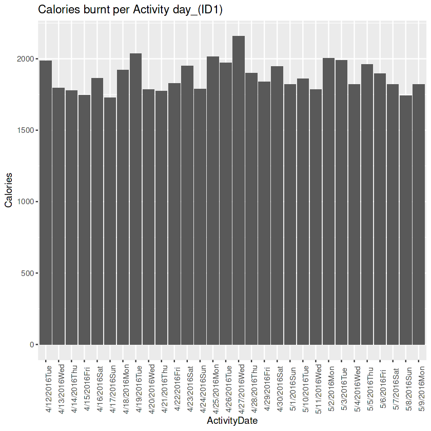

```r
ggplot(data=ID1) + geom_col(mapping = aes(x=ActivityDate, y=Calories)) + ggtitle("Calories burnt per Activity day_(ID1)") + theme(axis.text.x=element_text(angle=90))
```

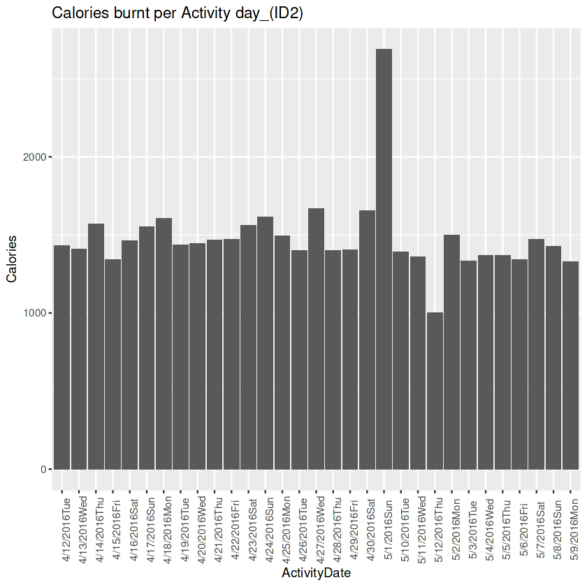

```r
ggplot(data=ID2) + geom_col(mapping = aes(x=ActivityDate, y=Calories)) + ggtitle("Calories burnt per Activity day_(ID2)") + theme(axis.text.x=element_text(angle=90))
```

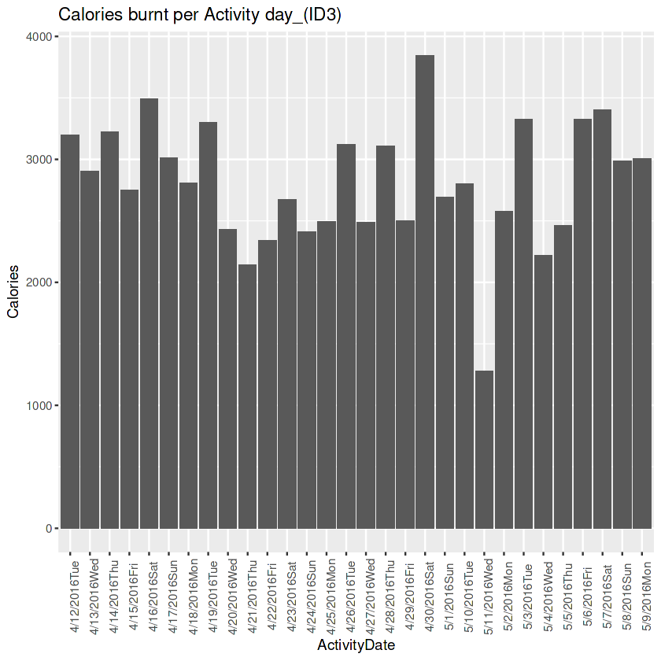

```r
ggplot(data=ID3) + geom_col(mapping = aes(x=ActivityDate, y=Calories)) + ggtitle("Calories burnt per Activity day_(ID3)") + theme(axis.text.x=element_text(angle=90))
```

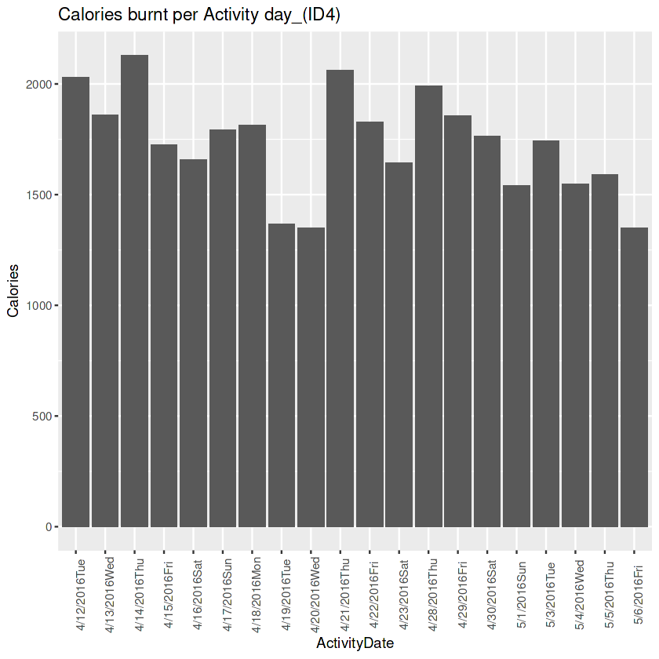

```r
ggplot(data=ID4) + geom_col(mapping = aes(x=ActivityDate, y=Calories)) + ggtitle("Calories burnt per Activity day_(ID4)") + theme(axis.text.x=element_text(angle=90))
```

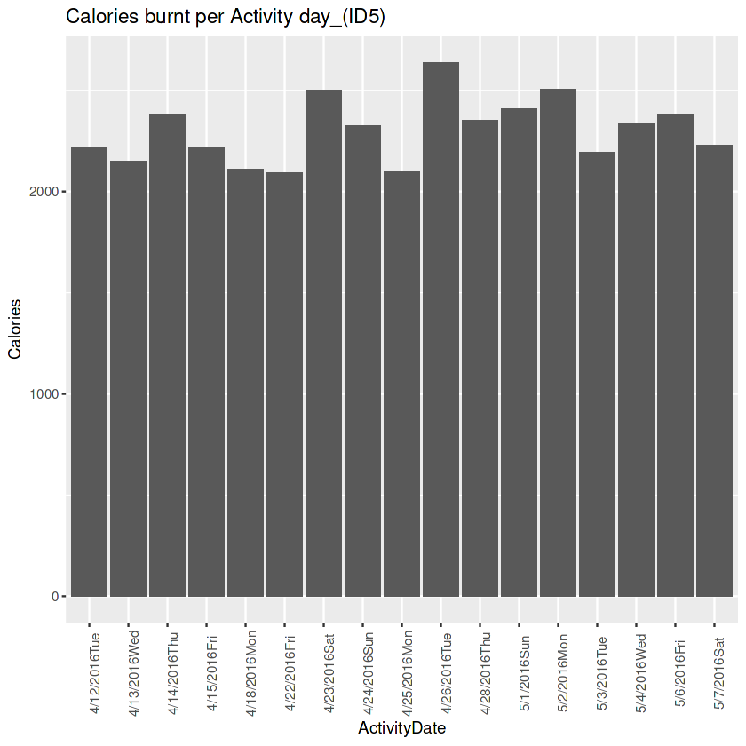

```r
ggplot(data=ID5) + geom_col(mapping = aes(x=ActivityDate, y=Calories)) + ggtitle("Calories burnt per Activity day_(ID5)") + theme(axis.text.x=element_text(angle=90))
```

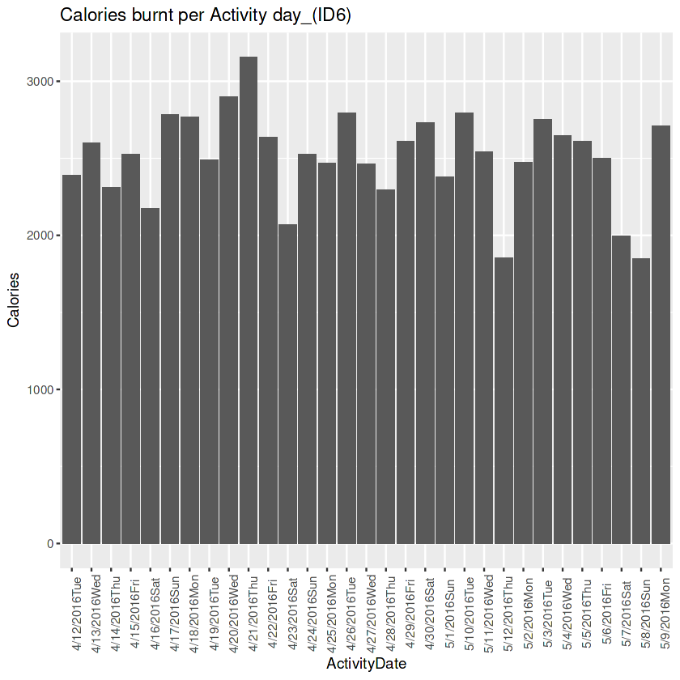

```r
ggplot(data=ID6) + geom_col(mapping = aes(x=ActivityDate, y=Calories)) + ggtitle("Calories burnt per Activity day_(ID6)") + theme(axis.text.x=element_text(angle=90))
```

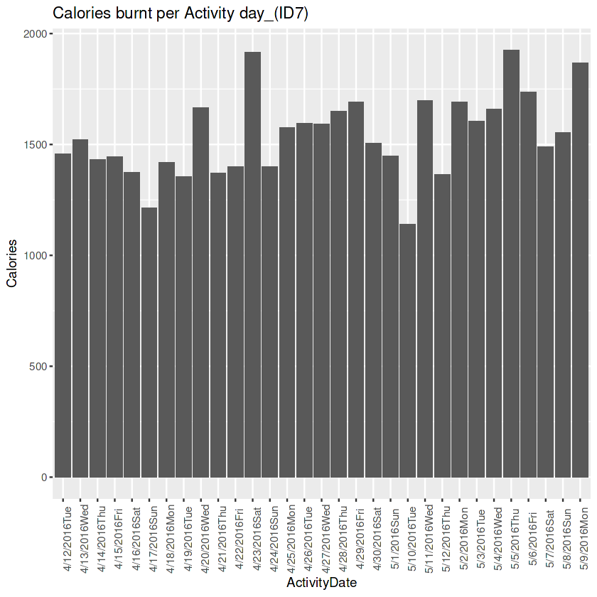

```r
ggplot(data=ID7) + geom_col(mapping = aes(x=ActivityDate, y=Calories)) + ggtitle("Calories burnt per Activity day_(ID7)") + theme(axis.text.x=element_text(angle=90))
```

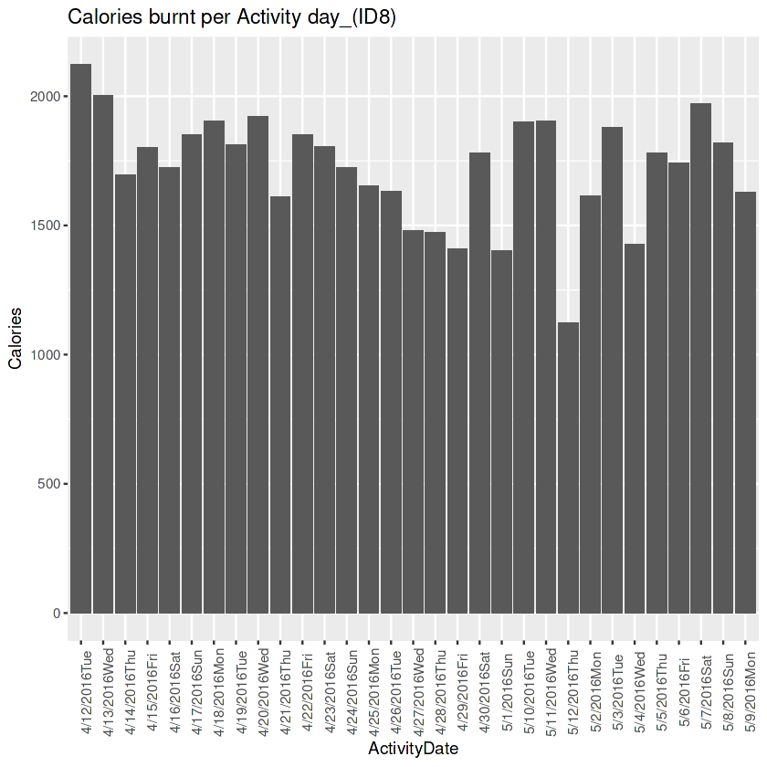

```r
ggplot(data=ID8) + geom_col(mapping = aes(x=ActivityDate, y=Calories)) + ggtitle("Calories burnt per Activity day_(ID8)") + theme(axis.text.x=element_text(angle=90))
```

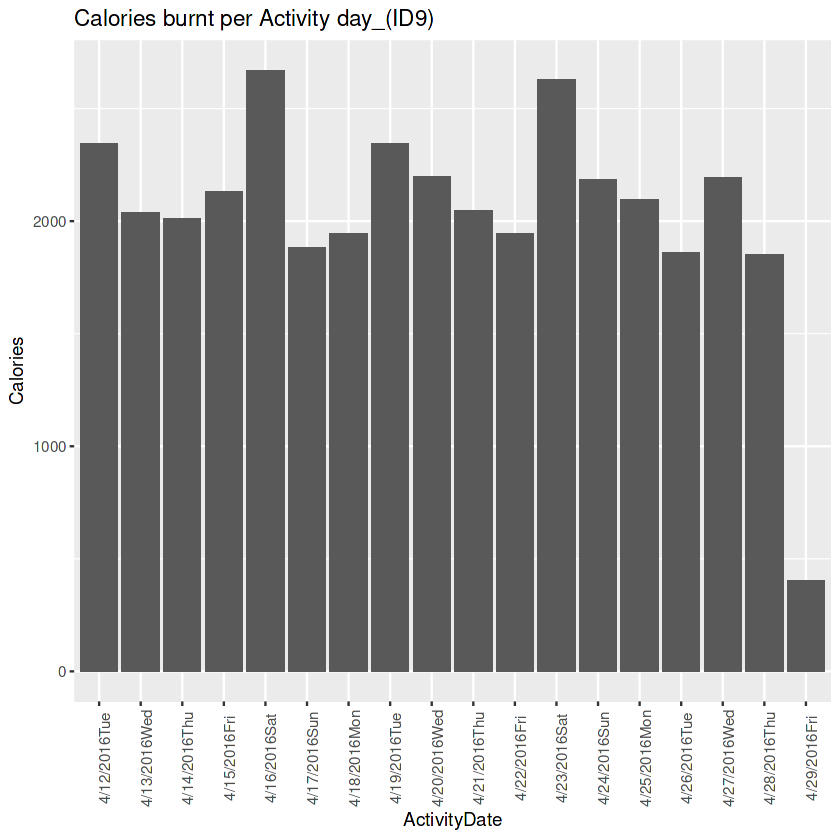

```r
ggplot(data=ID9) + geom_col(mapping = aes(x=ActivityDate, y=Calories)) + ggtitle("Calories burnt per Activity day_(ID9)") + theme(axis.text.x=element_text(angle=90))
```

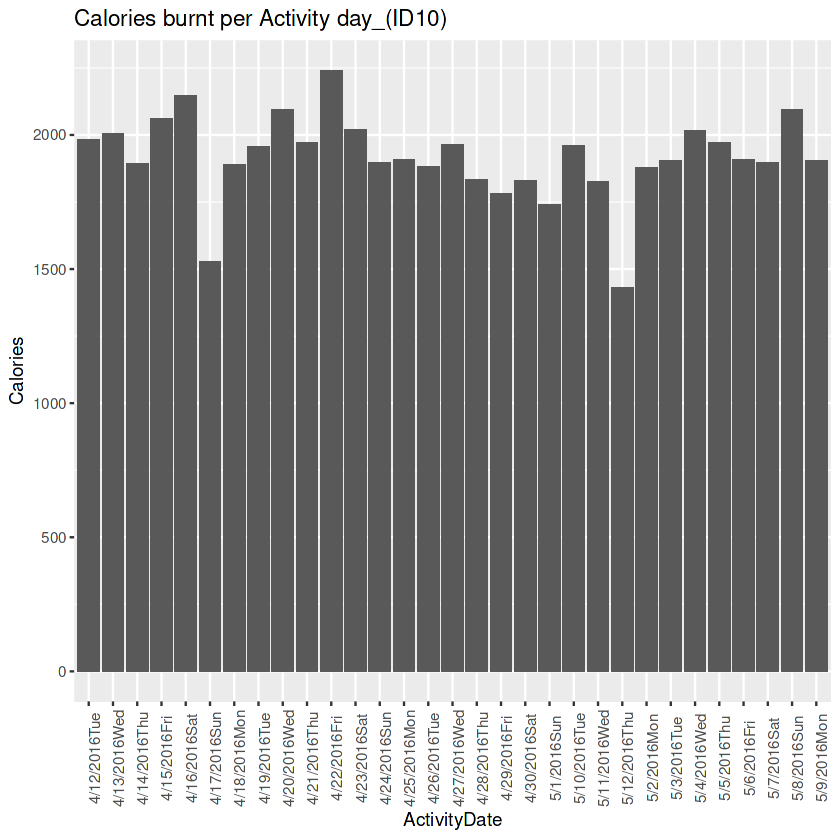

```r
ggplot(data=ID10) + geom_col(mapping = aes(x=ActivityDate, y=Calories)) + ggtitle("Calories burnt per Activity day_(ID10)") + theme(axis.text.x=element_text(angle=90))
```

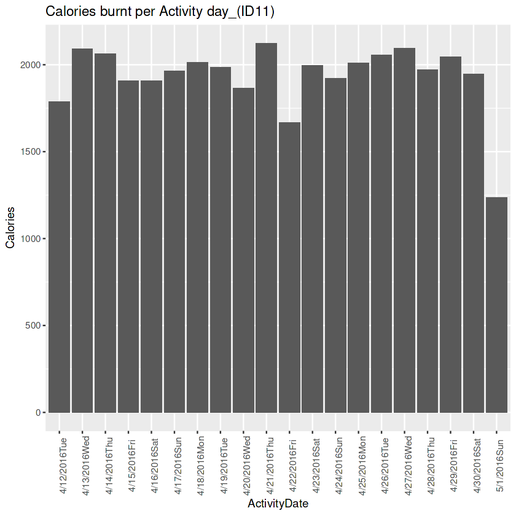

```r
ggplot(data=ID11) + geom_col(mapping = aes(x=ActivityDate, y=Calories)) + ggtitle("Calories burnt per Activity day_(ID11)") + theme(axis.text.x=element_text(angle=90))
```

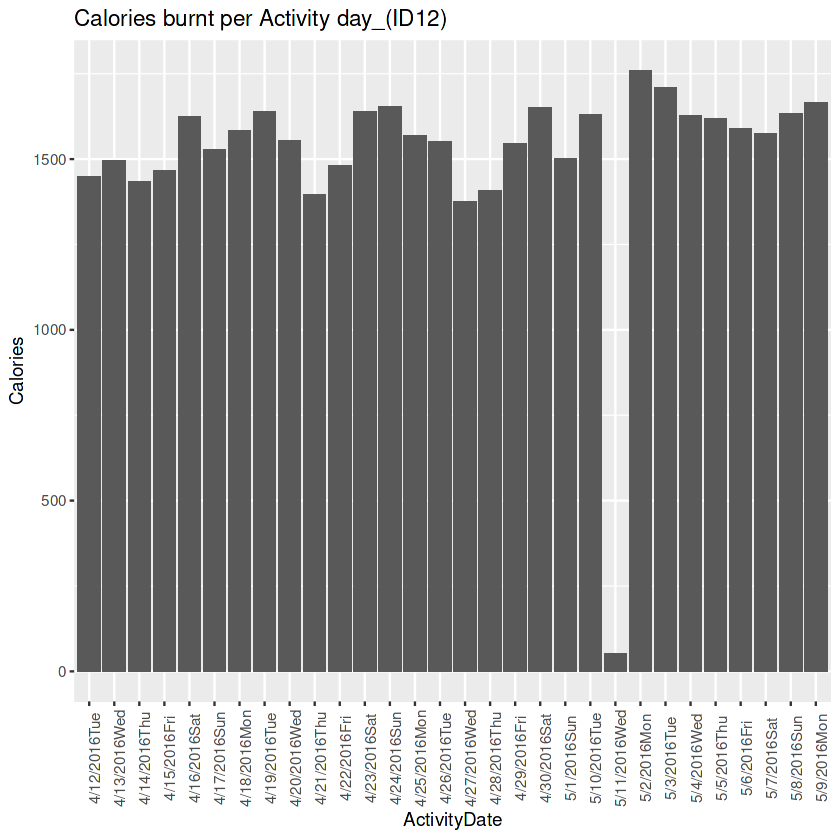

```r
ggplot(data=ID12) + geom_col(mapping = aes(x=ActivityDate, y=Calories)) + ggtitle("Calories burnt per Activity day_(ID12)") + theme(axis.text.x=element_text(angle=90))
```

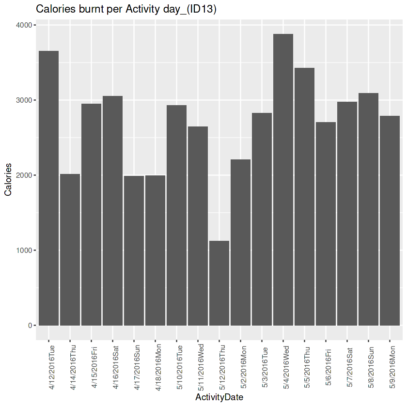

```r
ggplot(data=ID13) + geom_col(mapping = aes(x=ActivityDate, y=Calories)) + ggtitle("Calories burnt per Activity day_(ID13)") + theme(axis.text.x=element_text(angle=90))
```

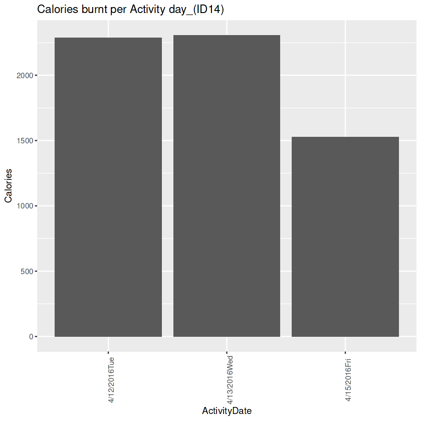

```r
ggplot(data=ID14) + geom_col(mapping = aes(x=ActivityDate, y=Calories)) + ggtitle("Calories burnt per Activity day_(ID14)") + theme(axis.text.x=element_text(angle=90))
```

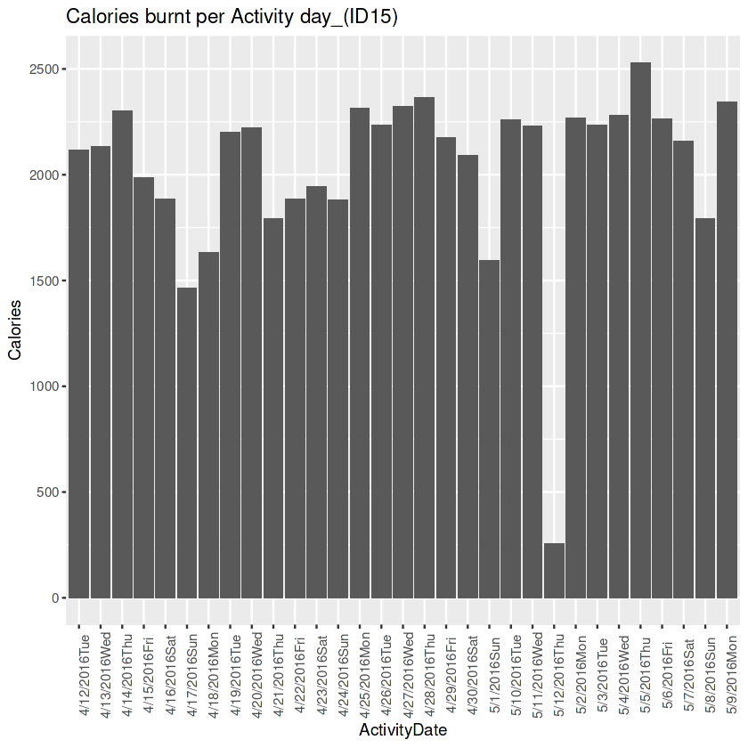

```r
ggplot(data=ID15) + geom_col(mapping = aes(x=ActivityDate, y=Calories)) + ggtitle("Calories burnt per Activity day_(ID15)") + theme(axis.text.x=element_text(angle=90))
```

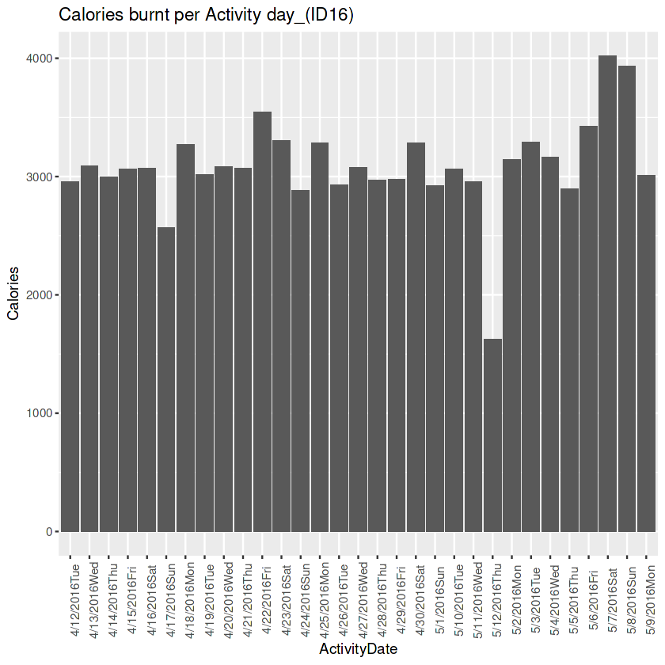

```r
ggplot(data=ID16) + geom_col(mapping = aes(x=ActivityDate, y=Calories)) + ggtitle("Calories burnt per Activity day_(ID16)") + theme(axis.text.x=element_text(angle=90))
```

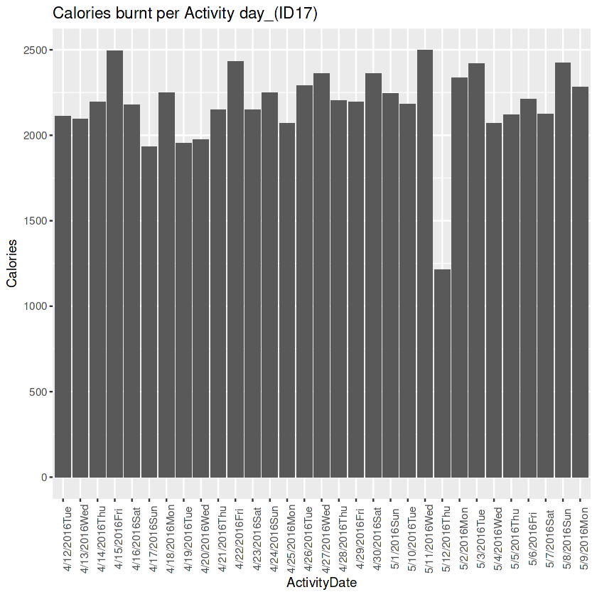

```r
ggplot(data=ID17) + geom_col(mapping = aes(x=ActivityDate, y=Calories)) + ggtitle("Calories burnt per Activity day_(ID17)") + theme(axis.text.x=element_text(angle=90))
```

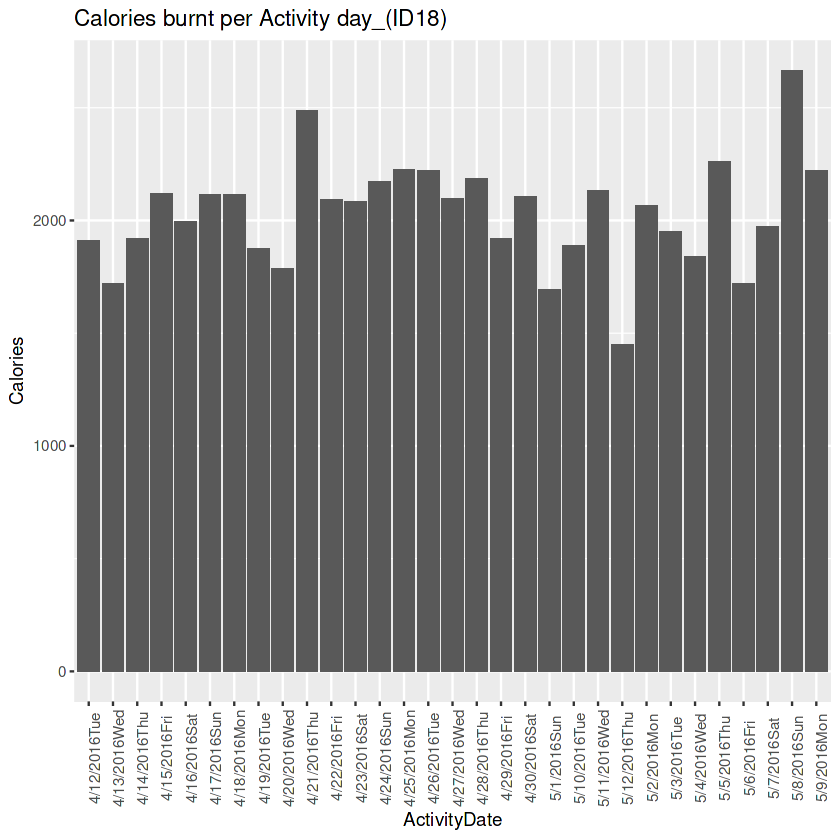

```r
ggplot(data=ID18) + geom_col(mapping = aes(x=ActivityDate, y=Calories)) + ggtitle("Calories burnt per Activity day_(ID18)") + theme(axis.text.x=element_text(angle=90))
```

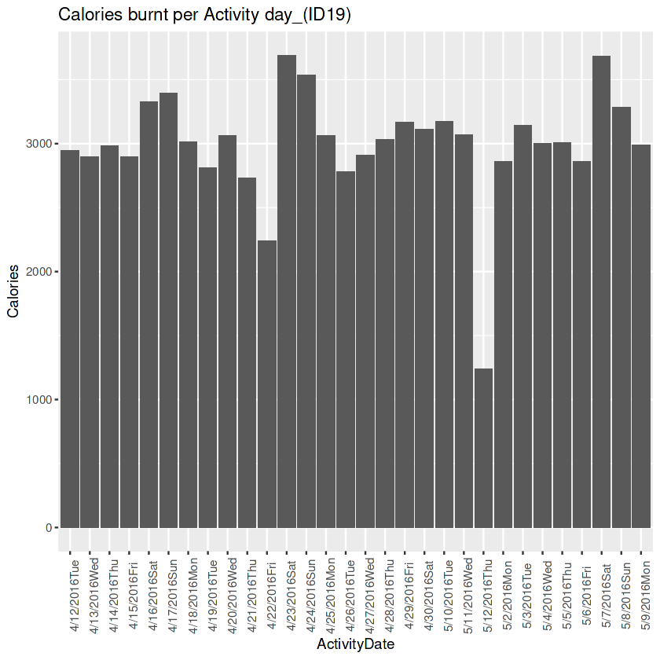

```r
ggplot(data=ID19) + geom_col(mapping = aes(x=ActivityDate, y=Calories)) + ggtitle("Calories burnt per Activity day_(ID19)") + theme(axis.text.x=element_text(angle=90))
```

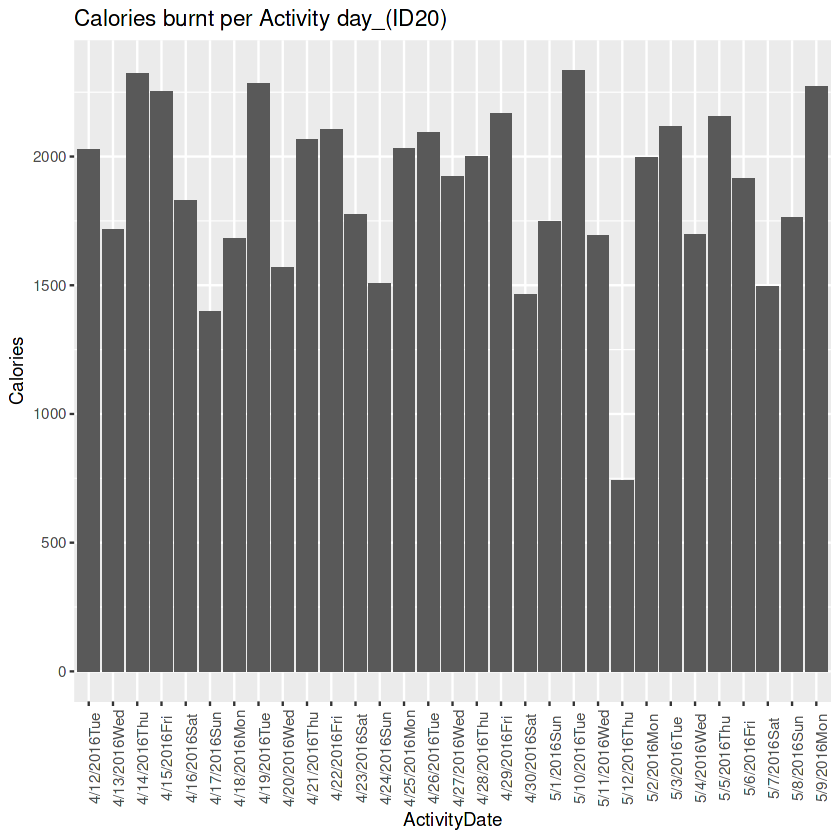

```r
ggplot(data=ID20) + geom_col(mapping = aes(x=ActivityDate, y=Calories)) + ggtitle("Calories burnt per Activity day_(ID20)") + theme(axis.text.x=element_text(angle=90))
```

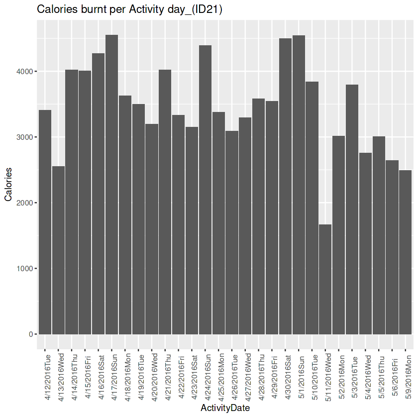

```r
ggplot(data=ID21) + geom_col(mapping = aes(x=ActivityDate, y=Calories)) + ggtitle("Calories burnt per Activity day_(ID21)") + theme(axis.text.x=element_text(angle=90))
```

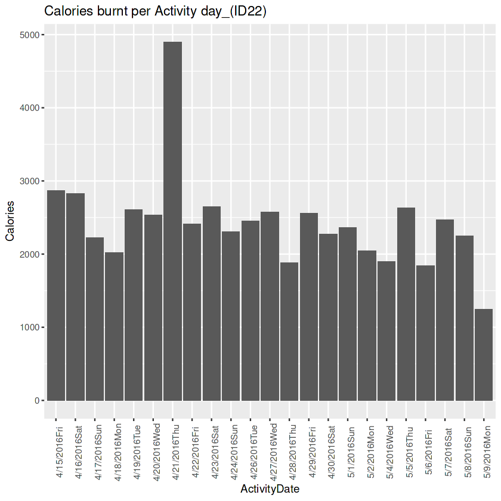

```r
ggplot(data=ID22) + geom_col(mapping = aes(x=ActivityDate, y=Calories)) + ggtitle("Calories burnt per Activity day_(ID22)") + theme(axis.text.x=element_text(angle=90))
```

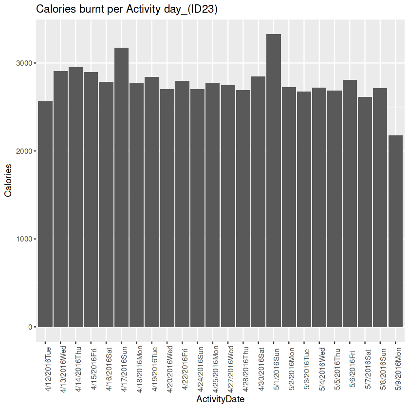

```r
ggplot(data=ID23) + geom_col(mapping = aes(x=ActivityDate, y=Calories)) + ggtitle("Calories burnt per Activity day_(ID23)") + theme(axis.text.x=element_text(angle=90))
```

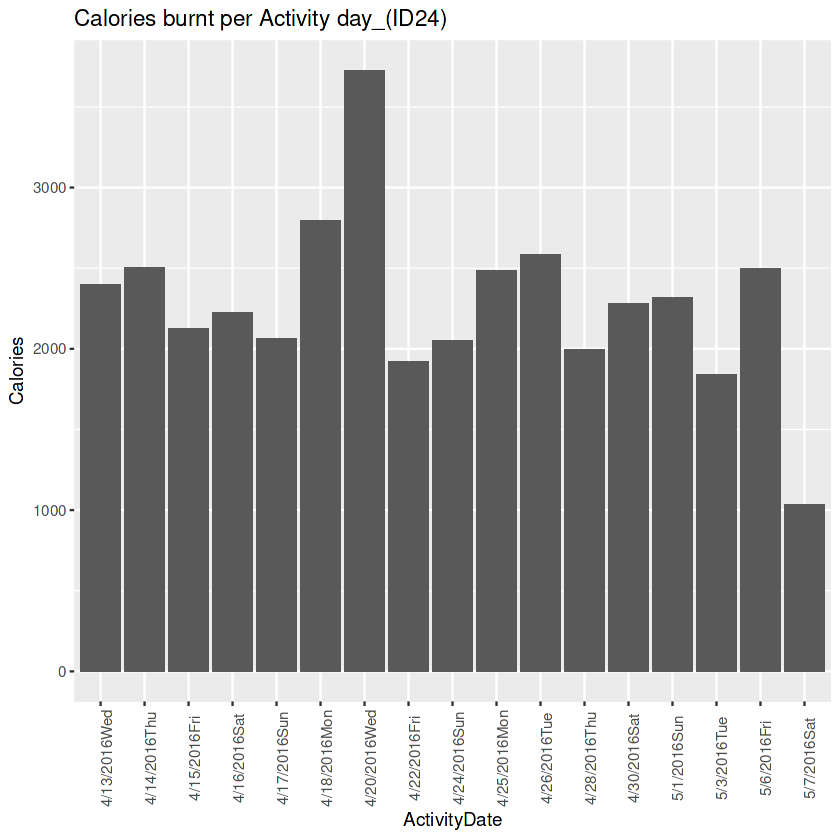

```r
ggplot(data=ID24) + geom_col(mapping = aes(x=ActivityDate, y=Calories)) + ggtitle("Calories burnt per Activity day_(ID24)") + theme(axis.text.x=element_text(angle=90))
```

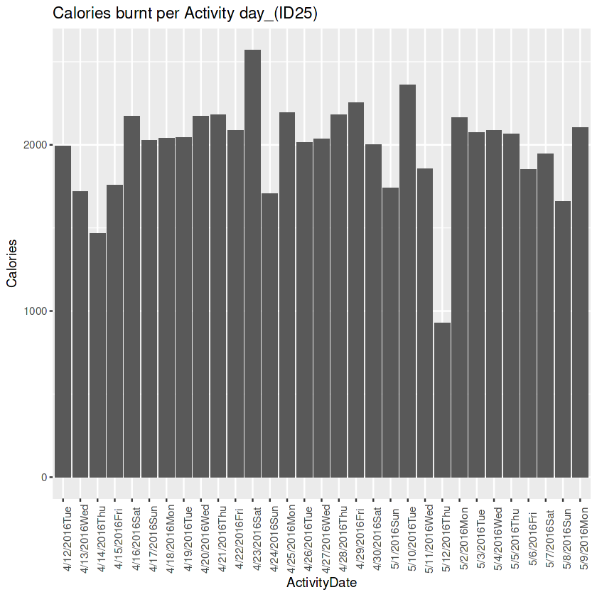

```r
ggplot(data=ID25) + geom_col(mapping = aes(x=ActivityDate, y=Calories)) + ggtitle("Calories burnt per Activity day_(ID25)") + theme(axis.text.x=element_text(angle=90))
```

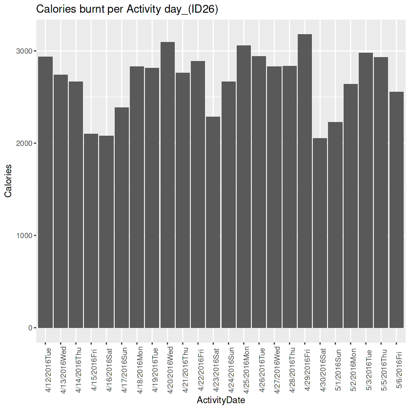

```r
ggplot(data=ID26) + geom_col(mapping = aes(x=ActivityDate, y=Calories)) + ggtitle("Calories burnt per Activity day_(ID26)") + theme(axis.text.x=element_text(angle=90))
```

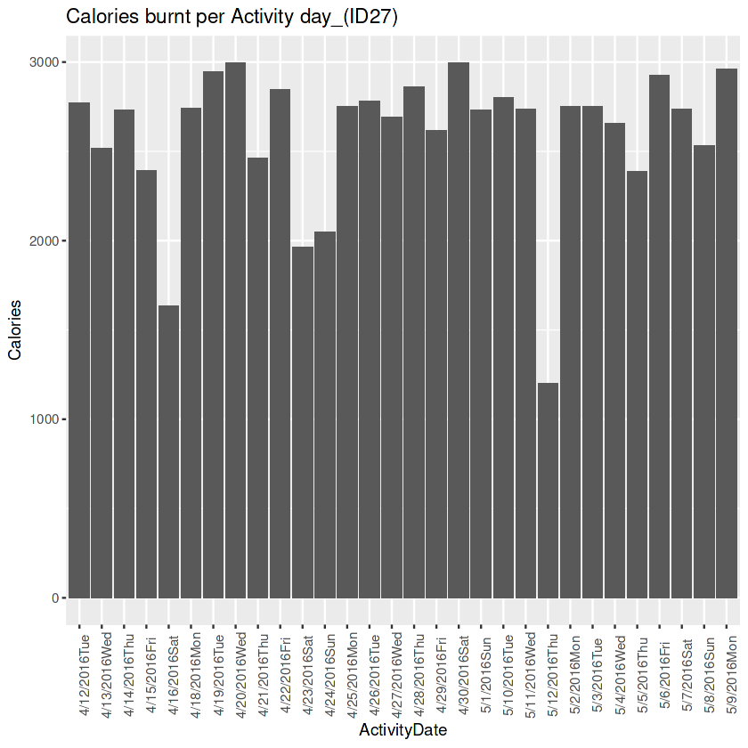

```r
ggplot(data=ID27) + geom_col(mapping = aes(x=ActivityDate, y=Calories)) + ggtitle("Calories burnt per Activity day_(ID27)") + theme(axis.text.x=element_text(angle=90))
```

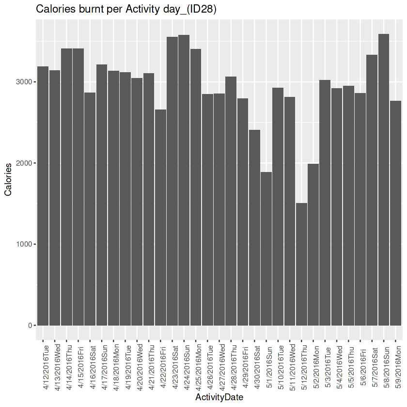

```r
ggplot(data=ID28) + geom_col(mapping = aes(x=ActivityDate, y=Calories)) + ggtitle("Calories burnt per Activity day_(ID28)") + theme(axis.text.x=element_text(angle=90))
```

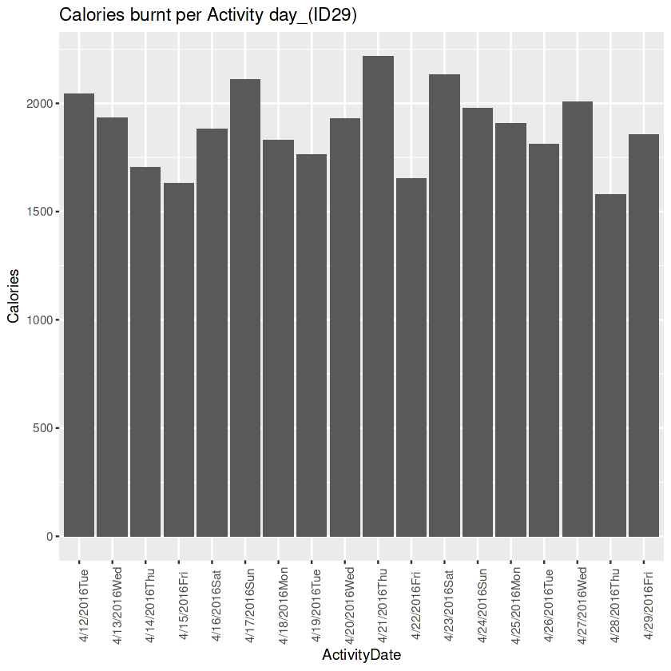

```r
ggplot(data=ID29) + geom_col(mapping = aes(x=ActivityDate, y=Calories)) + ggtitle("Calories burnt per Activity day_(ID29)") + theme(axis.text.x=element_text(angle=90))
```